# Ch. 4 Conservation Laws — fluidpy

← All chapters🎮 All explainers

← PreviousNext →

[▶ Open in Colab](https://colab.research.google.com/github/shammun/fluidpy/blob/main/notebooks/ch04_conservation_laws_colab.ipynb) ↓ Download .ipynb [View on GitHub](https://github.com/shammun/fluidpy/blob/main/notebooks/ch04_conservation_laws.ipynb)

## Interactive explainers in this chapter

🎮 1**Weigh a force by counting what flows through a box**One control volume drawn on a real scene (a wake, a bore, a jet, a rocket, an expanding gas) with every face's mass and momentum flux as a bar: storage plus outflow equals the forces, and the residual stays at zero.🎮 2**Can one number field hold a whole 2-D flow?**Seven classic flows drawn as ψ contours at equal steps over a speed map with tracers; drag a gate and its flux stays ψ₂ − ψ₁ however you bend it; click to read u = ∂ψ/∂y, v = −∂ψ/∂x.🎮 3**How does a fluid decide its stress?**Set a velocity gradient and watch G split into S and R, the Newtonian law turn S into tau, and the traction on a plane you rotate swing through its normal and shear values; a second mode shrinks a cube with unequal shear stresses and watches it spin up.🎮 4**Which terms of Navier–Stokes are awake here?**Pick an exact solution, click any point and read the five terms of the incompressible Navier–Stokes equation as bars that add to zero; scrub time and watch the balance move between local-vs-viscous and advective-vs-pressure.🎮 5**Why does a straight throw curve on a merry-go-round?**One ball, one clock, two observers: the inertial view shows a straight path over a turning table, the rotating view a curve bent by the Coriolis force, with every apparent force of the noninertial Navier–Stokes equation as an arrow and a bar.🎮 6**Bernoulli is constant along what, exactly?**Six flows, each with its streamlines and two probes; the Bernoulli sum is plotted along and across streamlines with stacked term bars, and the hypotheses you toggle pick which of the Bernoulli equations applies.🎮 7**Where does the energy go when viscosity stops a flow?**A sheared gap on one clock: the velocity profile, the dissipation where the shear is, the temperature rising to its steady parabola, and energy bars showing the wall's work arriving as heat, with a negative-viscosity preset that breaks the second law.🎮 8**Density hardly changes — so why does it drive the flow?**Choose a fluid, a temperature contrast and a depth: the small numbers of the Boussinesq approximation are checked against their thresholds while a warm blob rises and spreads under the terms Boussinesq keeps; switch buoyancy off and the blob only diffuses.🎮 9**When does a model behave like the real thing?**A prototype and its model drawn in their own units side by side, the dimensionless groups as paired bars with matched badges, and the consequences: spheres of every size and fluid on one C_D(Re) curve, a ship's drag split and scaled, a lab tank standing in for the atmosphere.

# Chapter 4 — Conservation Laws

*Fluid Mechanics, 5th edition — Pijush K. Kundu, Ira M. Cohen, David R. Dowling (2012).* This notebook teaches every new idea of the chapter with plain words, step-by-step mathematics, small worked examples, tested Python from the `fluidpy` package, figures, animations and interactive explainers. It does not reproduce the book's text or figures; equations are cited by their numbers so you can follow along in your copy.

**The big idea in one paragraph**

Every flow obeys three bookkeeping rules: mass is neither made nor lost, momentum changes only when a force acts (Newton), and energy is conserved (the first law). Written for a fixed set of fluid particles and carried to any control volume by the Reynolds transport theorem, they become integral budgets that give forces from fluxes; shrunk to a point, they become the continuity equation $\frac{\partial\rho}{\partial t}+\nabla\cdot(\rho\mathbf u)=0$ *(Eq. 4.7)*, Cauchy's equation $\rho\frac{Du_j}{Dt}=\rho g_j+\frac{\partial\tau_{ij}}{\partial x_i}$ *(Eq. 4.24)* and the energy equation. A Newtonian stress law turns Cauchy's equation into Navier–Stokes, $\rho\frac{D\mathbf u}{Dt}=-\nabla p+\rho\mathbf g+\mu\nabla^2\mathbf u$ *(Eq. 4.39b)* — the equation of the rest of the book. The chapter then shows what a rotating observer adds (Coriolis), how viscosity turns motion into heat, when Bernoulli's equation holds, why the ocean and atmosphere can ignore density except where it meets gravity (Boussinesq), what happens at the edges of a flow, and which dimensionless numbers decide whether two flows are the same flow.

**Road map** — the new ideas of this chapter, in the order they build on each other:

1. §4.1 integral vs differential laws; counting equations and unknowns
2. §4.2 mass: a moving control volume, $\frac{d}{dt}\int_{V^*}\rho\,dV+\int_{A^*}\rho(\mathbf u-\mathbf b)\cdot\mathbf n\,dA=0$ *(4.5)* (C01), and the continuity equation $\frac{\partial\rho}{\partial t}+\nabla\cdot(\rho\mathbf u)=0$ *(4.7)* (C02)
3. §4.3 stream functions: one scalar carries a 2-D flow (C03)
4. §4.4 momentum: forces from fluxes (4.17), $\frac{d}{dt}\int_{V^*}\rho\mathbf u\,dV+\int_{A^*}\rho\mathbf u(\mathbf u-\mathbf b)\cdot\mathbf n\,dA=\int_{V^*}\rho\mathbf g\,dV+\int_{A^*}\mathbf f\,dA$ (C04), Bernoulli along a streamline $\tfrac12U^2+gz+p/\rho=$ const *(4.19)* (C05), Cauchy's equation *(4.24)* (C06)
5. §4.5 the Newtonian stress law $\tau_{ij}=-p\delta_{ij}+2\mu S_{ij}+\lambda S_{mm}\delta_{ij}$ *(4.31)* (C07)
6. §4.6 Navier–Stokes $\rho\frac{D\mathbf u}{Dt}=-\nabla p+\rho\mathbf g+\mu\nabla^2\mathbf u$ *(4.39b)* (C08)
7. §4.7 a rotating, accelerating observer: Coriolis and centrifugal terms (4.45), $\rho\frac{D'\mathbf u'}{Dt}=-\nabla'p+\rho\Big[\mathbf g-\frac{d\mathbf U}{dt}-2\boldsymbol\Omega\times\mathbf u'-\frac{d\boldsymbol\Omega}{dt}\times\mathbf x'-\boldsymbol\Omega\times(\boldsymbol\Omega\times\mathbf x')\Big]+\mu\nabla'^2\mathbf u'$ (C09)
8. §4.8 energy: dissipation $\varepsilon\ge0$ turns kinetic energy into heat (4.57), $\frac{De}{Dt}=-p\frac{Dv}{Dt}+\frac1\rho\sigma_{ij}S_{ij}-\frac1\rho\frac{\partial q_i}{\partial x_i}$, (4.58), $\varepsilon\equiv\frac1\rho\sigma_{ij}S_{ij}=2\nu\big(S_{ij}-\tfrac13S_{mm}\delta_{ij}\big)^2+\frac{\mu_v}{\rho}S_{mm}^2\ge0$ (C10)
9. §4.9 Bernoulli's forms (C11, C12) and the Boussinesq approximation (C13)
10. §4.10 boundary and interface conditions, the kinematic condition $D\eta/Dt=0$ *(4.91)* (C14)
11. §4.11 dimensionless Navier–Stokes (4.101), $\Big[\frac{\Omega l}{U}\Big]\frac{\partial\mathbf u^*}{\partial t^*}+(\mathbf u^*\cdot\nabla^*)\mathbf u^*=-\nabla^*p^*+\Big[\frac{gl}{U^2}\Big]\mathbf g^*+\Big[\frac{\mu}{\rho Ul}\Big]\nabla^{*2}\mathbf u^*$ and dynamic similarity (C15)

**What you should already know** (each is recapped where it is used):

- the Reynolds transport theorem and material volumes (Ch. 3 §3.6)
- the material derivative $\frac{DF}{Dt}=\frac{\partial F}{\partial t}+\mathbf u\cdot\nabla F$ (Ch. 3 §3.2)
- strain rate S, vorticity ω and ∇·u as the volume growth rate (Ch. 3 §3.4)
- stress tensor, Cauchy traction $f_j=n_i\tau_{ij}$, Gauss' theorem, the ε–δ identity (Ch. 2)
- Newton's viscosity law, Fourier's law, hydrostatics, first law and Gibbs relation, N², Π groups (Ch. 1)

## 🎮 Interactive explainers in this chapter

| # | Explainer | What it makes clear |
| --- | --- | --- |
| 1 | **Weigh a force by counting what flows through a box** | C01 C04: the moving-CV mass and momentum budgets — wake drag, bore, jet, rocket |
| 2 | **Can one number field hold a whole 2-D flow?** | C03: ψ contours are streamlines, their spacing is the speed, Δψ is the flux |
| 3 | **How does a fluid decide its stress?** | C07: G → S → τ, traction on a plane, bulk viscosity, the spinning cube |
| 4 | **Which terms of Navier–Stokes are awake here?** | C08: the five terms of incompressible Navier–Stokes at a probe for six exact solutions |
| 5 | **Why does a straight throw curve on a merry-go-round?** | C09: the rotating-frame terms, Coriolis deflection Ωut², effective gravity |
| 6 | **Bernoulli is constant along what, exactly?** | C05 C11 C12: the four Bernoulli equations and their hypotheses |
| 7 | **Where does the energy go when viscosity stops a flow?** | C10: dissipation ε ≥ 0, heating of a sheared channel, entropy production |
| 8 | **Density hardly changes — so why does it drive the flow?** | C13: the Boussinesq momentum and heat equations and when they hold |
| 9 | **When does a model behave like the real thing?** | C15: dimensionless Navier–Stokes, Re, Fr, St and model testing |

Each one opens right where its idea is taught and fills the window (no scrolling). Start with the **Walkthrough**, then **Explore** with the sliders and presets, read **Explain** (every number worked out with your settings, and what it means), step through the **Derivation** where there is one, read the **Equations** and the **Code**, and finish with **Check yourself**. On the web page they are full-window; in Colab and Jupyter they appear in the cell output (use ⤢ *Full screen* or *Open in new tab* for more room).

## ⚙️ Setup — run this cell first

It works in three places without changes:

- **Google Colab** — clones the public repository into `/content/fluidpy` (the `fluidpy` package, its tests and the interactive explainers) and installs the one package Colab lacks (`pint`). No GPU is needed.
- **Jupyter / VS Code on your computer** — finds the repository root (the folder with `book.yaml`) and imports from it.
- **The published web page** — already executed; nothing to run.

```python
# ── Setup: find (or fetch) the fluidpy repository, then load the house style ─────────────────────────────
import os, sys, subprocess, pathlib                     # standard library only, so this cell never fails on imports

IN_COLAB = "google.colab" in sys.modules                 # True when this notebook runs inside Google Colab
REPO_URL = "https://github.com/shammun/fluidpy.git"               # the public repository with the fluidpy package

if IN_COLAB:
    ROOT = pathlib.Path("/content/fluidpy")              # where the repository is cloned on Colab
    if not ROOT.exists():                                 # first run in this Colab session: clone it
        subprocess.run(["git", "clone", "--depth", "1", REPO_URL, str(ROOT)], check=True)
    else:                                                 # later runs: fetch the newest version
        subprocess.run(["git", "-C", str(ROOT), "pull", "--ff-only", "-q"], check=False)
    subprocess.run([sys.executable, "-m", "pip", "install", "-q", "-r", str(ROOT / "requirements-colab.txt")], check=True)
else:
    ROOT = pathlib.Path.cwd().resolve()                   # start where Jupyter was launched …
    while not (ROOT / "book.yaml").exists() and ROOT != ROOT.parent:
        ROOT = ROOT.parent                                # … and walk up until we find the repository root

os.chdir(ROOT)                                            # relative paths (outputs/, viz/) now resolve from the root
if str(ROOT) not in sys.path:
    sys.path.insert(0, str(ROOT))                         # make `import fluidpy` work

from fluidpy.core.style import setup_notebook            # matplotlib + plotly style shared with the explainers
from fluidpy.core.embed import show_viz                  # shows an interactive explainer in the notebook
from fluidpy.core.anim import show_animation             # plays a matplotlib animation inline
FAST = setup_notebook()                                   # FAST=True (env FLUIDPY_FAST=1) shrinks grids for quick runs
print(f"IN_COLAB = {IN_COLAB} | repository root: {ROOT} | FAST = {FAST}")
```

```
IN_COLAB = False | repository root: C:\Users\sislam27\Work\Climate Dynamics PHD\Fluid Dynamics | FAST = False
```

```python
import numpy as np                                      # arrays (Ch. 1 primer P03)
import sympy as sp                                      # symbolic algebra (Ch. 1 primer P40)
import pandas as pd                                     # labelled tables (a DataFrame is a table with named rows/columns)
import matplotlib.pyplot as plt                         # static figures (Ch. 1 primer P01)
import plotly.graph_objects as go                       # rotatable 3-D figures (Ch. 1 P41, Ch. 2 P64)
from fluidpy import ch04_conservation_laws as ch04      # the tested chapter-4 module: every function cites its § and Eq.
from fluidpy import ch01_introduction as ch01           # Ch. 1 functions reused here (fluid properties, Newton's law, …)
from fluidpy import ch03_kinematics as ch03             # Ch. 3 functions reused as test fields (cylinder, vortices, paths)
from fluidpy.core.interact import slider_figure         # plotly figure with a slider that works on the web page (P17)
from fluidpy.core.anim import animate                   # matplotlib animations (P16); show_animation came with the setup
from fluidpy.core.style import COLORS, savefig          # the house palette and a helper that saves PNGs to outputs/ch04
from fluidpy.core import transport, grids, operators, tensors, kinematics, statics   # Ch. 2–3 machinery, called by module name
from fluidpy.core import integral_theorems as itg       # Ch. 2's Gauss and Stokes helpers
from tools.convergence import observed_order            # slope of log(error) vs log(step): the observed order (P13)
import logging                                          # standard library: controls library log messages
logging.getLogger("matplotlib.font_manager").setLevel(logging.ERROR)   # hide harmless font-substitution notes


def recolor(fig, colors, dashes=None):                  # give plotly slider traces the notebook's colours by trace name
    for tr in fig.data:                                 # every trace of every slider step
        if tr.name in colors:                           # a name we assigned a colour to
            tr.line.color = colors[tr.name]             # same colour meaning as in the matplotlib figures
            tr.marker.color = colors[tr.name]           # markers too (for "markers" traces)
        if dashes and tr.name in dashes:                # optional dash pattern ("dash", "dot")
            tr.line.dash = dashes[tr.name]
    return fig                                          # the same figure, restyled


print(len([n for n in dir(ch04) if not n.startswith("_")]), "public names in fluidpy.ch04_conservation_laws")   # the toolbox
```

```
262 public names in fluidpy.ch04_conservation_laws
```

**What does the code above do?**

1. Numerical, symbolic, table and plotting libraries (all primed in Ch. 1–2; `pandas` is used only for one small labelled table, the equation ledger below).
2. `ch04` is the chapter module; it re-exports the nine new core modules of this chapter (conservation budgets, stream functions, constitutive laws, Navier–Stokes residuals, rotating frames, curvilinear operators, Bernoulli, interfaces, similarity), so one name covers the whole chapter. Every function is tested in `tests/test_ch04.py`.
3. Ch. 1 and Ch. 3 functions are reused as test fields; the core modules of Ch. 2–3 are called by module name.
4. `recolor` only restyles plotly traces so that a colour always means the same thing.

**Notation, conventions and colours used in this notebook.**

| Symbol | Meaning | Unit |
| --- | --- | --- |
| $\rho$ | density | kg/m³ |
| $\mathbf u=(u,v,w)$ | velocity | m/s |
| $\mathbf b$ | velocity of a control surface (the walls of our box) | m/s |
| $V(t)$, $A(t)$ | a material volume (always the same particles) and its surface | m³, m² |
| $V^*(t)$, $A^*(t)$ | a control volume (a box we choose) and its surface | m³, m² |
| $\mathbf n$ | outward unit normal | – |
| $\mathbf g$ | body force per unit mass; $z$ up, $\mathbf g=-g\mathbf e_z$, $\Phi=gz$ | m/s² |
| $\tau_{ij}$ | stress; **first index = the face's normal**, second = force direction | Pa |
| $p$, $\sigma_{ij}$ | pressure; viscous stress | Pa |
| $S_{ij}$, $\boldsymbol\omega$ | strain rate; vorticity | 1/s |
| $\mu$, $\nu=\mu/\rho$, $\mu_v$ | dynamic, kinematic and bulk viscosity | Pa s, m²/s, Pa s |
| $e$, $h$ | internal energy, enthalpy per unit mass | J/kg |
| $\mathbf q$, $k$ | heat flux; thermal conductivity | W/m², W/(m K) |
| $\varepsilon$ | viscous dissipation rate | W/kg |
| $\boldsymbol\Omega$ | angular velocity of a rotating frame | rad/s |
| $\dot\gamma$, $s$ | shear rate, extension rate | 1/s |

> ⚠️ **Four primes.** $\mathbf x'$, $\mathbf u'$ in §4.7 are measured in the **rotating** frame; $p'$ inside $\int_{p_o}^{p}dp'/\rho(p')$ in §4.9 is only an **integration variable**; $p'$, $\rho'$ later in §4.9 are **departures from the hydrostatic state**; and Ch. 3's $\mathbf x'$ was a **translating** frame. The code never reuses one name: `u_rot`, `x_rot` (rotating frame), `p_pert`, `rho_pert` (perturbations).

> ⚠️ **Symbols reused.** σ is the viscous stress (§4.5), the surface tension (§4.10) and a vortex core radius (§4.9); ε is the dissipation (§4.8) and the alternating tensor $\varepsilon_{ijk}$; γ is a material coefficient in the stress law (§4.5), the ratio $C_p/C_v$ and a scaled height in Ex. 4.7 — so we write the shear rate as $\dot\gamma$ and an extension rate as $s$. Φ, Ψ, φ, Ω, h, H, M, R and f also carry two or more meanings; each second meaning gets a ⚠️ where it appears.

**Colours** (one meaning each, also in the explainers): mass or momentum **inflow blue**, **outflow orange**, **storage purple**, **force on the fluid rose** · in Navier–Stokes: local $\partial\mathbf u/\partial t$ **blue**, advective $(\mathbf u\cdot\nabla)\mathbf u$ **teal**, pressure **orange**, viscous **rose**, gravity **grey** · Coriolis **amber**, centrifugal **purple** · kinetic energy **teal**, heat and dissipation **rose** · in Bernoulli stacks ½u² **teal**, p/ρ **orange**, gz **blue**, ∂φ/∂t **amber** · references and ghosts **grey dashed**.

**Where this chapter is used later**

| Result here | Used in |
| --- | --- |
| continuity $\frac{\partial\rho}{\partial t}+\nabla\cdot(\rho\mathbf u)=0$ (4.7) | every flow of Ch. 5–16 |
| moving-box budgets (4.5), $\frac{d}{dt}\int_{V^*(t)}\rho\,dV+\int_{A^*(t)}\rho\,(\mathbf u-\mathbf b)\cdot\mathbf n\,dA=0$ and $\frac{d}{dt}\int_{V^*}\rho\mathbf u\,dV+\int_{A^*}\rho\mathbf u(\mathbf … | momentum integral (Ch. 9), layer budgets (Ch. 13), shocks (Ch. 15) |
| $\rho\frac{D\mathbf u}{Dt}=-\nabla p+\rho\mathbf g+\mu\nabla^2\mathbf u$ (4.39b) | Ch. 5–13 |
| the Coriolis force $-2\boldsymbol\Omega\times\mathbf u'$ of (4.45), $\rho\frac{D'\mathbf u'}{Dt}=-\nabla'p+\rho\Big[\mathbf g-\frac{d\mathbf U}{dt}-2\boldsymbol\Omega\times\mathbf u'-\frac{d\boldsymbo… | geostrophy, Ekman layers, Rossby waves (Ch. 13) |
| dissipation $\varepsilon$ (4.58) | turbulence (Ch. 12) |
| $\frac{\partial\phi}{\partial t}+\tfrac12\lvert\nabla\phi\rvert^2+\int\frac{dp}{\rho}+gz=$ const (4.75) | water waves (Ch. 7) |
| Boussinesq $\frac{D\mathbf u}{Dt}=-\frac1{\rho_0}\nabla p'+\frac{\rho'}{\rho_0}\mathbf g+\nu\nabla^2\mathbf u$ (4.86), $\frac{DT}{Dt}=\kappa\nabla^2T$ (4.89) | internal waves (Ch. 7), convection (Ch. 11), ocean and atmosphere (Ch. 13) |
| $D\eta/Dt=0$ on a surface (4.91), $\frac{\partial\eta}{\partial t}+(\mathbf u\cdot\nabla)\eta\equiv\frac{D\eta}{Dt}=0\ \text{on}\ \eta=0$ | every free surface |
| Re, Fr, Ri, Ro | the regime maps of every later chapter |

*Climate hook:* the equations of an ocean or atmosphere model are continuity (4.7), Navier–Stokes in a rotating frame (4.45) with the Boussinesq simplification (4.86), and the heat equation (4.89) — this chapter writes each one down and says when it holds.

## 4.1 Introduction

**What is this section about?** The chapter's plan in two sentences: the same three principles (mass, momentum, energy) are written twice — once as a budget for a finite volume (integral form) and once at a single point (differential form) — and we keep a running count of equations against unknowns until the count closes.

📝 **Note.** **Integral vs differential form** `N01` — An *integral* law is a budget for a finite region — what is inside, what flows through its surface, what forces act on it. A *differential* law is the same statement at one point, a field equation. Gauss' theorem plus "true for every volume" turns the first into the second (C02 does it for mass). Integral forms return in Ch. 9 (momentum integral), Ch. 13 (layer budgets) and Ch. 15 (shock control volumes). *(N01 belongs to C01.)*

**The equation ledger (`N02`, filled in at C06, C08 and C10).** A set of equations can determine a flow only if there are as many independent equations as unknown fields. We count as we go, starting from an empty table.

```python
stages = ["cauchy", "navier_stokes", "barotropic", "full"]            # the four stages at which we will count
ledger = pd.DataFrame(0, index=stages, columns=["equations", "unknowns"])   # a labelled table of zeros
empty = ch04.closure_count("empty")                                   # the skeleton: nothing derived yet
print(empty["equations"], empty["unknowns"])                          # 0 0
print(ledger)                                                         # one row per stage, all zeros for now
```

```
0 0
               equations  unknowns
cauchy                 0         0
navier_stokes          0         0
barotropic             0         0
full                   0         0
```

**What does the code above do?**

1. `pd.DataFrame(0, index=…, columns=…)` builds a small table of zeros with named rows (the stages) and columns.
2. `ch04.closure_count("empty")` is the skeleton; the same call with a stage name fills a row after C06, C08 and C10 — the table closes (7 equations = 7 unknowns) at C10.

## 4.2 Conservation of Mass

**What is this section about?** Mass can be neither created nor destroyed. Written for a sealed bag of fluid that moves with the flow, this is one line; the work is to rewrite it for any box we choose (moving, deforming or fixed) and then for a single point.

> 🔁 **Tools from earlier chapters used here** (see `knowledge/primers.md`)
- **functions as arguments and lambda** — `lambda x, t: …` is a one-line function; fluidpy takes fields as functions of (x, t) (Ch. 1 P29).
- **f-strings** — `f"{x:+.3f}"` prints a number with a sign and 3 decimals (Ch. 1 P04).
- **assert np.allclose** — `assert np.allclose(a, b)` stops the notebook if two results differ beyond rounding (Ch. 1 P15).
- **path lines by solve_ivp** — `ch03.pathline(u, r0, t0, t_eval)` integrates $d\mathbf r/dt=\mathbf u(\mathbf r,t)$ with `solve_ivp` (Ch. 3 P94).
- **definite integral and np.trapezoid** — `np.trapezoid(y, x)` adds trapezoids under sampled values — a definite integral (Ch. 1 P27, P37).
- **central finite differences in time** — $(F(t+\Delta t)-F(t-\Delta t))/2\Delta t$ approximates $dF/dt$ with error ∝ Δt² (Ch. 1 P21).
- **volume and surface integrals as midpoint sums** — a volume or surface integral is a sum of value × small volume (or area) over cells (Ch. 2 P83).
- **animate and show_animation** — `animate(update, frames, fig)` builds a movie from an update function; `show_animation` plays it (Ch. 1 P16).
- **matplotlib figures** — `fig, ax = plt.subplots()`, `ax.plot`, labels with units (Ch. 1 P01).
- **numpy arrays** — vectors and tables of numbers that do arithmetic element by element (Ch. 1 P03).

> 🔁 **Recap — Material volume and material surface** (Ch. 3 §3.6). A *material volume* V(t) always contains the same fluid particles; its surface A(t) moves with the local fluid velocity, so in the Reynolds transport theorem its surface velocity is b = u. Picture a perfectly sealed, infinitely flexible balloon: it drifts, stretches and twists, but nothing crosses its skin. The theorem we use, $\frac{d}{dt}\int_{V^*(t)}F\,dV=\int_{V^*(t)}\frac{\partial F}{\partial t}dV+\int_{A^*(t)}F\,\mathbf b\cdot\mathbf n\,dA$ *(Eq. 3.35)*, holds for any control volume; for the balloon, b = u.

```python
u = lambda x, t: ch04.expanding_flow(x, t, a=1.0)[0]                 # 1-D test flow u = ax/(1 + at), a = 1 1/s [m/s]
ends = [ch03.pathline(u, [X], 0.0, [0.0, 1.0])[0, -1] for X in (1.0, 2.0)]   # follow the particles starting at 1 m and 2 m
print(np.round(ends, 8))                                            # [2. 4.]: after 1 s they sit at 2 m and 4 m
```

```
[2. 4.]
```

**What does the code above do?**

Two particles that start at x = 1 m and x = 2 m end at 2 m and 4 m after 1 s: the material interval between them (our 1-D balloon) stretches by the factor 1 + at.

### 🧩 Mass in a box that moves the way you choose (4.5) `C01`

*The question:* A sealed balloon of air drifts and swells, so its mass never changes. A fixed box sits where the balloon passes. What does the box record — and what would a box that slides along at its own speed record?

*In one line:* $\frac{d}{dt}\int_{V^*(t)}\rho\,dV+\int_{A^*(t)}\rho\,(\mathbf u-\mathbf b)\cdot\mathbf n\,dA=0$ *(4.5)*

#### The problem in plain words

Engineers rarely follow a particular lump of fluid: they draw a box round a pump, a wing or a river reach and count what enters and leaves. Meteorologists do the same with a grid cell, and oceanographers with a layer between two density surfaces that moves up and down. We need one mass-conservation statement that works for *any* box — fixed, sliding, stretching or riding with the fluid — and that reduces to "the balloon keeps its mass" when the box *is* the balloon.

#### The idea

```
material volume V(t)            control volume V*(t)                what the box sees
moves with the fluid (b = u)    moves as you choose (b = anything)   d/dt(mass inside) = −(net mass flux through
mass fixed: d/dt ∫ρ dV = 0      mass can change                                           its walls, RELATIVE to them)
                   the trick:  make V* and V coincide at one instant  →  (4.5)
```

*The numbered equations in the sketch:* $\frac{d}{dt}\int_{V^*(t)}\rho\,dV+\int_{A^*(t)}\rho\,(\mathbf u-\mathbf b)\cdot\mathbf n\,dA=0$ *(4.5)*

The flux through a wall depends on how fast the fluid moves **relative to the wall**, $\mathbf u-\mathbf b$: a wall that moves with the fluid lets nothing through, however fast both go.

> 📎 **Primer — dataclasses and named results.** `P111` · A `dataclass` is a small Python class whose only job is to hold named fields; fluidpy returns every budget this way, so you write `budget.residual` instead of remembering that the residual is the fourth number. `@dataclass(frozen=True)` makes the result read-only (a result should not be edited by accident).

```python
from dataclasses import dataclass                     # the decorator that builds the class
@dataclass(frozen=True)
class Budget:                                         # three named numbers
    storage: float; outflux: float; residual: float
b = Budget(storage=-1.0, outflux=1.0, residual=0.0)   # build one
print(b.residual, b)                                  # 0.0 Budget(storage=-1.0, outflux=1.0, residual=0.0)
```

```
0.0 Budget(storage=-1.0, outflux=1.0, residual=0.0)
```

📝 **Note.** **Mass of a material volume is constant** `N03` — our starting line. Number with our test flow $u=ax/(1+at)$, $\rho=\rho_0/(1+at)$ ($a$ = 1 s⁻¹, $\rho_0$ = 1 kg/m³, a 1-D flow, mass per unit cross-section area): the particles that occupy [1, 2] m at t = 0 occupy [2, 4] m at t = 1 s, where ρ = 0.5 kg/m³ — mass 1 × 1 = 0.5 × 2 = 1 kg/m² both times.

$$ \frac{d}{dt}\int_{V(t)}\rho(\mathbf x,t)\,dV=0 \qquad \text{(4.1)} $$

> 🔁 **Tools from earlier chapters used here** (see `knowledge/primers.md`) — needed in the derivation below
- **signed b·n and the swept volume of a moving wall** — a wall moving at $\mathbf b$ sweeps volume at the rate $\mathbf b\cdot\mathbf n\,dA$ — positive when it moves outward (Ch. 3 P110).
- **differentiation under the integral sign** — $\frac{d}{dt}\int_a^bF\,dx=\int_a^b\frac{\partial F}{\partial t}dx$ when the limits are fixed; moving limits add boundary terms (Ch. 3 P109).

#### 🧮 Derivation — Mass for an arbitrarily moving control volume: (4.1) → (4.2) → (4.3) + (4.4) → (4.5) `D01` (Eq. 4.5)

**What we want to show.** Turn "a sealed balloon keeps its mass" into a mass budget for any box we choose — fixed, sliding, stretching — written only with things we can measure on the box: the mass inside and what crosses its walls.

**Assumptions.** ρ and u continuous (steps 2–3); A* piecewise smooth (step 3); V* and V coincide at the instant t (steps 4–6); u and b measured in the same frame (step 8).

**The plan.**

1. Expand the balloon's rate with the transport theorem (b = u).
2. Write the same theorem for our box V*.
3. Let the box and the balloon fill the same region at one instant and compare term by term.
4. Substitute and merge the surface integrals; check two special boxes.

**Tools we use** (each explained before this point): Reynolds transport theorem $\frac{d}{dt}\int_{V^*}F\,dV=\int_{V^*}\frac{\partial F}{\partial t}dV+\int_{A^*}F\,\mathbf b\cdot\mathbf n\,dA$ (3.35) and the material volume (R01) · signed swept volume of a moving wall (ch03 P110) · the coincident control volume (N06) · linearity of integrals.

**We start from**

$$ \text{(4.1):}\ \frac{d}{dt}\int_{V(t)}\rho\,dV=0 $$

*In words:* a material volume (always the same particles) keeps its mass.

**Step 1 of 9 — Start from the sealed balloon.**

$$ \frac{d}{dt}\int_{V(t)}\rho\,dV=0 $$

- *Why we can do this:* (4.1), $\frac{d}{dt}\int_{V(t)}\rho(\mathbf x,t)\,dV=0$: a material volume holds the same particles for ever and mass is neither made nor destroyed; we want this rate in terms we can evaluate.
- *In words:* The balloon's mass never changes.

**Step 2 of 9 — Expand with the transport theorem, b = u.**

$$ \int_{V(t)}\frac{\partial\rho}{\partial t}dV+\int_{A(t)}\rho\,\mathbf u\cdot\mathbf n\,dA=0 $$

- *Why we can do this:* RTT (3.35), $\frac{d}{dt}\int_{V^*}F\,dV=\int_{V^*}\frac{\partial F}{\partial t}dV+\int_{A^*}F\,\mathbf b\cdot\mathbf n\,dA$ with F = ρ; the skin of a material volume moves with the fluid, so its surface velocity is b = u. This is the book's (4.2), $\int_{V(t)}\frac{\partial\rho}{\partial t}dV+\int_{A(t)}\rho\,\mathbf u\cdot\mathbf n\,dA=0$ — the line above.
- *In words:* Density changes inside plus mass carried by the moving skin add to zero.

**Step 3 of 9 — Write the theorem for our own box.**

$$ \frac{d}{dt}\int_{V^*}\rho\,dV-\int_{V^*}\frac{\partial\rho}{\partial t}dV-\int_{A^*}\rho\,\mathbf b\cdot\mathbf n\,dA=0 $$

- *Why we can do this:* RTT (3.35), $\frac{d}{dt}\int_{V^*}F\,dV=\int_{V^*}\frac{\partial F}{\partial t}dV+\int_{A^*}F\,\mathbf b\cdot\mathbf n\,dA$ holds for any volume whose surface moves at b; with F = ρ, moved to one side, it is the book's (4.3), $\frac{d}{dt}\int_{V^*(t)}\rho\,dV-\int_{V^*(t)}\frac{\partial\rho}{\partial t}dV-\int_{A^*(t)}\rho\,\mathbf b\cdot\mathbf n\,dA=0$ — the line above. V* is the box we can draw.
- *In words:* The box's mass changes because density changes inside it and because its walls sweep fluid in or out.

**Step 4 of 9 — Let the box and balloon coincide now.**

$$ V^*(t)=V(t),\quad A^*(t)=A(t) $$

- *Why we can do this:* We may choose which material volume to follow: the particles that fill the box at this instant. A moment later the two part company, because the balloon moves with u and the box with b.
- *In words:* At one instant the balloon exactly fills the box.

**Step 5 of 9 — Equate the two local integrals.**

$$ \int_{V^*}\frac{\partial\rho}{\partial t}dV=\int_{V}\frac{\partial\rho}{\partial t}dV $$

- *Why we can do this:* The book skips why: same integrand ∂ρ/∂t, same region, same instant give the same number. The rates d/dt∫ρ dV are NOT equal: they depend on how each volume moves next.
- *In words:* Adding the same density rates over the same region gives the same total.

**Step 6 of 9 — Replace it by the flux through the skin.**

$$ \int_{V^*}\frac{\partial\rho}{\partial t}dV=-\int_{A}\rho\,\mathbf u\cdot\mathbf n\,dA=-\int_{A^*}\rho\,\mathbf u\cdot\mathbf n\,dA $$

- *Why we can do this:* Step 2: the local integral over V is minus the flux through A; A and A* are the same surface now, so those fluxes agree. This chain is the book's (4.4), $\int_{V^*}\frac{\partial\rho}{\partial t}dV=\int_{V}\frac{\partial\rho}{\partial t}dV=-\int_{A}\rho\mathbf u\cdot\mathbf n\,dA=-\int_{A^*}\rho\mathbf u\cdot\mathbf n\,dA$ — the line above.
- *In words:* The density changes inside add up to what flows out through the skin.

**Step 7 of 9 — Substitute into the box's theorem.**

$$ \frac{d}{dt}\int_{V^*}\rho\,dV+\int_{A^*}\rho\,\mathbf u\cdot\mathbf n\,dA-\int_{A^*}\rho\,\mathbf b\cdot\mathbf n\,dA=0 $$

- *Why we can do this:* In step 3 the middle term is minus the local integral; by step 6 that is plus the flux of ρu. Only box quantities remain.
- *In words:* Box mass rate + fluid carried out − fluid swept out by the walls = 0.

**Step 8 of 9 — Merge the two surface integrals.**

$$ \frac{d}{dt}\int_{V^*}\rho\,dV+\int_{A^*}\rho\,(\mathbf u-\mathbf b)\cdot\mathbf n\,dA=0 $$

- *Why we can do this:* Same surface A*, same ρ and n: the integrals combine (linearity). u − b is the velocity relative to the wall, so u and b share one frame. This is (4.5), $\frac{d}{dt}\int_{V^*(t)}\rho\,dV+\int_{A^*(t)}\rho\,(\mathbf u-\mathbf b)\cdot\mathbf n\,dA=0$ — the line above.
- *In words:* The mass inside changes only by what crosses the walls relative to them.

**Step 9 of 9 — Check the two special boxes.**

$$ \mathbf b=\mathbf u:\ \frac{d}{dt}\int_{V}\rho\,dV=0;\qquad\mathbf b=0:\ \frac{d}{dt}\int_{V^*}\rho\,dV=-\oint_{A^*}\rho\,\mathbf u\cdot\mathbf n\,dA $$

- *Why we can do this:* A rule for any box must reproduce the known cases: a box moving with the fluid has no relative flux (that is (4.1)); a fixed box loses exactly what flows out.
- *In words:* The general rule contains both the balloon and the fixed box.

**Result**

$$ \frac{d}{dt}\int_{V^*(t)}\rho\,dV+\int_{A^*(t)}\rho\,(\mathbf u-\mathbf b)\cdot\mathbf n\,dA=0 $$

*In words:* the mass in any box changes only by the mass crossing its walls, counted relative to the walls.

**What it means.** One template for every budget of the book: replace ρ by ρu and add forces (C04), by ρ(e + ½u²) and add work and heat (C10). It needs a continuum and no mass sources; the box may move or deform however we like.

**Check it.** Units: kg/s both terms ✓. Special cases b = u and b = 0 (step 9) ✓. Numbers (expanding flow, a = 1 s⁻¹, ρ₀ = 1 kg/m³, box [1, 2] m at t = 0): fixed box −1 + (2 − 1) = 0; box sliding at b = 1 m/s: −1 + [(2 − 1) − (1 − 1)] = 0; material box 0 + 0 = 0 ✓ (the notebook's code cell).

> ⚠️ **Common confusion (traps in `D01`):** Thinking the two d/dt∫ terms are equal because the volumes coincide (only the ∂/∂t integrals are). Mixing frames for u and b. Using an inward normal or |b·n| (the sign of b·n says whether a wall sweeps fluid in or out).

📝 **Note.** **The book's (4.2)** `N04` — Step 2 of the derivation is the transport theorem with F = ρ and b = u. Correct but awkward: V(t) is carried by the flow, which is usually what we do not know.

$$ \int_{V(t)}\frac{\partial\rho}{\partial t}dV+\int_{A(t)}\rho\,\mathbf u\cdot\mathbf n\,dA=0 \qquad \text{(4.2)} $$

📝 **Note.** **The book's (4.3)** `N05` — Step 3 is the same theorem for a box of our choosing:

$$ \frac{d}{dt}\int_{V^*(t)}\rho\,dV-\int_{V^*(t)}\frac{\partial\rho}{\partial t}dV-\int_{A^*(t)}\rho\,\mathbf b\cdot\mathbf n\,dA=0 \qquad \text{(4.3)} $$

📝 **Note.** **The instantaneously coincident control volume** `N06` — Steps 4–6 are the book's (4.4): at the one instant when V* and V fill the same region, integrals of the same field over the same region are equal — but the rates $\frac{d}{dt}\int\rho\,dV$ are **not** equal: a moment later the two volumes have moved apart. That difference is exactly the flux term.

$$ \int_{V^*}\frac{\partial\rho}{\partial t}dV=\int_{V}\frac{\partial\rho}{\partial t}dV=-\int_{A}\rho\mathbf u\cdot\mathbf n\,dA=-\int_{A^*}\rho\mathbf u\cdot\mathbf n\,dA \qquad \text{(4.4)} $$

> ⚠️ **Common confusion:** "$\frac{d}{dt}\int_{V^*}\rho\,dV$ and $\int_{V^*}\frac{\partial\rho}{\partial t}dV$ are the same thing." Only for a box that does not move or deform. The first is how fast the mass *in the box* changes; the second adds up how fast the density changes *at each fixed point*. For a moving box they differ by $\int_{A^*}\rho\,\mathbf b\cdot\mathbf n\,dA$ — the mass the moving walls sweep in or out (Ch. 3's signed swept volume).

#### ✏️ Tiny example: the expanding flow and three boxes, all at t = 0

Flow $u=ax/(1+at)$, $\rho=\rho_0/(1+at)$ with $a$ = 1 s⁻¹, $\rho_0$ = 1 kg/m³; box [1, 2] m.

1. **Fixed box** (b = 0): mass flux in at x = 1: ρu = 1 × 1 = 1 kg/(m² s); out at x = 2: 1 × 2 = 2 kg/(m² s); net outflux 2 − 1 = +1. By $\frac{d}{dt}\int_{V^*}\rho\,dV+\int_{A^*}\rho(\mathbf u-\mathbf b)\cdot\mathbf n\,dA=0$ *(4.5)* the mass inside changes at −1 kg/(m² s). Check: $\partial\rho/\partial t=-a\rho_0/(1+at)^2=-1$ kg/(m³ s) everywhere, times the length 1 m = −1 ✓.
2. **Material box** (ends move at the local u: $\dot x_0$ = 1, $\dot x_1$ = 2 m/s): u − b = 0 at both ends, no flux, mass constant — that is $\frac{d}{dt}\int_{V(t)}\rho\,dV=0$ *(4.1)*.
3. **Box sliding at b = 1 m/s**: at x = 1, ρ(u − b) = 0; at x = 2, ρ(u − b) = 1 × (2 − 1) = 1; net outflux +1, so the mass inside falls at 1 kg/(m² s) — but for a new reason: its right wall moves slower than the fluid there.

```python
print(ch04.material_interval(1.0, 2.0, 1.0))                      # where the particles of [1, 2] m are after 1 s: (2.0, 4.0)
print(ch04.material_mass(1.0, 2.0, 0.0), ch04.material_mass(1.0, 2.0, 1.0))   # their mass per area at t = 0 and 1 s [kg/m²]
boxes = {"fixed": (0.0, 0.0), "sliding b=1": (1.0, 1.0), "material": (1.0, 2.0)}   # wall speeds (left, right) [m/s]
for name, (d0, d1) in boxes.items():                                # the same flow, the same instant, three boxes
    bud = ch04.interval_mass_budget(1.0, 2.0, 0.0, dx0dt=d0, dx1dt=d1, flow="expanding", a=1.0, rho0=1.0)   # (4.5) in 1-D
    print(f"{name:12s} storage {bud['storage']:+.3f}  in {bud['flux_left']:+.3f}  out {bud['flux_right']:+.3f}"  # show the numbers
          f"  residual {bud['residual']:+.1e}")                     # storage + (out − in) = 0 every time [kg/(m² s)]
```

```
(2.0, 4.0)
1.0 1.0
fixed        storage -1.000  in +1.000  out +2.000  residual +0.0e+00
sliding b=1  storage -1.000  in +0.000  out +1.000  residual +0.0e+00
material     storage +0.000  in +0.000  out +0.000  residual +0.0e+00
```

**What does the code above do?**

1. `material_interval`: where the particles of [1, 2] m are after 1 s.
2. `material_mass`: their mass per unit area at t = 0 and t = 1 s — unchanged, $\frac{d}{dt}\int_{V(t)}\rho\,dV=0$ *(4.1)*.
3. `interval_mass_budget`: the budget (4.5), $\frac{d}{dt}\int_{V^*}\rho\,dV+\int_{A^*}\rho(\mathbf u-\mathbf b)\cdot\mathbf n\,dA=0$, for three boxes on the same flow at the same instant — storage is measured by differencing the mass in the box in time, the fluxes by ρ(u − b) at the two ends; in every case storage + net outflux = 0.

**From scratch — two routes, one budget:** our own trapezoid sums of the mass in each box (differenced in time), then the library's 3-D quadrature on a box borrowed from Ch. 3.

```python
M = lambda t, x0, x1: np.trapezoid(ch04.expanding_flow(np.linspace(x0, x1, 2001), t)[1], np.linspace(x0, x1, 2001))   # mass per area in [x0, x1] at time t
dt = 1e-5                                                            # time step for the central difference [s]
fixed = (M(dt, 1, 2) - M(-dt, 1, 2)) / (2*dt)                       # fixed box: d/dt of the mass inside
sliding = (M(dt, 1 + dt, 2 + dt) - M(-dt, 1 - dt, 2 - dt)) / (2*dt)   # box whose walls move at b = 1 m/s
material = (M(dt, *ch04.material_interval(1, 2, dt)) - M(-dt, *ch04.material_interval(1, 2, -dt))) / (2*dt)   # walls ride on particles
print(round(fixed, 6), round(sliding, 6), round(material, 6))        # −1, −1, 0 kg/(m² s)
assert np.allclose([fixed, sliding, material], [-1.0, -1.0, 0.0], atol=1e-6)   # same numbers as interval_mass_budget above
cv = transport.MovingBox((1.0, 1.0, 1.0), origin=(1.0, 1.0, 1.0))    # Ch. 3's box: the unit cube [1, 2]³ m, not moving
rho3, u3 = ch04.expanding_flow_fields(dim=3)                         # the same flow in 3-D: u = a x/(1 + at), ρ = ρ0/(1 + at)³
B = ch04.mass_budget(rho3, u3, cv, 0.0, n=24 if not FAST else 16)   # (4.5) by midpoint quadrature over the six faces
print(B)                                                             # storage −3, outflux +3, residual ≈ 0 [kg/s]; local = nan: ∫∂ρ/∂t dV is only computed if you pass drho_dt
assert abs(B.residual) < 1e-6                                        # the library's 3-D budget closes too
assert abs(ch04.mass_budget(rho3, u3, cv, 0.0, material=True, n=16).outflux) < 1e-12   # b = u on the walls: nothing crosses
```

```
-1.0 -1.0 0.0
MassBudget(storage=-3.0000000999985676, outflux=2.9999999999999996, local=nan, residual=-9.999856809272956e-08, mass=0.9999999999999999)
```

```python
a, frames = 1.0, (24 if not FAST else 12)                            # stretching rate [1/s]; number of frames
times = np.linspace(0.0, 1.2, frames)                                # the clock [s]
xg = np.linspace(0, 5, 400)                                          # the x-axis [m]
fig, (ax, bx) = plt.subplots(2, 1, figsize=(6.8, 4.2), gridspec_kw=dict(height_ratios=[1.3, 1]), dpi=80)  # the figure and its panels
strip = ax.imshow(ch04.expanding_flow(xg, 0.0)[1][None, :], extent=(0, 5, 0, 1), aspect="auto",     # draw once; update() moves it
                  cmap="Blues", vmin=0.0, vmax=1.2)                   # density as a shaded strip (darker = denser)
ax.add_patch(plt.Rectangle((1, 0.05), 1, 0.9, fill=False, ec=COLORS["muted"], lw=2))   # the fixed box [1, 2] m
(bracket,) = ax.plot([1, 2], [0.5, 0.5], color=COLORS["accent"], lw=5, solid_capstyle="butt")   # the material interval
arrows = []                                                          # inflow/outflow arrows, redrawn every frame
txt = ax.text(0.02, 1.08, "", transform=ax.transAxes, fontsize=9)    # the running readout
ax.set_xlim(0, 5); ax.set_yticks([]); ax.set_xlabel("$x$ [m]")                                      # axis labels with units
bars = bx.bar(["storage", "net outflux", "sum"], [0, 0, 0], color=[COLORS["accent"], COLORS["orange"], COLORS["ink"]])  # three budget bars, heights set in update()
bx.set_ylim(-1.2, 1.2); bx.axhline(0, color=COLORS["muted"], lw=0.8); bx.set_ylabel("fixed box [kg/(m² s)]")  # axis labels with units


def update(i):                                                       # draw frame i
    t = times[i]                                                     # the time of this frame [s]
    strip.set_data(ch04.expanding_flow(xg, t, a=a)[1][None, :])      # density fades as 1/(1 + at)
    bracket.set_xdata(ch04.material_interval(1.0, 2.0, t, a=a))      # the balloon's ends ride on particles
    bud = ch04.interval_mass_budget(1.0, 2.0, t, flow="expanding", a=a)   # the fixed box's budget at time t
    for ar in arrows:                                                # remove last frame's arrows
        ar.remove()                                        # redraw the arrows each frame
    arrows.clear()                                        # redraw the arrows each frame
    arrows.append(ax.arrow(0.4, 0.25, 0.5*bud["flux_left"], 0, width=0.04, color=COLORS["blue"]))    # inflow ∝ ρu at x = 1
    arrows.append(ax.arrow(2.1, 0.25, 0.5*bud["flux_right"], 0, width=0.04, color=COLORS["orange"]))  # outflow ∝ ρu at x = 2
    for bar, v in zip(bars, [bud["storage"], bud["net_outflux"], bud["storage"] + bud["net_outflux"]]):  # storage, net outflux and their sum
        bar.set_height(v)                                            # the three budget bars
    txt.set_text(f"t = {t:.2f} s   mass in the material interval = {ch04.material_mass(1.0, 2.0, t, a=a):.3f} kg/m²")  # move this artist to the new frame
    return strip, bracket                                        # the artists that changed in this frame


show_animation(animate(update, frames=frames, fig=fig, interval=250), player="frames")   # step through with ◀ ▶
```

[figure not shown]

Once Loop Reflect

**What you see.** The purple bracket stretches to the right while the blue strip pales; the grey box keeps its place, blue arrow in, larger orange arrow out, and its bars keep adding to zero (black bar).

**How to read it.** The balloon (bracket) keeps its mass because it grows exactly as fast as the density falls; the fixed box loses mass because more leaves through its right face than enters on the left. Both obey (4.5), $\frac{d}{dt}\int_{V^*}\rho\,dV+\int_{A^*}\rho(\mathbf u-\mathbf b)\cdot\mathbf n\,dA=0$.

**What would change if…** …a = −0.5 s⁻¹ (a converging flow): the bracket shrinks, the strip darkens, and the fixed box *gains* mass — its bars flip sign together.

**What would change if…** …the box shrank to a point? The storage term would become ∂ρ/∂t times a tiny volume, the flux term a divergence times the same volume — dividing by the volume leaves one equation at every point. That is C02.

> 🔁 **Recap — Gauss' divergence theorem** (Ch. 2 §2.12). For a smooth vector field Q in a volume V with outward normal n on its surface A, $\int_V\nabla\cdot\mathbf Q\,dV=\int_A\mathbf Q\cdot\mathbf n\,dA$ *(Eq. 2.30)*: the net outflow through the skin equals the sum of the sources inside. Here Q = ρu, the mass flux per unit area.

```python
Q = lambda X, Y, Z: (ch04.expanding_flow(np.array([X, Y, Z]), 0.0, dim=3)[1]
                     * ch04.expanding_flow(np.array([X, Y, Z]), 0.0, dim=3)[0])   # ρu of the 3-D expanding flow at t = 0 [kg/(m² s)]
print(itg.divergence_theorem_box(Q, [(1, 2), (1, 2), (1, 2)], n=24))   # (∫∇·Q dV, ∮Q·n dA) over the unit cube: both 3.0 kg/s
```

```
(2.9999999999994023, 3.0000000000000018)
```

**What does the code above do?**

Both sides of $\int_V\nabla\cdot\mathbf Q\,dV=\int_A\mathbf Q\cdot\mathbf n\,dA$ *(2.30)* for the mass flux in a unit cube: the divergence of ρu is $3a\rho_0$ = 3 kg/(m³ s) at t = 0 and the cube's volume is 1 m³.

### 🧩 The continuity equation: mass conservation at a point (4.7) `C02`

*The question:* A crowd pours out of a square faster than people arrive. The square empties. What does "mass is conserved" say about one single point of a flow?

*In one line:* $\frac{\partial\rho}{\partial t}+\nabla\cdot(\rho\mathbf u)=0$ *(4.7)*

#### The problem in plain words

A numerical weather model, a pipe-flow solver and a tidal model all store ρ and u at points of a grid. They need a rule that ties the density's rate of change at a point to how the flow spreads out or converges there — a field equation, not a box budget. Every exact solution in later chapters is checked against it.

#### The idea

```
box budget (4.5), fixed box       →  Gauss: surface flux = ∫ ∇·(ρu) dV     →  ∫ [∂ρ/∂t + ∇·(ρu)] dV = 0
true for EVERY box, however small  →  the integrand itself must vanish      →  ∂ρ/∂t + ∇·(ρu) = 0   (4.7)
```

*The numbered equations in the sketch:* $\frac{d}{dt}\int_{V^*(t)}\rho\,dV+\int_{A^*(t)}\rho\,(\mathbf u-\mathbf b)\cdot\mathbf n\,dA=0$ *(4.5)* · $\frac{\partial\rho}{\partial t}+\nabla\cdot(\rho\mathbf u)=0$ *(4.7)*

**Flux divergence $\nabla\cdot(\rho\mathbf u)$** = the net outflow of mass per unit volume from a point: where it is positive, the density there must fall.

> 📎 **Primer — continuity of a function and the small-ball argument.** `P112` · A function f is *continuous* at x₀ if its values near x₀ are close to f(x₀): pick any margin, and a small enough ball around x₀ keeps f within that margin. So if f(x₀) = 3, some small ball has f > 1.5 everywhere inside it — and the integral of f over that ball is then at least 1.5 × (the ball's volume) > 0. That is the whole trick of the "localisation lemma" below. (`ch04.ball_integral` integrates over a ball with `scipy.integrate.tplquad`, the triple version of `quad`/`dblquad`.)

```python
f = lambda X: 3.0 - 50*((X[0] - 0.5)**2 + X[1]**2 + X[2]**2)   # f(0.5, 0, 0) = 3, continuous; X = (x, y, z) [m]
for r in (0.2, 0.1, 0.05):                                     # shrink the ball [m]
    I = ch04.ball_integral(f, (0.5, 0.0, 0.0), r)              # ∫ f dV over the ball (scipy tplquad)
    print(r, round(I, 6), round(I/(4/3*np.pi*r**3), 4))        # the mean over the ball → f(x0) = 3 (it is 3 − 30 r²)
```

```
0.2 0.060319 1.8
0.1 0.01131 2.7
0.05 0.001532 2.925
```

> 🔁 **Tools from earlier chapters used here** (see `knowledge/primers.md`)
- **scipy.integrate.quad and dblquad** — adaptive 1-D and 2-D quadrature; `tplquad` adds a third, innermost variable (Ch. 3 P87).
- **mean-value theorem for integrals** — $\int_Vf\,dV=f(\mathbf x^*)\,V$ for some point $\mathbf x^*$ inside V when f is continuous (Ch. 2 P85).
- **sympy symbols, Function, diff, simplify** — `sp.symbols`, `sp.Function('f')(x)` (an unknown function), `sp.diff`, `sp.simplify` (Ch. 1 P40).
- **partial derivative** — $\partial F/\partial x$ = the rate of change of F with x while the other variables are held fixed (Ch. 1 P25).
- **tuple unpacking** — `rho, u = f(...)` names the parts of a returned pair (Ch. 1 P14).

📝 **Note.** **Localisation lemma** `N07` — If $\int_Vf\,dV=0$ for **every** volume V and f is continuous, then f = 0 at every point. Proof in the derivation below (steps 5–7): a point where f ≠ 0 would have a small ball where f keeps its sign, and that ball's integral could not be zero. We use it again for momentum (C06) and energy (C10).

$$ \int_Vf\,dV=0\ \ \forall V\ \Rightarrow\ f\equiv0 $$

#### 🧮 Derivation — The continuity equation: (4.2) → (4.6) → (4.7) `D02` (Eq. 4.7)

**What we want to show.** Say what "mass is conserved" means at a single point: a differential equation linking how fast the density changes to how the mass flux spreads out.

**Assumptions.** ρu continuously differentiable (step 3); the statement holds for every material volume (step 5); the integrand is continuous (step 6).

**The plan.**

1. Turn the surface integral into a volume integral with Gauss.
2. Put both under one integral.
3. Use that this holds for every volume, and prove (the book gives one sentence) that the integrand must then vanish.

**Tools we use** (each explained before this point): Gauss' theorem $\int_V\nabla\cdot\mathbf Q\,dV=\int_A\mathbf Q\cdot\mathbf n\,dA$ (2.30) (R02) · continuity of a function and the small-ball argument (primer in C02) · the localisation lemma (N07) · summation convention.

**We start from**

$$ \text{(4.2):}\ \int_{V(t)}\frac{\partial\rho}{\partial t}dV+\int_{A(t)}\rho\,\mathbf u\cdot\mathbf n\,dA=0 $$

*In words:* for any material volume, density changes inside balance the mass carried through its skin.

**Step 1 of 8 — Start from the expanded material law.**

$$ \int_{V}\frac{\partial\rho}{\partial t}dV+\int_{A}\rho\,\mathbf u\cdot\mathbf n\,dA=0 $$

- *Why we can do this:* This is (4.2), $\int_{V(t)}\frac{\partial\rho}{\partial t}dV+\int_{A(t)}\rho\,\mathbf u\cdot\mathbf n\,dA=0$ — the line above, D01 step 2: the transport theorem with b = u applied to (4.1), $\frac{d}{dt}\int_{V(t)}\rho(\mathbf x,t)\,dV=0$. We want every term as a volume integral.
- *In words:* The balloon budget, written out.

**Step 2 of 8 — Name the mass-flux vector.**

$$ \mathbf Q=\rho\,\mathbf u $$

- *Why we can do this:* The surface term is the flux of Q through A; Q is mass per unit area per second. Gauss' theorem applies to any continuously differentiable vector field.
- *In words:* ρu is how much mass crosses a unit area each second.

**Step 3 of 8 — Apply Gauss to the surface term.**

$$ \int_A\rho\,\mathbf u\cdot\mathbf n\,dA=\int_V\nabla\cdot(\rho\mathbf u)\,dV $$

- *Why we can do this:* Divergence theorem (2.30), $\int_V\nabla\cdot\mathbf Q\,dV=\int_A\mathbf Q\cdot\mathbf n\,dA$, R02: net outflow through a closed surface equals the divergence summed inside. It needs ρu smooth, true away from shocks.
- *In words:* What leaves through the skin is what the inside sources.

**Step 4 of 8 — Collect under one integral.**

$$ \int_{V}\Big\{\frac{\partial\rho}{\partial t}+\nabla\cdot(\rho\mathbf u)\Big\}dV=0 $$

- *Why we can do this:* Both integrals are over the same V, so they add (linearity). This is the book's (4.6), $\int_{V}\Big\{\frac{\partial\rho}{\partial t}+\nabla\cdot(\rho\mathbf u)\Big\}dV=0$ — the line above.
- *In words:* The sum of local change and flux divergence integrates to zero.

**Step 5 of 8 — Note it holds for every volume.**

$$ \int_Vf\,dV=0\ \ \text{for every }V,\qquad f\equiv\frac{\partial\rho}{\partial t}+\nabla\cdot(\rho\mathbf u) $$

- *Why we can do this:* The book skips this: V was any material volume, and any region is filled by some particles at time t. So the integral vanishes over every region — that is what licenses the next moves.
- *In words:* Wherever we draw the region, the integral is zero.

**Step 6 of 8 — Suppose f is positive at a point.**

$$ f(\mathbf x_0)=c>0\ \Rightarrow\ f>\tfrac c2\ \text{on a small ball }B_r(\mathbf x_0) $$

- *Why we can do this:* Continuity of f (primer): near x₀ its values stay within c/2 of c. We argue by contradiction; a negative value is handled the same way with −f.
- *In words:* If f were positive somewhere, it would be positive on a whole little ball.

**Step 7 of 8 — Integrate over that ball.**

$$ \int_{B_r}f\,dV>\tfrac c2\cdot\tfrac43\pi r^3>0 $$

- *Why we can do this:* An integrand larger than c/2 everywhere gives an integral larger than c/2 times the volume; but step 5 says every region, this ball included, gives zero: contradiction.
- *In words:* The ball's integral cannot be both positive and zero.

**Step 8 of 8 — Conclude the integrand vanishes.**

$$ \frac{\partial\rho}{\partial t}+\nabla\cdot(\rho\mathbf u)=0\quad\text{or}\quad\frac{\partial\rho}{\partial t}+\frac{\partial}{\partial x_i}(\rho u_i)=0 $$

- *Why we can do this:* No point can have f ≠ 0, so f = 0 everywhere — the localisation lemma (N07). The index form is the summation convention. This is (4.7), $\frac{\partial\rho}{\partial t}+\nabla\cdot(\rho\mathbf u)=0$ — the line above.
- *In words:* At every point, the density falls exactly as fast as mass flows away.

**Result**

$$ \frac{\partial\rho}{\partial t}+\nabla\cdot(\rho\mathbf u)=0 $$

*In words:* the continuity equation, mass conservation at a point.

**What it means.** One scalar equation for four unknown fields (ρ and three u's) — not enough alone; it pairs with momentum. Where the flux converges (∇·(ρu) < 0) density rises. It fails only where ρu is not differentiable (a shock), where the integral form (4.5), $\frac{d}{dt}\int_{V^*(t)}\rho\,dV+\int_{A^*(t)}\rho\,(\mathbf u-\mathbf b)\cdot\mathbf n\,dA=0$ still holds.

**Check it.** Units: kg/(m³ s) for both terms ✓. Expanding flow at x = 1.5 m, t = 0: ∂ρ/∂t = −1, ∂(ρu)/∂x = +1, sum 0 ✓. Constant ρ: ∇·u = 0 ✓ (D03). Integrated over a closed box it gives back the fixed-box budget of D01 step 9 ✓.

> ⚠️ **Common confusion (traps in `D02`):** Applying the lemma to a single volume (it needs *every* volume). Forgetting continuity of f (a function nonzero at isolated points can integrate to zero). Reading ∂ρ/∂t as the particle's density rate (that is Dρ/Dt, D03).

📝 **Note.** **Flux divergence (transport) term** `N08` — $\nabla\cdot(\rho\mathbf u)$ is the net mass outflow per unit volume at a point. Over a whole domain with no flux through its boundary it integrates to zero (Gauss): transport moves mass around, it cannot change the total.

> 🔁 **Tools from earlier chapters used here** (see `knowledge/primers.md`)
- **np.meshgrid and the project grid layout** — `grids.grid2d` returns `X, Y` arrays with x along axis 0 and spacing `h` (Ch. 2 P76).
- **periodic grids and numpy stencils** — differences of shifted arrays (`np.roll` on a periodic grid) act on the whole grid at once — numpy broadcasting (Ch. 2 P77).

```python
n = 64 if not FAST else 48                                           # grid points per side
g = grids.grid2d(bounds=((0, 2*np.pi), (0, 2*np.pi)), n=(n, n), periodic=True)   # a periodic 2-D box [m]
rho = 1 + 0.2*np.sin(g.X)*np.cos(g.Y)                                # a lumpy density field [kg/m³]
U = np.array([np.sin(g.Y), np.cos(g.X)])                             # a smooth divergence-free velocity (u, v) [m/s]
flux_div = operators.divergence(rho*U, g.h, bc="periodic")           # ∇·(ρu) on the grid [kg/(m³ s)]
print(f"domain total {flux_div.sum()*g.h[0]*g.h[1]:.1e}   min {flux_div.min():+.3f}   max {flux_div.max():+.3f}")  # show the numbers
```

```
domain total -2.6e-18   min -0.153   max +0.153
```

**What does the code above do?**

$\partial\rho/\partial t=-\nabla\cdot(\rho\mathbf u)$ raises the density where the flux converges (negative divergence) and lowers it elsewhere — local changes of ±0.15 kg/(m³ s) (the printed min and max) — while the domain total (the first number, ≈ 0 to rounding) never changes: transport only moves mass around.

> 📎 **Primer — product rule for a divergence.** `P113` · The divergence of a scalar times a vector splits like a product rule: $\nabla\cdot(\rho\mathbf u)=\mathbf u\cdot\nabla\rho+\rho\,\nabla\cdot\mathbf u$ — in index form $\partial(\rho u_i)/\partial x_i=u_i\,\partial\rho/\partial x_i+\rho\,\partial u_i/\partial x_i$ (the book's (B3.6), $\nabla\cdot(\rho\mathbf u)=\mathbf u\cdot\nabla\rho+\rho\nabla\cdot\mathbf u$). Here: the flux of mass changes because the density varies along the flow *or* because the flow spreads out.

```python
x, y, z = sp.symbols('x y z'); rho = sp.Function('rho')(x, y, z)          # an unknown density field
u = [sp.Function(f'u{i}')(x, y, z) for i in (1, 2, 3)]; X = (x, y, z)     # an unknown velocity field
lhs = sum(sp.diff(rho*u[i], X[i]) for i in range(3))                      # ∇·(ρu)
rhs = sum(u[i]*sp.diff(rho, X[i]) + rho*sp.diff(u[i], X[i]) for i in range(3))   # u·∇ρ + ρ∇·u
print(sp.simplify(lhs - rhs))                                             # 0
```

```
0
```

#### 🧮 Derivation — Continuity with D/Dt; incompressible ⇒ ∇·u = 0: (4.7) → (4.8) → (4.9) → (4.10) `D03` (Eq. 4.10)

**What we want to show.** Rewrite continuity in terms of what a fluid particle experiences, and see what "incompressible" requires of the velocity.

**Assumptions.** ρ > 0 (step 3); each particle keeps its density (step 4).

**The plan.**

1. Expand the flux divergence with the product rule.
2. Spot the material derivative.
3. Divide by ρ.
4. Impose Dρ/Dt = 0.

**Tools we use** (each explained before this point): Product rule for a divergence (primer in C02) · material derivative $\frac{DF}{Dt}=\frac{\partial F}{\partial t}+u_i\frac{\partial F}{\partial x_i}$ (3.5), $\frac{DF}{Dt}=\frac{\partial F}{\partial t}+\mathbf u\cdot\nabla F$ (Ch. 3 §3.2).

**We start from**

$$ \text{(4.7):}\ \frac{\partial\rho}{\partial t}+\frac{\partial}{\partial x_i}(\rho u_i)=0 $$

*In words:* the continuity equation.

**Step 1 of 5 — Expand the flux divergence.**

$$ \frac{\partial\rho}{\partial t}+u_i\frac{\partial\rho}{\partial x_i}+\rho\frac{\partial u_i}{\partial x_i}=0 $$

- *Why we can do this:* Product rule for a divergence (primer, the book's (B3.6), $\nabla\cdot(\rho\mathbf u)=\mathbf u\cdot\nabla\rho+\rho\nabla\cdot\mathbf u$): ∂(ρu_i)/∂x_i = u_i∂ρ/∂x_i + ρ∂u_i/∂x_i. We want to separate "moving through a density gradient" from "spreading out".
- *In words:* Density changes by being carried and by the flow spreading.

**Step 2 of 5 — Recognise the material derivative.**

$$ \frac{D\rho}{Dt}+\rho\,\nabla\cdot\mathbf u=0 $$

- *Why we can do this:* The first two terms are (3.5), $\frac{D\rho}{Dt}=\frac{\partial\rho}{\partial t}+u_i\frac{\partial\rho}{\partial x_i}$: the rate a particle sees.
- *In words:* A particle's density rate plus density times its volume growth rate is zero.

**Step 3 of 5 — Divide by ρ.**

$$ \frac1\rho\frac{D\rho}{Dt}+\nabla\cdot\mathbf u=0 $$

- *Why we can do this:* ρ > 0 in any real fluid, so division is allowed; it turns the density rate into a fractional rate. This is (4.8), $\frac{1}{\rho}\frac{D\rho}{Dt}+\nabla\cdot\mathbf u=0$ — the line above.
- *In words:* The fractional density rate is minus the volume growth rate (Ch. 3's (3.14), $\frac{1}{\delta V}\frac{D(\delta V)}{Dt}=\frac{\partial u_i}{\partial x_i}$).

**Step 4 of 5 — Impose incompressibility.**

$$ \frac{D\rho}{Dt}\equiv\frac{\partial\rho}{\partial t}+\mathbf u\cdot\nabla\rho=0 $$

- *Why we can do this:* The definition (4.9), $\frac{D\rho}{Dt}\equiv\frac{\partial\rho}{\partial t}+\mathbf u\cdot\nabla\rho=0$: every particle keeps its own density. This is weaker than ρ = const — different particles may differ (a stratified lake).
- *In words:* No particle gets denser or lighter.

**Step 5 of 5 — Substitute into (4.8).**

$$ \nabla\cdot\mathbf u=0 $$

- *Why we can do this:* The first term of (4.8), $\frac{1}{\rho}\frac{D\rho}{Dt}+\nabla\cdot\mathbf u=0$ vanishes by (4.9), $\frac{D\rho}{Dt}\equiv\frac{\partial\rho}{\partial t}+\mathbf u\cdot\nabla\rho=0$, leaving (4.10), $\nabla\cdot\mathbf u=0$: no particle changes volume.
- *In words:* An incompressible flow has zero divergence.

**Result**

$$ \frac1\rho\frac{D\rho}{Dt}+\nabla\cdot\mathbf u=0\ \text{(4.8), and for incompressible flow}\ \nabla\cdot\mathbf u=0 $$

*In words:* squeezing a particle raises its density; if densities cannot change, volumes cannot either.

**What it means.** ∇·u = 0 is the constraint of Ch. 5–13's incompressible flows; C15 shows that for a gas it holds to O(M²). It fails for sound, shocks and fast gas flows.

**Check it.** Units 1/s ✓. Stratified shear flow u = (U(z), 0, 0), ρ(z): Dρ/Dt = 0 and ∇·u = 0 though ρ varies ✓. Expanding flow: (1/ρ)Dρ/Dt = −1 s⁻¹ = −∇·u ✓.

> ⚠️ **Common confusion (traps in `D03`):** Equating incompressible with ρ = const. Treating §4.11's re-display $\nabla\cdot\mathbf u=-\frac{1}{\rho c^2}\frac{Dp}{Dt}$ as the incompressible condition (it is a general identity). Dividing by ρ where ρ could vanish (never in a fluid).

📝 **Note.** **Continuity with the particle's own rate** `N09` — D03's step 3 is the book's (4.8). Read it as: the fractional rate at which a particle's density rises equals minus the rate at which its volume grows (Ch. 3's $\frac{1}{\delta V}\frac{D(\delta V)}{Dt}=\nabla\cdot\mathbf u$ *(3.14)*). Number: in the expanding flow at t = 0, $(1/\rho)D\rho/Dt=-a/(1+at)=-1$ s⁻¹ and ∇·u = +1 s⁻¹.

$$ \frac{1}{\rho}\frac{D\rho}{Dt}+\nabla\cdot\mathbf u=0 \qquad \text{(4.8)} $$

📝 **Note.** **Incompressible flow** `N10` — means each particle keeps its density. Different particles may have different densities: a stratified lake flowing horizontally, $\mathbf u=(U(z),0,0)$, $\rho=\rho(z)$, has $D\rho/Dt=0+U\,\partial\rho/\partial x=0$ although ρ varies with depth.

> ⚠️ §4.11 re-prints (4.9) as $\nabla\cdot\mathbf u=-\frac1\rho\frac{D\rho}{Dt}=-\frac{1}{\rho c^2}\frac{Dp}{Dt}$ — that is a general identity for any flow whose density changes are isentropic ($dp=c^2d\rho$), not the incompressibility condition (C15 uses it).

$$ \frac{D\rho}{Dt}\equiv\frac{\partial\rho}{\partial t}+\mathbf u\cdot\nabla\rho=0 \qquad \text{(4.9)} $$

📝 **Note.** **Continuity of an incompressible flow** `N11` — With (4.9), $\frac{D\rho}{Dt}\equiv\frac{\partial\rho}{\partial t}+\mathbf u\cdot\nabla\rho=0$ in (4.8), $\frac{1}{\rho}\frac{D\rho}{Dt}+\nabla\cdot\mathbf u=0$ it is simply the line below — zero volumetric strain rate (Ch. 3 §3.4): particles change shape but not volume. Number: the Ch. 3 cylinder flow has ∇·u = 0 to round-off at every point off the body (code below).

$$ \nabla\cdot\mathbf u=0 \qquad \text{(4.10)} $$

📝 **Note.** **Incompressible flow vs incompressible fluid** `N12` — ρ = const everywhere is a special case of $D\rho/Dt=0$ *(4.9)* (every particle has the *same* density). A fluid whose density does not respond to pressure is an incompressible *fluid*; a gas is not, but its *flow* is nearly incompressible when the speed is small compared with the speed of sound c (Ch. 1 §1.9).

| case | $D\rho/Dt=0$? | ρ = const? |
| --- | --- | --- |
| lake with a thermocline | yes | no |
| tap water in a pipe | yes | yes |
| air at 100 m/s | nearly (M = 0.29) | no |
| air at 300 m/s | no (M ≈ 0.88) | no |

Number: air at 288 K has c = 340.3 m/s, so U = 100 m/s gives M = U/c = 0.294 < 0.3 (the usual rule of thumb; C15 shows the departure from ∇·u = 0 scales with M²).

> ⚠️ **Common confusion:** "incompressible" means "constant density". It means *each particle* keeps its density, $D\rho/Dt=0$ *(4.9)*; the ocean's density varies by a few kg/m³ and its flow is still incompressible to excellent accuracy.

#### ✏️ Tiny example: continuity at one point of the expanding flow (t = 0, x = 1.5 m)

Flow $u=ax/(1+at)$, $\rho=\rho_0/(1+at)$, $a$ = 1 s⁻¹, $\rho_0$ = 1 kg/m³.

1. Local term: $\partial\rho/\partial t=-a\rho_0/(1+at)^2=-1$ kg/(m³ s).
2. Flux: $\rho u=\rho_0ax/(1+at)^2=1.5$ kg/(m² s); its x-derivative $\partial(\rho u)/\partial x=a\rho_0/(1+at)^2=+1$ kg/(m³ s).
3. Sum: −1 + 1 = 0 ✓ — $\frac{\partial\rho}{\partial t}+\nabla\cdot(\rho\mathbf u)=0$ *(4.7)*.
4. Particle form: $u\,\partial\rho/\partial x=0$ (ρ does not vary in x), so $D\rho/Dt=-1$, $(1/\rho)D\rho/Dt=-1$ s⁻¹, and $\nabla\cdot\mathbf u=a/(1+at)=+1$ s⁻¹: $\frac1\rho\frac{D\rho}{Dt}+\nabla\cdot\mathbf u=0$ *(4.8)* holds. The flow is compressible ($D\rho/Dt\ne0$) — it is our test of the compressible form.

```python
rho, u = ch04.expanding_flow_fields(a=1.0, rho0=1.0)                # ρ(x, t) and u(x, t) of the 1-D expanding flow
x0 = np.array([1.5])                                                 # the point x = 1.5 m
print(ch04.continuity_terms(rho, u, x0, 0.0, ht=1e-4))              # ∂ρ/∂t ≈ −1, ∂(ρu)/∂x ≈ +1, residual ≈ 0 [kg/(m³ s)]
print(ch04.continuity_material_terms(rho, u, x0, 0.0, ht=1e-4))     # (1/ρ)Dρ/Dt ≈ −1 and ∇·u ≈ +1 [1/s]: (4.8)
r3, u3 = ch04.stratified_shear_fields()                              # a stratified lake: u = U0 + shear·z, ρ = ρ0 + (dρ/dz) z
print(ch04.density_material_rate(r3, u3, np.array([0.3, 0.0, -2.0]), 0.0))   # Dρ/Dt = 0: incompressible (N10)
print(ch04.divergence_free_check(ch03.cylinder_velocity_field(1.0, 1.0), np.array([1.5, 0.7]), 0.0))   # (True, ~1e-9): N11
xs, ts, a = sp.symbols('x t a', positive=True)                       # symbols for the exact check
print(sp.simplify(ch04.continuity_residual_sym(1/(1 + a*ts), [a*xs/(1 + a*ts)], [xs], ts)))   # 0 exactly
print(ch04.is_incompressible_regime(100.0), round(ch04.mach_number(100.0, T=288.15), 4))   # True 0.2939 (N12)
```

```
ContinuityTerms(local=-1.0000000099996686, flux_divergence=0.9999999999998899, residual=-9.999778782798785e-09)
ContinuityMaterialTerms(rel_rate=-1.0000000099996686, div_u=0.9999999999998899)
0.0
(True, 3.7003733410756467e-09)
```

```
0
True 0.2939
```

**What does the code above do?**

1. The two terms of $\frac{\partial\rho}{\partial t}+\nabla\cdot(\rho\mathbf u)=0$ *(4.7)* by second-order stencils in x and t — they cancel to about 1e-8 (the stencil error).
2. The particle form $\frac1\rho\frac{D\rho}{Dt}+\nabla\cdot\mathbf u=0$ *(4.8)*: fractional density rate and divergence cancel.
3. A flow with varying density that is still incompressible (N10).
4. ∇·u = 0 for the Ch. 3 cylinder flow (N11).
5. sympy proves the residual is identically 0 for the test flow.
6. The Mach-number rule of thumb (N12): 100 m/s in air at 288 K is just inside it.

```python
hx, ht = 1e-4, 1e-4                                                  # space and time steps [m], [s]
drho_dt = (rho(x0, ht) - rho(x0, -ht)) / (2*ht)                     # ∂ρ/∂t by a central difference in time
flux = lambda x, t: rho(x, t)*u(x, t)[0]                             # mass flux ρu [kg/(m² s)]
dflux_dx = (flux(x0 + hx, 0.0) - flux(x0 - hx, 0.0)) / (2*hx)       # ∂(ρu)/∂x by a central difference in space
assert np.allclose(drho_dt + dflux_dx, 0.0, atol=1e-7)              # (4.7) holds at this point
T = ch04.continuity_terms(rho, u, x0, 0.0, ht=ht)                    # the library's two terms
assert np.allclose([drho_dt, dflux_dx], [T.local, T.flux_divergence], rtol=1e-7)   # same numbers → same stencils
wrong = lambda x, t: 1.0                                             # a WRONG density: constant, with the same u
print(ch04.continuity_residual(wrong, u, x0, 0.0))                   # +1: the equation catches an impossible field
```

```
0.9999999999998899
```

**What does the code above do?** It rebuilds ∂ρ/∂t and ∂(ρu)/∂x at x = 1.5 m with our own central differences, checks they cancel and match `continuity_terms`, then feeds a wrong (constant) density: the residual +1 kg/(m³ s) shows the equation catching an impossible field.

> 🔁 **Tools from earlier chapters used here** (see `knowledge/primers.md`)
- **slider_figure** — `slider_figure(fn, name, values)` precomputes the curves for every slider position, so the figure works on the web page without Python (Ch. 1 P17).

```python
xg = np.linspace(0, 5, 41)                                           # 41 points along the line [m]
def terms(t):                                                        # the two terms of (4.7) at time t
    T = ch04.continuity_terms(rho, u, xg[None, :], t, ht=1e-4)      # stencils at all 41 points at once
    return {"∂ρ/∂t": (xg, T.local), "∂(ρu)/∂x": (xg, T.flux_divergence), "sum": (xg, T.residual)}   # the curves for this slider value
fig = slider_figure(terms, "t", np.linspace(0, 2, 21 if not FAST else 11), unit="s", xlabel="x [m]",  # precompute every slider position (works on the web page)
                    ylabel="[kg/(m³ s)]", title="Two mirror images that always add to zero", yrange=(-1.1, 1.1))  # labels, title and a fixed range
recolor(fig, {"∂ρ/∂t": COLORS["blue"], "∂(ρu)/∂x": COLORS["orange"], "sum": COLORS["ink"]}, {"sum": "dash"}).show()  # house colours for each trace, then draw
```

[interactive chart not shown]

**What you see.** A flat blue line below zero and a flat orange line above it; both shrink toward 0 as the slider time grows; the black dashed sum sits on zero.

**How to read it.** The density falls everywhere at the same rate because the flux diverges everywhere at the same rate; the sum is $\frac{\partial\rho}{\partial t}+\nabla\cdot(\rho\mathbf u)=0$ *(4.7)* and stays at zero.

**What would change if…** …ρ₀ doubled: both lines double, the sum stays at zero — (4.7) is linear in ρ for a given u.

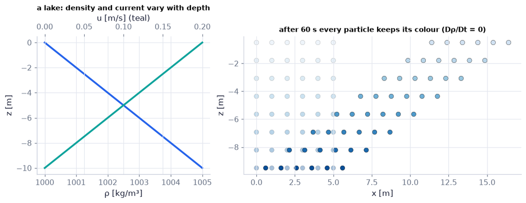

```python
z = np.linspace(-10, 0, 101)                                         # depth below the surface [m]
uz, rz = ch04.stratified_shear_flow(z, U0=0.2, shear=0.02, rho0=1000.0, drho_dz=-0.5)   # u(z) [m/s] and ρ(z) [kg/m³]
fig, (a, b) = plt.subplots(1, 2, figsize=(10, 3.8), gridspec_kw=dict(width_ratios=[1, 1.6]))        # the figure and its panels
a.plot(rz, z, color=COLORS["blue"], lw=2.5, label="ρ(z)")          # denser water deeper
a.set_xlabel("ρ [kg/m³]"); a.set_ylabel("z [m]")                                        # axis labels with units
a2 = a.twiny(); a2.plot(uz, z, color=COLORS["teal"], lw=2.5); a2.set_xlabel("u [m/s] (teal)")   # sheared current
a.set_title("a lake: density and current vary with depth", fontsize=10)                             # the panel's message
Z0 = np.repeat(np.linspace(-9.5, -0.5, 8), 6)                        # 48 particles on 8 levels
X0 = np.tile(np.linspace(0, 5, 6), 8)                                # 6 per level [m]
u0, r0 = ch04.stratified_shear_flow(Z0, U0=0.2, shear=0.02, rho0=1000.0, drho_dz=-0.5)   # each particle's speed and density
for tt, al in ((0.0, 0.35), (60.0, 1.0)):                            # start and after 60 s
    b.scatter(X0 + u0*tt, Z0, c=r0, cmap="Blues", vmin=999, vmax=1005.5, s=40, alpha=al, edgecolors="k", linewidths=0.3)  # draw the data
b.set_xlabel("x [m]"); b.set_ylabel("z [m]")                                        # axis labels with units
b.set_title("after 60 s every particle keeps its colour (Dρ/Dt = 0)", fontsize=10)                  # the panel's message
savefig(fig, "ch04", "stratified_flow"); plt.show()                                        # save the PNG to outputs/ch04, then draw
```

**What you see.** Horizontal layers sliding over each other (faded: start; solid: after 60 s); every dot keeps its colour.

**How to read it.** Each particle keeps its density ($D\rho/Dt=0$, incompressible) although density varies from layer to layer (ρ ≠ const): the surface layer moved farthest because the current is strongest there.

**What would change if…** …a vertical velocity w pushed dense water up: ρ at a fixed height would rise (∂ρ/∂t > 0), but each particle's density would still be its own — Dρ/Dt = 0 is about particles, not places.

**What would change if…** …the flow were steady and two-dimensional? Then (4.7), $\frac{\partial\rho}{\partial t}+\nabla\cdot(\rho\mathbf u)=0$ reduces to $\partial(\rho u)/\partial x+\partial(\rho v)/\partial y=0$ — two unknown fields tied by one equation. One scalar can then satisfy it automatically and carry the whole flow picture: the stream function (C03).

## 4.3 Stream Functions

**What is this section about?** Steady continuity is a constraint on the velocity field. Writing the mass flux as a cross product of two gradients satisfies it identically; in two dimensions a single function ψ remains, its contours are the streamlines, and the flux between two of them is the difference of their labels.

### 🧩 One number field for a whole 2-D flow: the stream function `C03`

*The question:* On a weather map the streamlines crowd together where the wind is strong. Is that a drawing convention — or can one scalar field carry both the direction and the speed of a 2-D flow?

#### The problem in plain words

A 2-D flow has two velocity components tied by continuity. If we could describe the whole flow by *one* function whose contours are the streamlines, every picture would be a contour plot, and the continuity equation could never be violated by a numerical slip. Potential-flow theory (Ch. 6), the Blasius boundary layer (Ch. 9) and quasi-geostrophic ocean and atmosphere models (Ch. 13) are all written this way.

#### The idea

```
ψ = const   along every streamline            u = ∂ψ/∂y ,  v = −∂ψ/∂x    (ρ = 1)
ψ₂ − ψ₁   = volume flux between two streamlines (per metre of depth)
equal steps Δψ between contours  →  contours close together = fast flow   (u ≈ Δψ/Δn)
```

📝 **Note.** **Steady continuity** `N13` — Start from continuity $\frac{\partial\rho}{\partial t}+\nabla\cdot(\rho\mathbf u)=0$ *(4.7)* with ∂ρ/∂t = 0 — steady flow:

$$ \nabla\cdot(\rho\mathbf u)=0 \qquad \text{(4.11)} $$

📝 **Note.** **A mass flux written as a curl** `N14` — A divergence of a curl is always zero ($\nabla\cdot\nabla\times\mathbf A=0$, Ch. 2 §2.13), so any mass flux written as a curl satisfies (4.11), $\nabla\cdot(\rho\mathbf u)=0$ automatically. Choosing the vector potential as $\chi\nabla\psi$ and using $\nabla\times\nabla\psi=0$ gives the book's (4.12). (That every steady solenoidal ρu can be written like this — locally — is asserted by the book, not proved; we only use the converse.) The sympy line below checks $\nabla\cdot(\nabla\chi\times\nabla\psi)=0$ for arbitrary χ, ψ.

$$ \rho\mathbf u=\nabla\times\boldsymbol\Psi,\qquad\boldsymbol\Psi=\chi\nabla\psi\ \Rightarrow\ \rho\mathbf u=\nabla\chi\times\nabla\psi \qquad \text{(4.12)} $$

```python
x, y, z = sp.symbols('x y z')                                        # Cartesian coordinates
chi = sp.Function('chi')(x, y, z); psi = sp.Function('psi')(x, y, z)  # two arbitrary smooth functions
m = ch04.mass_flux_from_stream_functions(chi, psi, (x, y, z))        # ρu = ∇χ × ∇ψ, three components
print(sp.simplify(sum(sp.diff(m[i], v) for i, v in enumerate((x, y, z)))))   # ∇·(ρu) = 0 identically
```

```
0
```

> 🔁 **Tools from earlier chapters used here** (see `knowledge/primers.md`) — needed in the derivation below
- **cross product with e_z; right-hand rule** — $\mathbf e_z\times\mathbf e_x=\mathbf e_y$, $\mathbf e_z\times\mathbf e_y=-\mathbf e_x$ (Ch. 2 P74).
- **chain rule along a curve dψ = ∇ψ·ds** — along a curve $\mathbf x(s)$, $d\psi/ds=\nabla\psi\cdot d\mathbf x/ds$ (Ch. 3 P91).
- **line integral along a path** — $\int_1^2\mathbf F\cdot d\mathbf s$ adds the tangential part of F along a path (Ch. 2 P86).

#### 🧮 Derivation — The 2-D stream function: ρu = ∂ψ/∂y, ρv = −∂ψ/∂x, and ψ₂ − ψ₁ = flux `D04`

**What we want to show.** From the two-function form of the mass flux, get the familiar 2-D stream function and prove that the flux between two streamlines is the difference of their ψ values — the book leaves the last part to Exercise 4.8.

**Assumptions.** Steady flow (continuity is ∇·(ρu) = 0); the flow is plane (no z dependence, w = 0) from step 4; ψ smooth.

**The plan.**

1. Expand the curl of χ∇ψ.
2. Choose χ = −z for a plane flow and take the cross product.
3. Integrate the flux across a curve and recognise an exact derivative.

**Tools we use** (each explained before this point): ∇·∇× = 0 and ∇×∇ = 0 (gloss, Ch. 2 §2.13) · curl of a product (gloss in step 2's why) · right-hand rule (ch02 P74) · chain rule along a path (ch03 P91) · fundamental theorem of calculus (ch02 P84).

**We start from**

$$ \text{(4.12):}\ \rho\mathbf u=\nabla\times\boldsymbol\Psi\ \text{with}\ \boldsymbol\Psi=\chi\nabla\psi $$

*In words:* a mass flux written as a curl satisfies steady continuity (4.11), $\nabla\cdot(\rho\mathbf u)=0$, automatically.

**Step 1 of 8 — Start from the vector potential.**

$$ \rho\mathbf u=\nabla\times(\chi\nabla\psi) $$

- *Why we can do this:* (4.12), $\rho\mathbf u=\nabla\times\boldsymbol\Psi=\nabla\chi\times\nabla\psi$: the divergence of a curl is zero (Ch. 2), so this ρu satisfies (4.11), $\nabla\cdot(\rho\mathbf u)=0$ for any χ, ψ. We choose Ψ = χ∇ψ because it leads to stream surfaces.
- *In words:* A flux built as a curl can never violate steady continuity.

**Step 2 of 8 — Expand the curl of a product.**

$$ \nabla\times(\chi\nabla\psi)=\nabla\chi\times\nabla\psi+\chi\,\nabla\times\nabla\psi $$

- *Why we can do this:* Product rule for the curl (gloss): in index form ε_ijk∂_j(χ∂_kψ) = ε_ijk∂_jχ∂_kψ + χε_ijk∂_j∂_kψ.
- *In words:* The curl splits into two pieces.

**Step 3 of 8 — Drop the curl of a gradient.**

$$ \rho\mathbf u=\nabla\chi\times\nabla\psi $$

- *Why we can do this:* ∇×∇ψ = 0 for a smooth ψ (mixed derivatives are equal and ε is antisymmetric, Ch. 2).
- *In words:* The mass flux is perpendicular to both gradients: flow runs along the surfaces χ = const and ψ = const.

**Step 4 of 8 — Choose χ = −z for a plane flow.**

$$ \chi=-z\ \Rightarrow\ \nabla\chi=-\mathbf e_z $$

- *Why we can do this:* In a plane flow every streamline lies in a plane z = const, so z (or −z) is a stream function; we pick the minus sign because it makes ρu = +∂ψ/∂y (step 6), the book's convention.
- *In words:* One family of stream surfaces is simply the stack of horizontal planes.

**Step 5 of 8 — Write ψ's gradient in the plane.**

$$ \nabla\psi=\Big(\frac{\partial\psi}{\partial x},\frac{\partial\psi}{\partial y},0\Big) $$

- *Why we can do this:* ψ = ψ(x, y) does not depend on z in a plane flow.
- *In words:* ψ varies only across the plane.

**Step 6 of 8 — Take the cross product.**

$$ \rho\mathbf u=-\mathbf e_z\times\nabla\psi=\Big(\frac{\partial\psi}{\partial y},\,-\frac{\partial\psi}{\partial x},\,0\Big) $$

- *Why we can do this:* e_z × e_x = e_y and e_z × e_y = −e_x (right-hand rule), so −e_z × (ψ_x e_x + ψ_y e_y) = ψ_y e_x − ψ_x e_y.
- *In words:* ρu = ∂ψ/∂y and ρv = −∂ψ/∂x.

**Step 7 of 8 — Integrate the flux across a curve.**

$$ \int_1^2\rho\mathbf u\cdot\mathbf n\,ds=\int_1^2\Big(\frac{\partial\psi}{\partial y}\frac{dy}{ds}+\frac{\partial\psi}{\partial x}\frac{dx}{ds}\Big)ds $$

- *Why we can do this:* The book skips this (Exercise 4.8): along a curve from 1 to 2 with tangent (dx/ds, dy/ds) the normal to the right of travel is n = (dy/ds, −dx/ds); insert step 6.
- *In words:* The flux through a gate, written with ψ.

**Step 8 of 8 — Recognise an exact derivative.**

$$ \int_1^2\rho\mathbf u\cdot\mathbf n\,ds=\int_1^2\frac{d\psi}{ds}\,ds=\psi_2-\psi_1 $$

- *Why we can do this:* Chain rule along the curve (ch03 P91): dψ/ds = ψ_x dx/ds + ψ_y dy/ds; then the fundamental theorem of calculus. Any path between the same end points gives the same flux.
- *In words:* The flux between two streamlines is the difference of their labels.

**Result**

$$ \rho u=\partial\psi/\partial y,\ \rho v=-\partial\psi/\partial x\ \text{and}\ \int_1^2\rho\mathbf u\cdot\mathbf n\,ds=\psi_2-\psi_1 $$

*In words:* one scalar carries a 2-D flow; its contours are streamlines, and the flux between two of them is the difference of the labels.

**What it means.** Contours of ψ at equal steps show direction *and* speed (crowded = fast). Used for every 2-D flow in Ch. 6, 8, 9 and the quasi-geostrophic flows of Ch. 13. Needs a plane (or axisymmetric) flow; in general 3-D flow two stream functions are needed.

**Check it.** Units: ψ in kg/(m s) (mass flux per metre of depth; m²/s when ρ = 1) ✓. Uniform stream ψ = Uy: u = U, v = 0, flux between y₁ and y₂ = U(y₂ − y₁) ✓. Ch. 3's cylinder ψ returns Ch. 3's velocity (C03 code) ✓. Continuity: ∂(ρu)/∂x + ∂(ρv)/∂y = ψ_yx − ψ_xy = 0 ✓.

> ⚠️ **Common confusion (traps in `D04`):** The opposite sign convention of many GFD texts (u = −∂ψ/∂y). Orienting the normal to the left of travel (the flux changes sign). Forgetting that the flux is per unit depth.

> ⚠️ **Sign convention.** With χ = −z the book (and this notebook) uses $u=\partial\psi/\partial y$, $v=-\partial\psi/\partial x$; many meteorology and oceanography texts use $u=-\partial\psi/\partial y$, $v=\partial\psi/\partial x$ (the flux is then ψ₁ − ψ₂). Same contours, opposite labels — check the convention before comparing numbers.

#### ✏️ Tiny example: the stagnation-point flow ψ = kxy with k = 1 s⁻¹

1. Velocity: $u=\partial\psi/\partial y=kx$, $v=-\partial\psi/\partial x=-ky$; at (1, 2) m: u = 1 m/s, v = −2 m/s.
2. Streamlines: xy = const — hyperbolas.
3. Flux between ψ = 1 and ψ = 2 m²/s: 2 − 1 = 1 m²/s per metre of depth, whichever path joins them.
4. Along the diagonal y = x the two contours cross at x = 1 m and $x=\sqrt2=1.414$ m, 0.586 m apart along the diagonal, where the speed is about $kx\sqrt2\approx1.7$ m/s — flux ≈ speed × spacing = 1.7 × 0.586 ≈ 1.0 ✓.
5. Where the contours are 0.1 m apart for Δψ = 1 m²/s, the speed is ≈ 10 m/s.

```python
print(ch04.velocity_from_streamfunction_2d("stagnation", 1.0, 2.0, k=1.0))   # (u, v) = (1, −2) m/s from ψ = kxy
print(ch04.flux_between_streamlines("stagnation", (1.0, 1.0), (np.sqrt(2), np.sqrt(2)), k=1.0))   # straight gate: 1.0 m²/s
gate = np.array([[1.0, 1.2, 1.3, 1.414213562], [1.0, 0.9, 1.25, 1.414213562]])   # a bent gate with the same two ends
print(ch04.flux_along_path("stagnation", gate, k=1.0))              # 1.0 m²/s again: only the end labels matter
psi_cyl = lambda x, y: ch03.cylinder_streamfunction(x, y, 1.0, 1.0)  # Ch. 3's cylinder ψ (U = 1 m/s, a = 1 m)
print(ch04.velocity_from_streamfunction_2d(psi_cyl, 2.0, 0.5), ch03.cylinder_flow(2.0, 0.5, 1.0, 1.0))   # the same pair twice
X, Y, k = sp.symbols('x y k')                                        # symbols for the exact version
print(ch04.velocity_from_streamfunction_2d_sym(k*X*Y, X, Y))         # (k*x, -k*y)
```

```
(1.0000000000065512, -2.000000000002)
0.9999999999174176
0.9999999988569178
(0.7923875432525039, -0.11072664360400884) (0.7923875432525952, -0.11072664359861592)
(k*x, -k*y)
```

**What does the code above do?**

1. Velocity by central differences of ψ: $u=\partial\psi/\partial y$, $v=-\partial\psi/\partial x$.
2. Flux through a straight gate = ψ₂ − ψ₁.
3. The same through a bent gate — the flux depends only on the end labels.
4. The cylinder's ψ from Ch. 3 gives back the Ch. 3 velocity (≈ (0.7924, −0.1107) m/s).
5. The symbolic version.

```python
h = 1e-5                                                             # finite-difference step [m]
psi = lambda x, y: ch04.streamfunction_preset("stagnation", x, y, k=1.0)   # ψ = kxy [m²/s]
u_fd = (psi(1, 2 + h) - psi(1, 2 - h)) / (2*h)                      # u = ∂ψ/∂y by a central difference
v_fd = -(psi(1 + h, 2) - psi(1 - h, 2)) / (2*h)                     # v = −∂ψ/∂x
assert np.allclose([u_fd, v_fd], [1.0, -2.0], rtol=1e-8)             # (1, −2) m/s, as the library said
p1, p2 = np.array([1.0, 1.0]), np.array([np.sqrt(2), np.sqrt(2)])     # the gate's ends (ψ = 1 and ψ = 2)
s = np.linspace(0, 1, 401)                                           # parameter along the gate
P = np.outer(p1, 1 - s) + np.outer(p2, s)                            # 401 points on the straight segment
t = (p2 - p1) / np.linalg.norm(p2 - p1); n = np.array([t[1], -t[0]])   # unit tangent and the normal to its right
un = ch04.velocity_preset("stagnation", *P, k=1.0)                   # exact (u, v) at those points
flux = np.trapezoid(un[0]*n[0] + un[1]*n[1], s) * np.linalg.norm(p2 - p1)   # ∫ u·n ds by trapezoids
print(flux)                                                          # 1.0 m²/s
assert np.isclose(flux, 1.0, rtol=1e-6)                              # = ψ₂ − ψ₁
```

```
1.0000000000000002
```

> 🔁 **Tools from earlier chapters used here** (see `knowledge/primers.md`)
- **plt.contour and streamplot** — `ax.contour(X, Y, F, levels)` draws level sets; `contourf` fills between them (Ch. 2 P78).

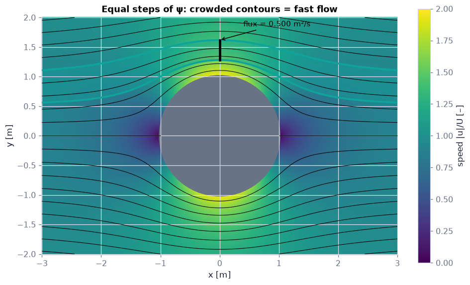

```python
n = 241 if not FAST else 121                                         # grid points along x
xg, yg = np.linspace(-3, 3, n), np.linspace(-2, 2, (2*n)//3)          # the window [m]
Xg, Yg = np.meshgrid(xg, yg)                                         # 2-D grids (rows = y)
PSI = ch03.cylinder_streamfunction(Xg, Yg, 1.0, 1.0)                 # ψ of the cylinder flow, U = 1 m/s, a = 1 m [m²/s]
Uc, Vc = ch03.cylinder_flow(Xg, Yg, 1.0, 1.0)                        # its velocity [m/s]
inside = np.hypot(Xg, Yg) < 1.0                                      # points inside the body
speed = np.ma.masked_where(inside, np.hypot(Uc, Vc))                 # speed |u|/U, hidden inside the cylinder
fig, ax = plt.subplots(figsize=(8.5, 5.2))                                        # the figure and its panels
im = ax.pcolormesh(Xg, Yg, speed, cmap="viridis", vmin=0, vmax=2, shading="auto")   # speed heat map
ax.contour(Xg, Yg, np.ma.masked_where(inside, PSI), levels=np.arange(-2, 2.01, 0.2), colors="k", linewidths=0.7,
           negative_linestyles="solid")                               # equal Δψ = 0.2 (solid for ψ < 0 too)
ax.contourf(Xg, Yg, np.ma.masked_where(inside, PSI), levels=[0.5, 1.0], colors=[COLORS["teal"]], alpha=0.35)   # the band ψ ∈ [0.5, 1]
ax.contour(Xg, Yg, np.ma.masked_where(inside, PSI), levels=[0.5, 1.0], colors=[COLORS["teal"]], linewidths=2.5)   # its edges
y1, y2 = [(c + np.sqrt(c**2 + 4))/2 for c in (0.5, 1.0)]             # where ψ = 0.5 and 1 cross x = 0: y − 1/y = c
F = ch04.flux_between_streamlines(lambda x, y: ch03.cylinder_streamfunction(x, y, 1.0, 1.0), (0.0, y1), (0.0, y2))   # gate flux
ax.plot([0, 0], [y1, y2], color="k", lw=3)                           # the gate across the band
ax.annotate(f"flux = {F:.3f} m²/s", (0, y2), (0.4, 1.85), fontsize=10, arrowprops=dict(arrowstyle="->"))  # a labelled arrow
ax.add_patch(plt.Circle((0, 0), 1.02, color=COLORS["muted"]))       # the cylinder (drawn 2 % larger to hide the mask edge)
ax.set_aspect("equal"); ax.set_xlabel("x [m]"); ax.set_ylabel("y [m]")                              # axis labels with units
fig.colorbar(im, ax=ax, label="speed |u|/U [–]")
ax.set_title("Equal steps of ψ: crowded contours = fast flow")                                      # the panel's message
savefig(fig, "ch04", "cylinder_psi"); plt.show()                                        # save the PNG to outputs/ch04, then draw
```

**What you see.** Contours bunch together over the top and bottom of the cylinder and spread out in front and behind; the heat map is brightest exactly where they bunch. The teal band between ψ = 0.5 and 1.0 m²/s narrows over the cylinder.

**How to read it.** Equal steps in ψ carry equal flux, so a narrow gap means fast flow: at the top of the cylinder the speed is 2U and the gap is about half its far-field value. The black gate across the teal band carries exactly ψ₂ − ψ₁ = 0.5 m²/s.

**What would change if…** …U doubled: every contour label doubles (ψ ∝ U) — with the same levels the drawing would show twice as many contours, each gap carrying the same 0.2 m²/s at twice the speed.

```python
import contourpy                                                     # matplotlib's contour engine: level sets as point lists
xs_, ys_ = np.linspace(-3, 5, 161), np.linspace(-2.5, 2.5, 101)      # the window [m]
Xs, Ys = np.meshgrid(xs_, ys_)                                       # 2-D grids
def level_lines(Z, levels):                                          # all contour pieces of several levels, NaN-separated
    gen = contourpy.contour_generator(xs_, ys_, Z)                   # a contour generator for this field
    px, py = [], []  # x and y of all contour pieces
    for c in levels:  # one contour level at a time
        for seg in gen.lines(c):                                     # each piece is an (n, 2) array of points
            px += list(seg[:, 0]) + [None]; py += list(seg[:, 1]) + [None]
    return px, py  # all pieces, ready for one plotly trace
def source_stream(m, U=1.0):                                         # source of strength m [m²/s] in a stream U [m/s]
    PS = ch04.streamfunction_preset("source_stream", Xs, Ys, U=U, m=m)   # ψ = Uy + (m/2π)θ
    th = np.linspace(1e-3, np.pi - 1e-3, 300)                        # polar angle along the body
    r = (m/2)*(1 - th/np.pi) / (U*np.sin(th)) if m > 0 else 0*th     # the dividing streamline ψ = ±m/2 in polar form
    bx = list(r*np.cos(th)) + [None] + list(r*np.cos(th)); by = list(r*np.sin(th)) + [None] + list(-r*np.sin(th))
    out = {"dividing streamline ψ = ±m/2": (bx, by) if m > 0 else ([-3, 5], [0, 0])}
    for k, dpsi in enumerate((0.3, 0.9)):                            # two families of streamlines outside the body
        out[f"ψ = ±(m/2 + {dpsi})"] = level_lines(PS, [m/2 + dpsi, -(m/2 + dpsi)])
    out["stagnation point"] = ([-m/(2*np.pi*U)], [0.0])              # where u = 0 on the axis
    return out  # the traces for this source strength
fig = slider_figure(source_stream, "m", np.linspace(0, 4, 17 if not FAST else 9), unit="m²/s", xlabel="x [m]",  # precompute every slider position (works on the web page)
                    ylabel="y [m]", title="A source in a stream: the half-body grows as m/(2U)", xrange=(-3, 5),  # labels, title and a fixed range
                    yrange=(-2.5, 2.5), modes={"stagnation point": "markers"})                      # labels, title and a fixed range
recolor(fig, {"dividing streamline ψ = ±m/2": COLORS["rose"], "ψ = ±(m/2 + 0.3)": COLORS["teal"],   # house colours for each trace, then draw
              "ψ = ±(m/2 + 0.9)": COLORS["blue"], "stagnation point": COLORS["ink"]}).show()        # colour of each named trace
```

[interactive chart not shown]

**What you see.** A rose half-body opening to the right, with teal and blue streamlines bending round it; the black stagnation point moves upstream as m grows.

**How to read it.** The dividing streamline (rose) encloses the source's fluid; its width far downstream is m/U — the flux m spread over the stream speed — and the stagnation point sits at $x=-m/(2\pi U)$ where the source's outflow just cancels the stream.

**What would change if…** …U doubled at fixed m: the body halves in width (m/U) and the stagnation point moves halfway back toward the source.

📝 **Note.** **Two stream functions** `N15` — Since $\rho\mathbf u=\nabla\chi\times\nabla\psi$ is perpendicular to both gradients, the flow runs *along* every surface χ = const and every surface ψ = const, so a 3-D streamline is where one of each meets (our version of Fig. 4.1, below).

$$ \rho\mathbf u\cdot\nabla\chi=\rho\mathbf u\cdot\nabla\psi=0 $$

> 🔁 **Tools from earlier chapters used here** (see `knowledge/primers.md`)
- **plotly 3-D surfaces and lines** — `go.Surface(x, y, z)` draws a sheet, `go.Scatter3d(mode='lines')` a curve; drag to rotate (Ch. 2 P64).

```python
chi_e, psi_e, (x, y, z) = ch04.stream_function_pair("parabolic")      # χ = y, ψ = z − x²
m_e = ch04.mass_flux_from_stream_functions(chi_e, psi_e, (x, y, z))   # ρu = ∇χ × ∇ψ = (1, 0, 2x)
print("ρu =", m_e)                                        # show the numbers
u3 = sp.lambdify((x, y, z), m_e, "numpy")                            # a numeric velocity from the sympy one
uf = lambda X, t: np.array([np.ones_like(X[0]), 0*X[0], 2*X[0]], dtype=float)   # the same field as fluidpy expects: u(x, t)
nn = 40 if not FAST else 24                                          # surface resolution
xs_ = np.linspace(-1, 1, nn); zz = np.linspace(-0.5, 2.5, nn)          # plotting ranges [m]
a_, b_, c_, d_ = 0.0, 1.0, 0.0, 1.0                                  # the four labels χ = a, b and ψ = c, d
fig = go.Figure()
for yv in (a_, b_):                                                  # the planes χ = y = a and y = b (blue)
    XX, ZZ = np.meshgrid(xs_, zz)                                        # 2-D grids of the coordinates
    fig.add_trace(go.Surface(x=XX, y=0*XX + yv, z=ZZ, opacity=0.25, colorscale=[[0, COLORS["blue"]], [1, COLORS["blue"]]], showscale=False, name=f"χ = {yv}"))  # add a trace to the plotly figure
for cv in (c_, d_):                                                  # the parabolic sheets ψ = z − x² = c and d (orange)
    XX, YY = np.meshgrid(xs_, np.linspace(-0.3, 1.3, nn))                                        # 2-D grids of the coordinates
    fig.add_trace(go.Surface(x=XX, y=YY, z=XX**2 + cv, opacity=0.35, colorscale=[[0, COLORS["orange"]], [1, COLORS["orange"]]], showscale=False, name=f"ψ = {cv}"))  # add a trace to the plotly figure
for yv in (a_, b_):                                                  # four streamlines traced numerically from the velocity
    for cv in (c_, d_):  # the two sheets ψ = c and ψ = d
        sl = ch03.streamline(uf, np.array([-1.0, yv, 1.0 + cv]), s_max=3.5, both=False)   # start on the intersection at x = −1
        fig.add_trace(go.Scatter3d(x=sl[0], y=sl[1], z=sl[2], mode="lines", line=dict(color=COLORS["ink"], width=6), showlegend=False))  # add a trace to the plotly figure
        assert np.allclose(sl[2] - sl[0]**2, cv, atol=1e-6) and np.allclose(sl[1], yv)   # it stays on both surfaces
yy, zp = np.meshgrid(np.linspace(a_, b_, 2), np.linspace(c_, d_, 2))  # the patch in the plane x = 0 bounded by the four sheets
fig.add_trace(go.Surface(x=0*yy, y=yy, z=zp, opacity=0.8, colorscale=[[0, COLORS["muted"]], [1, COLORS["muted"]]], showscale=False, name="patch"))  # add a trace to the plotly figure
fig.update_layout(height=520, title="Streamlines where χ = const meets ψ = const (flux through the grey patch = (b − a)(d − c))",  # axis titles and layout
                  scene=dict(xaxis_title="x [m]", yaxis_title="y [m]", zaxis_title="z [m]"))
fig.show()                                        # draw the interactive figure
```

```
ρu = [1, 0, 2*x]
```

[interactive chart not shown]

**What you see.** Blue planes and orange parabolic sheets crossing along parabolas; the black streamlines lie exactly on the crossings; a grey patch spans the tube between them.

**How to read it.** The flow $\mathbf u=(1,0,2x)$ climbs as it goes right; every streamline stays in its plane y = const and on its sheet $z-x^2$ = const (the cell asserts it).

**What would change if…** …χ = y replaced by χ = y + x: the planes tilt, the streamlines leave the planes y = const, and the flux through the patch stays (b − a)(d − c).

📝 **Note.** **Flux through a stream tube** `N16` — The tube bounded by χ = a, b and ψ = c, d carries $\dot m=\oint_C\chi\,d\psi=b(d-c)+a(c-d)=(b-a)(d-c)$ — on the ψ = const legs dψ = 0, on the χ = b leg the integral is b(d − c), on χ = a it is a(c − d) (Stokes' theorem, Ch. 2 §2.13).

```python
print(ch04.stream_tube_mass_flux("parabolic", "parabolic", 0.0, 1.0, 0.0, 2.0))   # (numeric patch flux, (b − a)(d − c)) = (2.0, 2.0) kg/s
```

```
(2.0000000000099614, 2.0)
```

> 🔁 **Tools from earlier chapters used here** (see `knowledge/primers.md`)
- **cylindrical unit vectors** — $\mathbf e_R$ points away from the z-axis, $\mathbf e_z$ along it; $u_R$, $u_z$ are projections on them (Ch. 3 P88).

📝 **Note.** **Axisymmetric flows** `N17` — (no swirl, streamlines in planes through the z-axis) use χ = −φ. Test: ψ = ½UR² gives $u_z=U$, $u_R=0$ — a uniform stream along the axis (code: `ch04.velocity_from_streamfunction_axisym("axisym_uniform", 0.5, 0.3, U=2.0)` → (0.0, 2.0), printed below). Used for the sphere (Ch. 6) and pipe flow (Ch. 8); the flux between two stream surfaces is 2π(ψ₂ − ψ₁).

$$ \rho u_R=-\frac1R\frac{\partial\psi}{\partial z},\qquad\rho u_z=\frac1R\frac{\partial\psi}{\partial R} $$

```python
print(ch04.velocity_from_streamfunction_axisym("axisym_uniform", 0.5, 0.3, U=2.0))   # (u_R, u_z) = (0, 2) m/s at R = 0.5 m
```

```
(-0.0, 1.9999999999964488)
```

📝 **Note.** **Constant density** `N18` — With constant density the same construction holds for u itself, and ψ differences are volume fluxes (m²/s per metre of depth in 2-D) — every function here takes `rho=1.0` by default. Ch. 6 uses it throughout.

> 🔁 **Tools from earlier chapters used here** (see `knowledge/primers.md`)
- **show_viz** — embeds an interactive explainer; on the web page it fills the window (Ch. 1 P18).

#### 🎮 Interactive: Can one number field hold a whole 2-D flow?

**Why interactive rather than a static figure:** a static contour plot shows one flow and one gate; here you move the gate, bend it and switch flows, and see the flux stay equal to ψ₂ − ψ₁ while the spacing–speed link updates under your cursor.

Seven classic flows drawn as ψ contours at equal steps over a speed map, with tracers moving along them. Drag a gate across the flow: its flux stays equal to ψ₂ − ψ₁ however you tilt or bend it; click a point to read $u=\partial\psi/\partial y$, $v=-\partial\psi/\partial x$ from the contour slopes.

**What to try:**

- Choose 'stagnation' and drag the gate between the ψ = 1 and ψ = 2 contours along two different paths — the flux readout stays 1 m²/s.
- Choose 'cylinder': where do the contours crowd? Read the speed there in Explain.
- Choose 'line vortex': the contours are circles packed tighter toward the centre — the speed grows as 1/r.
- Open the Derivation tab and step through D04 with the uniform stream.

```python
show_viz("ch04", "stream_function_spacing")   # full-width explainer; ⤢ Full screen for more room
```

🎮 Interactive 1/9 Can one number field hold a whole 2-D flow? Open alone ↗

[interactive chart not shown]

**What would change if…** …the flow were not steady? In 2-D incompressible flow ψ still exists at every instant (∇·u = 0 is enough), but its contours are then the *instantaneous* streamlines, not paths (Ch. 3 §3.3). Knowing the flow pattern, the next question is what forces it takes to maintain it — momentum (C04).

## 4.4 Conservation of Momentum

**What is this section about?** Newton's second law for a material volume, carried to any control volume (forces from fluxes: wakes, bores, rockets, sprinklers), Bernoulli's equation from a thin stream tube, and — shrunk to a point — Cauchy's equation of motion, Newton's law for every continuum.

> 🔁 **Recap — Surface force from the stress tensor** (Ch. 2 §2.6). On a surface element with unit normal n the force per unit area is $f_j=n_i\tau_{ij}$ *(Eq. 2.15)*: the **first** index of τ is contracted with the normal. Its normal part is $\mathbf n\cdot\mathbf f=n_if_i$ and its tangential part $f_k-(n_if_i)n_k$. For a fluid at rest $\tau_{ij}=-p\delta_{ij}$ and $\mathbf f=-p\mathbf n$, a push along the inward normal.

```python
tau = np.array([[-1e5, 3.0, 0], [3.0, -1e5, 0], [0, 0, -1e5]])        # pressure 1e5 Pa plus a 3 Pa shear pair [Pa]
n = np.array([1, 1, 0]) / np.sqrt(2)                                  # the unit normal of a 45° plane
print(tensors.traction(tau, n))                                       # f_j = n_i τ_ij ≈ (−70708.6, −70708.6, 0) Pa
print(tensors.normal_shear_stress(tau, n)[:2])                        # normal −99997.0 Pa, shear 0.0 Pa
```

```
[-70708.5568 -70708.5568      0.    ]
(-99997.00000000001, 2.0579515874459978e-11)
```

**What does the code above do?**

Traction and its normal and shear parts for pressure plus a small shear stress: on the 45° plane the shear pair adds +3 Pa to the normal part (−100000 + 3) and leaves no shear — that plane is a principal plane of this τ.

> 🔁 **Recap — Surface tension acts through boundary conditions** (Ch. 1 §1.6). Surface tension is a force per unit length acting along lines in an interface (Ch. 1 §1.6), not a force on the bulk fluid, so it never appears in the field equations of this chapter; it enters through the conditions at a free surface or an interface — derived from a force balance on a curved cap in C14.

### 🧩 Forces from fluxes: momentum in a moving box (4.17) `C04`

*The question:* A bar is held in a wind tunnel on a thin sting. You may not touch the bar or the sting — you may only measure the air speed behind it. Can you tell how hard the air pushes on the bar?

*In one line:* $\frac{d}{dt}\int_{V^*}\rho\mathbf u\,dV+\int_{A^*}\rho\mathbf u(\mathbf u-\mathbf b)\cdot\mathbf n\,dA=\int_{V^*}\rho\mathbf g\,dV+\int_{A^*}\mathbf f\,dA$ *(4.17)*

#### The problem in plain words

Measuring the force on a body directly is often impossible (a ship's hull, a turbine blade in a machine, the Earth's surface under a wind). But the fluid leaving a region carries momentum away, and Newton's law says the momentum a box loses per second must be supplied by forces. Count the momentum flowing in and out of a box drawn round the body and you have weighed the force. The same bookkeeping gives the speed of a tidal bore, the thrust of a rocket and the torque of a lawn sprinkler.

#### The idea

```
rate of change of momentum inside  +  momentum carried OUT through the walls (relative to them)
     d/dt ∫ ρu dV                   +  ∮ ρu (u − b)·n dA
=   body forces on the fluid       +  surface forces on the fluid
     ∫ ρg dV                        +  ∮ f dA                                   (4.17)
steady flow, fixed box:  (momentum out − momentum in) = forces on the fluid  → force on the body = −(that)
```

*The numbered equations in the sketch:* $\frac{d}{dt}\int_{V^*}\rho\mathbf u\,dV+\int_{A^*}\rho\mathbf u(\mathbf u-\mathbf b)\cdot\mathbf n\,dA=\int_{V^*}\rho\mathbf g\,dV+\int_{A^*}\mathbf f\,dA$ *(4.17)*

| 📝 **Note.** **Body forces vs surface forces** `N26` — | body forces | surface forces |  |
| --- | --- | --- | --- |
|  | act without contact, ∝ mass | act by contact, ∝ area |  |
|  | given per unit mass (an acceleration, m/s²) | given per unit area (a stress, Pa) |  |
|  | gravity, electromagnetic; in accelerating frames the fictitious forces of §4.7 | pressure and viscous stress |  |

In $\frac{d}{dt}\int_{V^*}\rho\mathbf u\,dV+\int_{A^*}\rho\mathbf u(\mathbf u-\mathbf b)\cdot\mathbf n\,dA=\int_{V^*}\rho\mathbf g\,dV+\int_{A^*}\mathbf f\,dA$ *(4.17)* the first is $\int\rho\mathbf g\,dV$, the second $\int\mathbf f\,dA$ with $f_j=n_i\tau_{ij}$ (R03).

> 📎 **Primer — momentum flux through a surface.** `P114` · Fluid crossing a surface carries its momentum with it. Through a patch dA the *volume* crossing per second is $(\mathbf u-\mathbf b)\cdot\mathbf n\,dA$ (velocity relative to the patch, component along the normal); its mass is ρ times that, and its momentum is u times that mass: $\rho\mathbf u\,[(\mathbf u-\mathbf b)\cdot\mathbf n]\,dA$ — a vector (the direction of u) times a scalar (the rate of crossing). A jet of water 1 cm² in area at 10 m/s through a fixed nozzle carries ρU²A = 1000 × 100 × 10⁻⁴ = 10 N of momentum per second.

```python
rho, U, A = 1000.0, 10.0, 1e-4          # water [kg/m³], speed [m/s], area [m²]
mdot = rho*U*A                          # mass flux [kg/s]
print(mdot, mdot*U)                     # 1.0 kg/s carries 10.0 N of x-momentum per second
```

```
1.0 10.0
```

> 🔁 **Tools from earlier chapters used here** (see `knowledge/primers.md`)
- **Newton's second law and momentum** — force = rate of change of momentum, $\mathbf F=d(m\mathbf u)/dt$ (Ch. 1 P09).

📝 **Note.** **Newton's second law for a material volume** `N19` — momentum per volume ρu, body force per mass g, surface force per area f, outward n:

$$ \frac{d}{dt}\int_{V(t)}\rho\mathbf u\,dV=\int_{V(t)}\rho\mathbf g\,dV+\int_{A(t)}\mathbf f\,dA \qquad \text{(4.13)} $$

#### 🧮 Derivation — Momentum for an arbitrarily moving control volume: (4.13) → (4.14) → (4.15) → (4.16a–d) → (4.17) `D05` (Eq. 4.17)

**What we want to show.** Give Newton's second law the same "any box" form that D01 gave mass conservation, so forces can be read from fluxes through a box we choose.

**Assumptions.** As D01; f is the traction (force per area) exerted on the fluid by whatever is outside, pressure included.

**The plan.**

1. Expand the material rate (b = u) component by component.
2. Write the theorem for our box.
3. Use the coincidence trick of D01 four times.
4. Substitute and merge the flux terms; check the special boxes.

**Tools we use** (each explained before this point): RTT (3.35), $\frac{d}{dt}\int_{V^*}F\,dV=\int_{V^*}\frac{\partial F}{\partial t}dV+\int_{A^*}F\,\mathbf b\cdot\mathbf n\,dA$ applied to each component (gloss) · D01's coincidence move · momentum flux through a surface (primer in C04) · Newton's second law (ch01 P09).

**We start from**

$$ \text{(4.13):}\ \frac{d}{dt}\int_{V(t)}\rho\mathbf u\,dV=\int_{V(t)}\rho\mathbf g\,dV+\int_{A(t)}\mathbf f\,dA $$

*In words:* the momentum of a material volume changes at the rate of the forces on it.

**Step 1 of 8 — Start from Newton's law for the balloon.**

$$ \frac{d}{dt}\int_{V(t)}\rho\mathbf u\,dV=\int_{V(t)}\rho\mathbf g\,dV+\int_{A(t)}\mathbf f\,dA $$

- *Why we can do this:* (4.13), $\frac{d}{dt}\int_{V(t)}\rho\mathbf u\,dV=\int_{V(t)}\rho\mathbf g\,dV+\int_{A(t)}\mathbf f\,dA$: momentum per volume ρu, body force per mass g, surface force per area f, all for the same particles. We want it for a box.
- *In words:* Momentum changes only by forces.

**Step 2 of 8 — Expand with the transport theorem, b = u.**

$$ \int_{V}\frac{\partial(\rho\mathbf u)}{\partial t}dV+\int_{A}\rho\mathbf u\,(\mathbf u\cdot\mathbf n)\,dA=\int_{V}\rho\mathbf g\,dV+\int_{A}\mathbf f\,dA $$

- *Why we can do this:* RTT (3.35), $\frac{d}{dt}\int_{V^*}F\,dV=\int_{V^*}\frac{\partial F}{\partial t}dV+\int_{A^*}F\,\mathbf b\cdot\mathbf n\,dA$ applied to each component F = ρu_j (a vector is three scalars); the skin moves with u. This is (4.14), $\int_{V(t)}\frac{\partial}{\partial t}(\rho\mathbf u)dV+\int_{A(t)}\rho\mathbf u(\mathbf u\cdot\mathbf n)dA=\int_{V(t)}\rho\mathbf g\,dV+\int_{A(t)}\mathbf f\,dA$ — the line above.
- *In words:* Local change of momentum plus momentum carried by the moving skin equals the forces.

**Step 3 of 8 — Write the theorem for our box.**

$$ \int_{V^*}\frac{\partial(\rho\mathbf u)}{\partial t}dV=\frac{d}{dt}\int_{V^*}\rho\mathbf u\,dV-\int_{A^*}\rho\mathbf u\,(\mathbf b\cdot\mathbf n)\,dA $$

- *Why we can do this:* RTT (3.35), $\frac{d}{dt}\int_{V^*}F\,dV=\int_{V^*}\frac{\partial F}{\partial t}dV+\int_{A^*}F\,\mathbf b\cdot\mathbf n\,dA$ with F = ρu for V*, rearranged. This is (4.15), $\int_{V^*}\frac{\partial}{\partial t}(\rho\mathbf u)dV=\frac{d}{dt}\int_{V^*}\rho\mathbf u\,dV-\int_{A^*}\rho\mathbf u\,(\mathbf b\cdot\mathbf n)\,dA$ — the line above; the book prints an extra "= 0" at its end, a slip: this line is an identity between three terms.
- *In words:* The local momentum change in the box = its total rate minus what the walls sweep.

**Step 4 of 8 — Let the box and balloon coincide now.**

$$ \int_{V}\{\cdot\}\,dV=\int_{V^*}\{\cdot\}\,dV,\qquad\int_{A}\{\cdot\}\,dA=\int_{A^*}\{\cdot\}\,dA $$

- *Why we can do this:* Same integrands, same region, same instant (D01 steps 4–5): the four equalities (4.16a–d) for ∂(ρu)/∂t, ρu(u·n), ρg and f.
- *In words:* Every integral over the balloon equals the one over the box, right now.

**Step 5 of 8 — Move step 2 onto the box.**

$$ \int_{V^*}\frac{\partial(\rho\mathbf u)}{\partial t}dV+\int_{A^*}\rho\mathbf u\,(\mathbf u\cdot\mathbf n)\,dA=\int_{V^*}\rho\mathbf g\,dV+\int_{A^*}\mathbf f\,dA $$

- *Why we can do this:* Replace each integral of step 2 by its box twin from step 4 — nothing else changes.
- *In words:* The balloon's momentum law, written on the box.

**Step 6 of 8 — Substitute the box's theorem.**

$$ \frac{d}{dt}\int_{V^*}\rho\mathbf u\,dV-\int_{A^*}\rho\mathbf u\,(\mathbf b\cdot\mathbf n)\,dA+\int_{A^*}\rho\mathbf u\,(\mathbf u\cdot\mathbf n)\,dA=\ldots $$

- *Why we can do this:* Step 3 expresses the local integral through the box's total rate and the swept momentum; the right side is unchanged.
- *In words:* Now the box's own momentum rate appears.

**Step 7 of 8 — Merge the two surface integrals.**

$$ \frac{d}{dt}\int_{V^*}\rho\mathbf u\,dV+\int_{A^*}\rho\mathbf u\,(\mathbf u-\mathbf b)\cdot\mathbf n\,dA=\int_{V^*}\rho\mathbf g\,dV+\int_{A^*}\mathbf f\,dA $$

- *Why we can do this:* Same surface, same ρu: combine (u·n) − (b·n) = (u − b)·n. This is (4.17), $\frac{d}{dt}\int_{V^*}\rho\mathbf u\,dV+\int_{A^*}\rho\mathbf u(\mathbf u-\mathbf b)\cdot\mathbf n\,dA=\int_{V^*}\rho\mathbf g\,dV+\int_{A^*}\mathbf f\,dA$ — the line above: momentum carried across the walls relative to them.
- *In words:* Box momentum rate + momentum carried out relative to the walls = forces.

**Step 8 of 8 — Check the special boxes.**

$$ \mathbf b=\mathbf u\Rightarrow\text{(4.13)};\qquad\mathbf b=0,\ \text{steady}:\ \oint_{A^*}\rho\mathbf u\,(\mathbf u\cdot\mathbf n)\,dA=\int_{V^*}\rho\mathbf g\,dV+\oint_{A^*}\mathbf f\,dA $$

- *Why we can do this:* A material box gives back Newton for the balloon; a fixed box in steady flow reads forces from fluxes alone — the wake, jet and sprinkler cases.
- *In words:* Momentum out minus in equals the forces on the fluid.

**Result**

$$ \frac{d}{dt}\int_{V^*}\rho\mathbf u\,dV+\int_{A^*}\rho\mathbf u(\mathbf u-\mathbf b)\cdot\mathbf n\,dA=\int_{V^*}\rho\mathbf g\,dV+\int_{A^*}\mathbf f\,dA $$

*In words:* forces from fluxes, for any box.

**What it means.** The engineer's momentum tool: wake drag (Ex. 4.1), bores (Ex. 4.3), rockets (Ex. 4.4), the momentum integral of Ch. 9, lift and drag of Ch. 14, shock relations of Ch. 15. It gives the force on the *fluid*; the body feels the opposite.

**Check it.** Units: N for every term ✓. b = u gives (4.13), $\frac{d}{dt}\int_{V(t)}\rho\mathbf u\,dV=\int_{V(t)}\rho\mathbf g\,dV+\int_{A(t)}\mathbf f\,dA$ ✓. Wake (steady, fixed box, pressure p∞ on every face): out − in = −3.652 N/m = −F_D/l, so F_D/l = 3.652 N/m ✓ (C04 code). Bore with b = U: storage 0 ✓ (the `control_volume_budgets` explainer's bore mode).

> ⚠️ **Common confusion (traps in `D05`):** The book's "= 0" in (4.15), $\int_{V^*}\frac{\partial}{\partial t}(\rho\mathbf u)dV=\frac{d}{dt}\int_{V^*}\rho\mathbf u\,dV-\int_{A^*}\rho\mathbf u\,(\mathbf b\cdot\mathbf n)\,dA$. Treating ρu(u − b)·n as a dot product of two vectors (it is a vector times a scalar). Forgetting that f includes pressure. Taking the force on the body with the wrong sign (Newton III).

📝 **Note.** **The book's (4.14)** `N20` — Step 2 of D05 is the transport theorem applied to each component of ρu with b = u. It is also the starting line of Cauchy's equation (C06).

$$ \int_{V(t)}\frac{\partial}{\partial t}(\rho\mathbf u)dV+\int_{A(t)}\rho\mathbf u(\mathbf u\cdot\mathbf n)dA=\int_{V(t)}\rho\mathbf g\,dV+\int_{A(t)}\mathbf f\,dA \qquad \text{(4.14)} $$

📝 **Note.** **The book's (4.15)** `N21` — Step 3 is the same theorem for our box, rearranged.

> ⚠️ **Book slip:** the printed (4.15) ends with an extra "= 0". That would claim ∂(ρu)/∂t integrates to zero; (4.15) is an identity between three terms (compare $\frac{d}{dt}\int_{V^*(t)}\rho\,dV-\int_{V^*(t)}\frac{\partial\rho}{\partial t}dV-\int_{A^*(t)}\rho\,\mathbf b\cdot\mathbf n\,dA=0$ *(4.3)*, where "= 0" is right because the mass statement was already substituted).

$$ \int_{V^*}\frac{\partial}{\partial t}(\rho\mathbf u)dV=\frac{d}{dt}\int_{V^*}\rho\mathbf u\,dV-\int_{A^*}\rho\mathbf u\,(\mathbf b\cdot\mathbf n)\,dA \qquad \text{(4.15)} $$

📝 **Note.** **The coincidence equalities** `N22` `N23` `N24` `N25` — step 4 is the book's (4.16a–d): at the instant V* = V, the same integrand over the same region gives the same number — exactly the move of D01, now for a vector.

$$ \begin{aligned}\int_{V}\frac{\partial(\rho\mathbf u)}{\partial t}dV=\int_{V^*}\frac{\partial(\rho\mathbf u)}{\partial t}dV\quad&\text{(4.16a)}\\ \int_{A}\rho\mathbf u(\mathbf u\cdot\mathbf n)dA=\int_{A^*}\rho\mathbf u(\mathbf u\cdot\mathbf n)dA\quad&\text{(4.16b)}\\ \int_{V}\rho\mathbf g\,dV=\int_{V^*}\rho\mathbf g\,dV\quad&\text{(4.16c)}\\ \int_{A}\mathbf f\,dA=\int_{A^*}\mathbf f\,dA\quad&\text{(4.16d)}\end{aligned} $$

> 📎 **Primer — conservative force and its potential.** `P115` · A force field is *conservative* if the work it does on a particle moving from A to B does not depend on the route. Then it is minus the gradient of a potential energy per unit mass Φ, and the work round any closed loop is zero. Gravity near the ground: Φ = gz, force per mass −∇Φ = (0, 0, −g).

```python
loop = itg.planar_loop(center=(0.0, 0.0, 0.0), normal=(1.0, 0.0, 0.0), radius=2.0)   # a vertical circle of radius 2 m
g = lambda X, Y, Z: np.array([0*X, 0*Y, -9.81 + 0*Z])        # uniform gravity field per unit mass [m/s²]
print(itg.circulation(g, loop))                               # work of g round the loop per unit mass: ≈ 0 J/kg
```

```
7.327471962526033e-15
```

📝 **Note.** **Conservative body force** `N27` — with z up. For gravity Φ = gz gives $\mathbf g=-g\mathbf e_z$; `ch04.body_force_from_potential("gravity", (0, 0, 5))` → (0, 0, −9.81) m/s² (printed below). C11 uses Φ to fold gravity into the Bernoulli function.

$$ \mathbf g=-\nabla\Phi\quad\text{or}\quad g_j=-\partial\Phi/\partial x_j \qquad \text{(4.18)} $$

```python
print(ch04.body_force_from_potential("gravity", np.array([0.0, 0.0, 5.0])))   # −∇(gz) at z = 5 m: (0, 0, −9.81) m/s²
```

```
[-0.   -0.   -9.81]
```

> ⚠️ **Common confusion — whose force?** `N28` Drag $F_D$ is the force *on the body*, positive downstream. The forces in (4.17), $\frac{d}{dt}\int_{V^*}\rho\mathbf u\,dV+\int_{A^*}\rho\mathbf u(\mathbf u-\mathbf b)\cdot\mathbf n\,dA=\int_{V^*}\rho\mathbf g\,dV+\int_{A^*}\mathbf f\,dA$, are forces *on the fluid in the box*. By Newton's third law the body pushes the fluid with $-F_D\mathbf e_x$. Forget the minus and the drag comes out negative.

#### ✏️ Tiny example: drag of a bar from its wake (Ex. 4.1, our synthetic wake)

Far downstream the speed is $U(y)=U_\infty-\Delta\,e^{-y^2/b^2}$ with $U_\infty$ = 10 m/s, Δ = 2 m/s, b = 0.1 m; air ρ = 1.2 kg/m³; the box is H = 2 m tall, its inlet far upstream (uniform $U_\infty$) and its outlet in the wake; pressure is $p_\infty$ on all faces (so the pressure forces cancel — Gauss on a constant).

1. **Mass:** less leaves through the outlet than enters the inlet, by $\int(U_\infty-U)dy=\Delta b\sqrt\pi=2\times0.1\times1.7725=0.354$ m²/s per metre of span — that must leave through the top and bottom (the Gaussian integral $\int_{-\infty}^{\infty}e^{-y^2/b^2}dy=b\sqrt\pi$).
2. That side outflow carries x-momentum $U_\infty$ per unit mass: $\rho U_\infty\times0.354$.
3. **Momentum x:** out − in $=\rho\int U^2dy+\rho U_\infty(0.354)-\rho\int U_\infty^2dy$, which must equal the force on the fluid, $-F_D/l$.
4. Collect: $F_D/l=\rho\int U(U_\infty-U)\,dy$ (N29).
5. Numbers: $\int U(U_\infty-U)dy=U_\infty\Delta b\sqrt\pi-\Delta^2b\sqrt{\pi/2}=3.5449-0.5013=3.0436$ m³/s²; × 1.2 = **3.65 N/m** of span.

📝 **Note.** **Ex. 4.1 result** `N29` — (given; the derivation is the worked example above). It needs the top and bottom faces far enough out that shear and pressure deviations there vanish; the integral of $U(1-U/U_\infty)/U_\infty$ is the *momentum thickness* of Ch. 9.

$$ F_D/l=\rho\int_{-H/2}^{+H/2}U(y)\big(U_\infty-U(y)\big)dy $$

```python
y = np.linspace(-1, 1, 5)                                            # five heights across the box [m]
print(ch04.gaussian_wake(y, 10.0, 2.0, 0.1))                          # U(y): 10, 10, 8, 10, 10 m/s
print(ch04.wake_side_outflow("gaussian", 10.0, 2.0))                  # mass leaking through the sides: 0.3545 m²/s (U∞ = 10, H = 2 m)
print(ch04.wake_drag_per_span("gaussian", 10.0, 1.2, 2.0, return_error=True))   # (F_D/l, quadrature error) = (3.6523 N/m, ~1e-12)
sc = ch04.cv_scenario("wake", U_inf=10.0, deficit=2.0, width=0.1, rho=1.2, H=2.0)   # the same budget face by face
for f in sc["faces"]:                                                  # inlet, outlet, top, bottom
    print(f"{f['name']:6s} mass {f['mass_flux']:+9.4f} kg/(m s)   x-mom {f['momentum_flux_x']:+9.4f} N/m")   # out +, in −
print(sc["result"], sc["residual_mass"], sc["residual_momentum"])    # 3.6523 N/m, residuals ≈ 0
```

```
[10. 10.  8. 10. 10.]
0.35449077018110314
(3.652298456261798, 7.684208205471734e-13)
inlet  mass  -24.0000 kg/(m s)   x-mom -240.0000 N/m
outlet mass  +23.5746 kg/(m s)   x-mom +232.0938 N/m
top    mass   +0.2127 kg/(m s)   x-mom   +2.1269 N/m
bottom mass   +0.2127 kg/(m s)   x-mom   +2.1269 N/m
3.652298456261798 -2.7755575615628914e-15 -4.04121180963557e-14
```

**What does the code above do?**

1. Our synthetic wake profile.
2. The mass leaking through the sides, $\Delta b\sqrt\pi$.
3. The drag formula of N29 by adaptive quadrature with its error estimate.
4. The same budget face by face (signs: out positive, in negative) — per metre of span the inlet brings −240 N/m of x-momentum, the outlet takes +232.09 N/m and the sides +2.13 N/m each; the sum −3.652 N/m is the force on the fluid, $-F_D/l$, so the bar feels +3.652 N/m.

```python
y = np.linspace(-1, 1, 4001)                                         # fine grid across the box [m]
U = ch04.gaussian_wake(y, 10, 2, 0.1)                                # outlet profile [m/s]
m_in = -1.2*np.trapezoid(10*np.ones_like(y), y)                      # mass flux in through the inlet (negative) [kg/(m s)]
m_out = 1.2*np.trapezoid(U, y)                                        # mass flux out through the outlet
m_side = -(m_in + m_out)                                              # continuity: what is missing leaves through the sides
p_in = -1.2*np.trapezoid(100*np.ones_like(y), y)                     # x-momentum in: −ρU∞² H [N/m]
p_out = 1.2*np.trapezoid(U**2, y)                                     # x-momentum out through the outlet
p_side = m_side*10.0                                                  # side outflow carries U∞ per unit mass
FD = -(p_in + p_out + p_side)                                         # force on the bar = −(net momentum outflow)
print(FD)                                                             # 3.6523 N/m
assert np.isclose(FD, ch04.wake_drag_per_span("gaussian", 10.0, 1.2, 2.0), rtol=1e-8)   # same as the library
```

```
3.6522984562617893
```

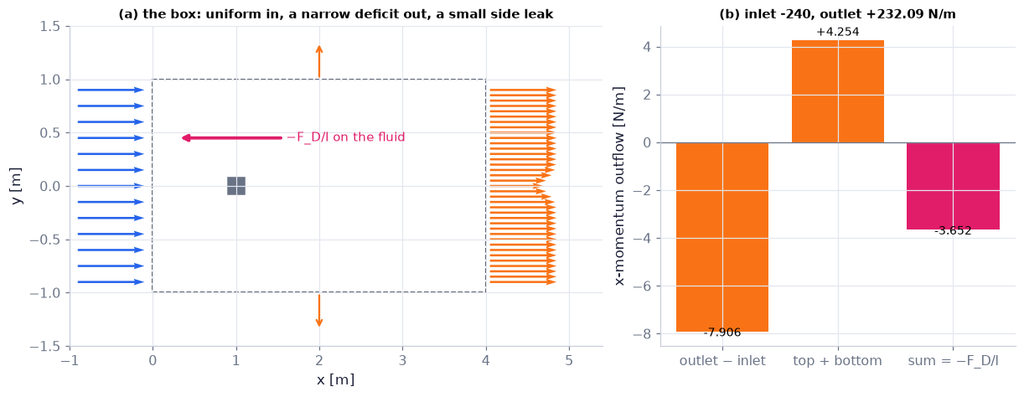

```python
sc = ch04.cv_scenario("wake", U_inf=10.0, deficit=2.0, width=0.1, rho=1.2, H=2.0)   # the four faces of the box
F = {f["name"]: f for f in sc["faces"]}                               # faces by name
fig, (a, b) = plt.subplots(1, 2, figsize=(11, 4.2), gridspec_kw=dict(width_ratios=[1.5, 1]))        # the figure and its panels
a.add_patch(plt.Rectangle((0, -1), 4, 2, fill=False, ls="--", ec=COLORS["ink"]))   # the control volume (inlet x = 0, outlet x = 4)
a.add_patch(plt.Rectangle((0.9, -0.08), 0.2, 0.16, color=COLORS["muted"]))   # the bar
ys = np.linspace(-0.9, 0.9, 13)                                       # arrow rows
a.quiver(np.zeros_like(ys) - 0.9, ys, 10*np.ones_like(ys), 0*ys, color=COLORS["blue"], scale=80, width=0.004)   # uniform inflow U∞
yw = np.linspace(-0.9, 0.9, 37)                                       # finer rows in the wake
a.quiver(np.full_like(yw, 4.05), yw, ch04.gaussian_wake(yw, 10, 2, 0.1), 0*yw, color=COLORS["orange"], scale=80, width=0.004)   # outflow U(y)
for yy in (-1, 1):                                                    # small outflow through top and bottom
    a.annotate("", (2.0, yy + 0.35*np.sign(yy)), (2.0, yy), arrowprops=dict(arrowstyle="->", color=COLORS["orange"], lw=1.5))  # a labelled arrow
a.annotate("−F_D/l on the fluid", (0.3, 0.45), (1.6, 0.45), color=COLORS["rose"], fontsize=10, va="center",       # a labelled arrow
           arrowprops=dict(arrowstyle="-|>", color=COLORS["rose"], lw=2.5))   # the force on the fluid points upstream
a.set_xlim(-1, 5.4); a.set_ylim(-1.5, 1.5); a.set_xlabel("x [m]"); a.set_ylabel("y [m]")            # axis labels with units
a.set_title("(a) the box: uniform in, a narrow deficit out, a small side leak", fontsize=10)        # the panel's message
vals = [F["outlet"]["momentum_flux_x"] + F["inlet"]["momentum_flux_x"],        # outlet − inlet (net through the ends)
        F["top"]["momentum_flux_x"] + F["bottom"]["momentum_flux_x"],          # top + bottom
        -sc["result"]]                                                        # the sum = −F_D/l
b.bar(["outlet − inlet", "top + bottom", "sum = −F_D/l"], vals, color=[COLORS["orange"], COLORS["orange"], COLORS["rose"]])  # draw the data
for i, v in enumerate(vals):                                          # label each bar with its value
    b.text(i, v + 0.2*np.sign(v), f"{v:+.3f}", ha="center", fontsize=9)                             # a label on the plot
b.axhline(0, color=COLORS["muted"], lw=0.8); b.set_ylabel("x-momentum outflow [N/m]")               # axis labels with units
b.set_title(f"(b) inlet {F['inlet']['momentum_flux_x']:.0f}, outlet +{F['outlet']['momentum_flux_x']:.2f} N/m", fontsize=10)  # the panel's message
savefig(fig, "ch04", "wake_budget"); plt.show()                                        # save the PNG to outputs/ch04, then draw
```

**What you see.** A thin deficit in the orange outlet profile and a small but nonzero leak through the top and bottom; on the right, a negative net end flux, a positive side flux and their rose sum.

**How to read it.** The fluid leaves with less momentum than it brought; the difference, including what leaks out sideways at speed U∞, is the force on the fluid, −F_D/l = −3.652 N/m — so the bar is pushed downstream with 3.652 N per metre of span.

**What would change if…** …the box made taller: the side leak and every face flux change, the drag does not (it depends only on the deficit).

```python
yy = np.linspace(-1.0, 1.0, 201)                                     # across the wake [m]
Uy = ch04.gaussian_wake(yy, 10.0, 2.0, 0.1)                           # U(y) [m/s]
def box(H):                                                           # what a box of height H sees
    inside = np.abs(yy) <= H/2                                        # the part of the wake inside the box
    return {"U(y) [m/s]": (yy, Uy),                                        # the curves for this slider value
            "integrand ρU(U∞ − U) inside the box [N/m²]": (yy[inside], (1.2*Uy*(10.0 - Uy))[inside]),  # another named curve (x, y)
            "faces y = ±H/2": ([-H/2, -H/2, None, H/2, H/2], [0, 11, None, 0, 11])}                 # another named curve (x, y)
fig = slider_figure(box, "H", np.linspace(0.1, 2.0, 20 if not FAST else 10), unit="m", xlabel="y [m]", ylabel="U [m/s] · integrand [N/m²]",  # precompute every slider position (works on the web page)
                    title="A box must enclose the whole wake (F_D/l → 3.652 N/m)", xrange=(-1, 1), yrange=(0, 11))  # labels, title and a fixed range
recolor(fig, {"U(y) [m/s]": COLORS["teal"], "integrand ρU(U∞ − U) inside the box [N/m²]": COLORS["rose"],  # house colours for each trace, then draw
              "faces y = ±H/2": COLORS["muted"]}, {"faces y = ±H/2": "dash"}).show()                # colour of each named trace
for H in (0.1, 0.2, 0.3, 0.5, 2.0):                                   # the drag a box of height H would report
    print(f"H = {H:.1f} m: F_D/l = {ch04.wake_drag_per_span('gaussian', 10.0, 1.2, H):.4f} N/m")    # show the numbers
```

[interactive chart not shown]

```
H = 0.1 m: F_D/l = 1.8034 N/m
H = 0.2 m: F_D/l = 3.0105 N/m
H = 0.3 m: F_D/l = 3.5097 N/m
H = 0.5 m: F_D/l = 3.6506 N/m
H = 2.0 m: F_D/l = 3.6523 N/m
```

**What you see.** The teal wake profile and the rose integrand; the grey faces close in as H shrinks and cut off the rose curve's tails.

**How to read it.** Below H ≈ 3b = 0.3 m the box cuts the wake and misses part of the deficit (the printed F_D/l falls below 3.652 N/m); above it F_D/l stops changing — and the formula's assumptions (uniform pressure, no shear on the sides) also need the faces outside the wake.

**What would change if…** …a wider wake (b = 0.2 m): the box must be twice as tall before the drag stops changing.

📝 **Note.** **Ex. 4.3 — a small bore (surge) with a moving control volume** `N31` — Dimensional analysis first (the Π theorem of Ch. 1, R12): with g, h and the speed U there is one group, $U^2/(gh)$, so $U\propto\sqrt{gh}$. Riding with the wave (b = U e_x) the flow in the box is steady; hydrostatic pressure on the vertical faces, $p_o$ on the free surface (its net push cancels), mass and momentum give the result below. Number: still water $h_{in}$ = 1 m ahead of the wave, $h_{out}$ = 1.1 m behind it → U = √(9.81 × 1.1 × 2.1/2) = 3.37 m/s, close to √(gh) = 3.13 m/s (the shallow-water wave speed of Ch. 7 and Ch. 13).

$$ U^2\frac{h_{in}}{h_{out}}=\frac g2(h_{in}+h_{out}),\qquad U=\sqrt{\frac{gh_{out}}{2h_{in}}(h_{in}+h_{out})}\approx\sqrt{gh} $$

> 🔁 **Tools from earlier chapters used here** (see `knowledge/primers.md`)
- **Python dictionaries** — `{'name': value}` maps names to values and `d['name']` reads one — fluidpy returns many results this way (Ch. 1 P23).
- **np.random.default_rng** — `np.random.default_rng(seed)` makes reproducible random numbers (Ch. 1 P10).
- **hydrostatic pressure on a vertical face ½ρgh²** — $\int_0^h\rho g(h-y)\,dy=\tfrac12\rho gh^2$ per metre of width (Ch. 1 P28).

```python
print(ch04.bore_speed(1.0, 1.1), np.sqrt(9.81*1.0))                  # 3.3661 m/s vs √(gh) = 3.1321 m/s
for p_o in (1.0e5, 0.0):                                              # two atmospheric pressures [Pa]
    print(ch04.bore_pressure_force(1.0, 1.1, p_o=p_o))                # end faces and top [N per m width]; `net` does not change
```

```
3.3660882341376617 3.132091952673165
{'left': 104905.0, 'right': -115935.05000000003, 'top': 10000.00000000001, 'net': -1030.050000000023}
{'left': 4905.0, 'right': -5935.05, 'top': 0.0, 'net': -1030.0500000000002}
```

**What does the code above do?**

1. The bore speed from the momentum budget and the shallow-water estimate √(gh).
2. The horizontal pressure forces on the moving box: each end face carries $p_o h$ plus the hydrostatic $\tfrac12\rho gh^2$ (4905 N and 5935 N per metre width), the sloping top carries $p_o(h_{out}-h_{in})$; the net, −1030 N/m, does not depend on $p_o$.

```python
h_in, h_out, g0 = 1.0, 1.1, 9.81                                      # depths ahead of / behind the front [m]
U = ch04.bore_speed(h_in, h_out)                                     # front speed [m/s], moving to the left
V = U - ch04.bore_outlet_velocity(h_in, h_out)                       # lab speed of the water behind the front [m/s]
frames = 60 if not FAST else 30                                      # number of frames
T = 3.0                                                              # duration [s]
x = np.linspace(0, 16, 400)                                          # the channel [m]
x_front = lambda t: 12.0 - U*t                                       # front position [m]
eta = lambda t: h_in + (h_out - h_in)*0.5*(1 + np.tanh((x - x_front(t))/0.3))   # surface: 1 m ahead (left), 1.1 m behind
rng = np.random.default_rng(0)  # reproducible random parcel positions (Ch. 1 P10)
xp0 = rng.uniform(0.5, 15.5, 60); yp = rng.uniform(0.1, 0.9, 60)      # parcels [m]
fig, ax = plt.subplots(figsize=(7, 2.8), dpi=80)                                        # the figure and its panels
(surf,) = ax.plot(x, eta(0), color=COLORS["blue"], lw=2)             # the free surface
dots = ax.scatter(xp0, yp, s=10, color=COLORS["teal"])                # water parcels
(box,) = ax.plot([], [], "k--", lw=1.2)                              # the control volume riding with the front
ax.set_xlim(0, 16); ax.set_ylim(0, 1.35); ax.set_xlabel("x [m]"); ax.set_ylabel("height [m]")       # axis labels with units
ax.set_title(f"A bore moving left at U = {U:.2f} m/s; in the box's frame the flow is steady", fontsize=10)  # the panel's message


def update(i):                                                       # draw frame i
    t = i*T/frames                                                   # time [s]
    surf.set_ydata(eta(t))                                           # move the front
    t_pass = (12.0 - xp0)/U                                          # when the front reached each parcel
    xp = np.where(t > t_pass, xp0 - V*(t - t_pass), xp0)             # at rest ahead; moving left at V behind
    dots.set_offsets(np.c_[xp, yp])                                  # move the parcels
    xf = x_front(t)
    box.set_data([xf - 1.5, xf + 1.5, xf + 1.5, xf - 1.5, xf - 1.5], [0.02, 0.02, 1.25, 1.25, 0.02])   # the riding box
    return surf, dots, box                                        # the artists that changed in this frame


show_animation(animate(update, frames=frames, fig=fig, interval=50))                                # build the movie from update() and play it
```

[video not shown]

**What you see.** The dashed box slides left with the front; parcels ahead of it are at rest, parcels behind it creep slowly left.

**How to read it.** Seen from the box, water enters fast (at U = 3.37 m/s) and 1 m deep and leaves slower and 1.1 m deep — a steady budget whose solution is the front's speed. Behind the front the water moves left at only U(1 − h_in/h_out) ≈ 0.31 m/s.

**What would change if…** …h_out → h_in: the front becomes a small wave and its speed tends to √(gh).

📝 **Note.** **Ex. 4.4 — a rocket as an accelerating control volume** `N32` — (b = b(t) e_z). Exhaust leaves the nozzle at $V_e$ relative to the rocket; with $F_S$ the sum of drag and pressure thrust, mass and vertical momentum give the pair below. With g = $F_S$ = 0 it integrates to Tsiolkovsky's $\Delta b=V_e\ln(M_0/M_1)$ (our extension; ln is the natural logarithm): $M_0$ = 2 kg, $M_1$ = 1 kg, $V_e$ = 800 m/s → 554.5 m/s.

$$ \frac{dM}{dt}+\rho_eV_eA_e=0,\qquad M\frac{d^2z_R}{dt^2}=-V_e\frac{dM}{dt}-Mg+F_S $$

> 🔁 **Tools from earlier chapters used here** (see `knowledge/primers.md`)
- **natural logarithm** — $\ln$ undoes $e^x$; $\int dM/M=\ln M$ (Ch. 1 P36).
- **separation of variables (rocket, tank, meniscus)** — move all of one variable to one side and integrate each side (Ch. 1 P42).

```
burn-out speed 456.4 m/s; ΔV without gravity 554.5 m/s
```

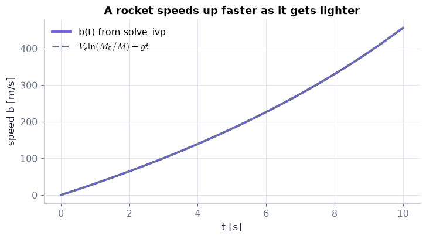

```python
r = ch04.rocket_trajectory(2.0, 0.1, 800.0, 10.0, t_eval=np.linspace(0, 10, 201))   # M0 = 2 kg, 0.1 kg/s, Ve = 800 m/s, 10 s burn
ghost = 800.0*np.log(2.0/r["M"]) - 9.81*r["t"]                        # Tsiolkovsky minus the gravity loss gt [m/s]
fig, ax = plt.subplots(figsize=(6.5, 3.6))                                        # the figure and its panels
ax.plot(r["t"], r["b"], color=COLORS["accent"], lw=2.5, label="b(t) from solve_ivp")       # the rocket's speed
ax.plot(r["t"], ghost, "--", color=COLORS["muted"], label=r"$V_e\ln(M_0/M)-gt$")          # closed form
ax.set_xlabel("t [s]"); ax.set_ylabel("speed b [m/s]"); ax.legend()                                 # axis labels with units
ax.set_title("A rocket speeds up faster as it gets lighter")                                        # the panel's message
print(f"burn-out speed {r['b'][-1]:.1f} m/s; ΔV without gravity {ch04.rocket_delta_v(2.0, 1.0, 800.0):.1f} m/s")  # show the numbers
savefig(fig, "ch04", "rocket"); plt.show()                                        # save the PNG to outputs/ch04, then draw
```

**What you see.** A purple curve bending upward, with the grey dashed closed form on top of it.

**How to read it.** The thrust V_e|dM/dt| = 80 N is constant but it pushes less and less mass; the numerical and closed-form speeds agree: 456.4 m/s at burn-out, 554.5 m/s without gravity.

**What would change if…** …V_e doubled: every speed doubles minus the gravity loss gt, which does not change.

> 📎 **Primer — torque, moment arm and moment of inertia.** `P116` · A force F applied at position r (from an axis point) turns a body with torque M = r × F; only the part of F perpendicular to r, times the distance, counts (the moment arm). The angular analogue of mass is the moment of inertia: for a cube of side h and density ρ spinning about an axis through its centre, I = ρh⁵/6. Rate of change of angular momentum = net torque. (`np.cross` is the cross product of Ch. 2 on arrays.)

```python
r = np.array([0.2, 0.0, 0.0])                  # lever 0.2 m along x
F = np.array([0.0, 5.0, 0.0])                  # 5 N pushing along y
print(np.cross(r, F))                          # torque (0, 0, 1.0) N m about z
rho, h = 1000.0, 0.01; print(rho*h**5/6)       # I of a 1 cm water cube: 1.67e-08 kg m²
```

```
[0. 0. 1.]
1.666666666666667e-08
```

📝 **Note.** **Angular momentum of a rigid body** `N82` — For a rigid body the rate of change of angular momentum equals the applied torque. Its fluid version for a fixed control volume follows.

$$ d\mathbf H/dt=\mathbf M \qquad \text{(4.64)} $$

📝 **Note.** **Angular momentum for a stationary control volume** `N83` — (the transport theorem with F = r × ρu, the same move as D05). Internal torques cancel in pairs — because the stress is symmetric, which C07 proves.

$$ \frac{d}{dt}\int_{V_o}(\mathbf r\times\rho\mathbf u)dV+\int_{A_o}(\mathbf r\times\rho\mathbf u)(\mathbf u\cdot\mathbf n)dA=\int_{V_o}(\mathbf r\times\rho\mathbf g)dV+\int_{A_o}(\mathbf r\times\mathbf f)dA \qquad \text{(4.65)} $$

📝 **Note.** **Ex. 4.6 — a lawn sprinkler held still** `N84` — Two jets of area A at radius a leave at speed U, tilted by α from the tangential direction; only the tangential part U cos α has a moment arm, so the torque needed to hold the arm is as below. Number: a = 0.2 m, water, A = 1 cm², U = 5 m/s, α = 30° → M = 2 × 0.2 × 1000 × 10⁻⁴ × 25 × 0.866 = 0.866 N m. Let go of it and (with no friction) it spins until the jets leave with no tangential speed, at Ω = U cos α/a = 21.7 rad/s (our extension).

$$ M=2a\rho AU^2\cos\alpha $$

```python
print(ch04.sprinkler_torque(0.2, 1000.0, 1e-4, 5.0, np.pi/6), ch04.sprinkler_free_spin_rate(0.2, 5.0, np.pi/6))   # 0.866 N m, 21.65 rad/s
```

```
0.8660254037844387 21.650635094610966
```

#### 🎮 Interactive: Weigh a force by counting what flows through a box

**Why interactive rather than a static figure:** the figure above shows one box; the lesson of a control volume is that you may choose the box — its size, its speed, which fluid it holds — and only by moving it yourself do you see which face fluxes change while the force stays put.

One scene, one control volume, every face's flux as a bar: storage + outflow − inflow on the left of $\frac{d}{dt}\int_{V^*}\rho\mathbf u\,dV+\int_{A^*}\rho\mathbf u(\mathbf u-\mathbf b)\cdot\mathbf n\,dA=\int_{V^*}\rho\mathbf g\,dV+\int_{A^*}\mathbf f\,dA$ (4.17), forces on the right, and a residual that stays at zero. Four scenarios (wake, bore, jet, rocket) and three box types (fixed, riding, material). (For a box of finite height the Gaussian wake's integrals use the error function erf, the finite-limit version of $\int e^{-y^2/b^2}dy=b\sqrt\pi$.)

**What to try:**

- In 'wake', shrink the box height below three wake widths — the status turns amber and the drag readout drops: the box cuts the wake.
- In 'bore', drag the box speed b until the storage bar vanishes: that speed is the bore's speed (Explain shows the formula).
- Switch the budget to mass and choose the material box (b = u): every flux bar vanishes — that is (4.1), $\frac{d}{dt}\int_{V(t)}\rho\,dV=0$.
- Open the Derivation tab and step through D01: the coincidence step freezes the balloon on top of the box.

```python
show_viz("ch04", "control_volume_budgets")   # full-width explainer; ⤢ Full screen for more room
```

🎮 Interactive 2/9 Weigh a force by counting what flows through a box Open alone ↗

[interactive chart not shown]

**What would change if…** …the box were a thin stream tube in a steady, frictionless flow? Its side walls carry no flux, only pressure; the momentum budget along it becomes a relation between speed, pressure and height — Bernoulli's equation (C05).

### 🧩 Bernoulli along a streamline: fast flow, low pressure (4.19) `C05`

*The question:* An airliner measures its airspeed with a small tube pointing into the wind and a hole in its side — no moving parts. How does a pressure difference become a speed?

*In one line:* $\tfrac12U^2+gz+p/\rho=\text{const along a streamline}$ *(4.19)*

#### The problem in plain words

Pitot tubes on aircraft and in rivers, the speed of water leaving a hole in a tank, the suction on the top of a wing: all trade pressure for speed along the path of the fluid. The trade follows from momentum conservation on a very thin stream tube in a steady, frictionless, constant-density flow.

#### The idea

```
along ONE streamline, per unit mass:   ½U²  +  g z  +  p/ρ  = constant           (4.19)
                                       kinetic  potential  "pressure energy"
speed up (U ↑) → pressure down (p ↓) at the same height;  stop the flow (U = 0) → pressure up by ½ρU²
```

*The numbered equations in the sketch:* $\tfrac12U^2+gz+p/\rho=\text{const along a streamline}$ *(4.19)*

> 📎 **Primer — sympy expand, series, removeO, collect and subs.** `P117` · Four sympy moves for approximations: `expand` multiplies brackets out, `series(expr, ds, 0, 2)` keeps powers of ds up to ds¹ and adds an O(ds²) marker that `removeO()` drops, `collect(expr, ds)` groups terms by powers of ds, and `subs({a: b})` substitutes. Here: keep only first-order terms of a small element of length ds.

```python
ds, U, dU = sp.symbols('ds U dU')                               # a small length and two symbols
e = sp.expand((U + dU*ds)**2)                                   # U**2 + 2*U*dU*ds + dU**2*ds**2
print(e.series(ds, 0, 2).removeO())                             # U**2 + 2*U*dU*ds (ds² dropped)
print(sp.collect(e, ds), e.subs({U: 2, dU: 1, ds: 0.1}))        # grouped by powers of ds; 4.41
```

```
U**2 + 2*U*dU*ds
U**2 + 2*U*dU*ds + dU**2*ds**2 4.41000000000000
```

> 🔁 **Tools from earlier chapters used here** (see `knowledge/primers.md`)
- **first-order Taylor expansion** — $f(s+ds)\approx f(s)+f'(s)\,ds$ for a small step ds (Ch. 1 P26).
- **limits and orders of smallness** — terms in $ds^2$ vanish faster than ds as ds → 0 and drop out after dividing by ds (Ch. 2 P68).

📝 **Note.** **Ex. 4.2 builds (4.19), $\tfrac12U^2+gz+p/\rho=\text{const along a streamline}$ from a stream-tube element** `N30` — of length ds: mass with first-order changes of U and A, the streamwise momentum with gravity (sin θ ds = dz) and the extra pressure force on the slowly widening side, then drops the (ds)² terms to get the line below. The derivation fills in the moves the book skips (where the side pressure force comes from, why the mean area multiplies gravity).

$$ U\frac{\partial U}{\partial s}ds=-g\,dz-\frac1\rho\frac{\partial p}{\partial s}ds $$

#### 🧮 Derivation — Bernoulli along a streamline from a stream-tube element (Ex. 4.2) `D06` (Eq. 4.19)

**What we want to show.** Derive $\tfrac12U^2+gz+p/\rho=$ constant along a streamline (4.19), $\tfrac12U^2+gz+p/\rho=\text{const along a streamline}$ from the mass and momentum budgets of a thin piece of stream tube, filling in the steps the book skips.

**Assumptions.** Steady (step 1: storage terms vanish); inviscid (step 1: only pressure acts on surfaces); constant ρ (steps 1, 9, 11); fixed element b = 0 (step 1); faces small enough for uniform U, p across each (step 2).

**The plan.**

1. Specialise (4.5), $\frac{d}{dt}\int_{V^*(t)}\rho\,dV+\int_{A^*(t)}\rho\,(\mathbf u-\mathbf b)\cdot\mathbf n\,dA=0$ and (4.17), $\frac{d}{dt}\int_{V^*}\rho\mathbf u\,dV+\int_{A^*}\rho\mathbf u(\mathbf u-\mathbf b)\cdot\mathbf n\,dA=\int_{V^*}\rho\mathbf g\,dV+\int_{A^*}\mathbf f\,dA$ to a fixed element in steady, frictionless, constant-density flow.
2. Face by face: mass balance, momentum flux, forces (including the side push).
3. Simplify with the mass balance, drop small terms, divide.
4. Recognise exact differentials and integrate.

**Tools we use** (each explained before this point): (4.5), $\frac{d}{dt}\int_{V^*(t)}\rho\,dV+\int_{A^*(t)}\rho\,(\mathbf u-\mathbf b)\cdot\mathbf n\,dA=0$ and (4.17), $\frac{d}{dt}\int_{V^*}\rho\mathbf u\,dV+\int_{A^*}\rho\mathbf u(\mathbf u-\mathbf b)\cdot\mathbf n\,dA=\int_{V^*}\rho\mathbf g\,dV+\int_{A^*}\mathbf f\,dA$ (C01, C04) · first-order Taylor expansion (ch01 P26) · orders of smallness (ch02 P68) · side pressure force on a slowly widening tube (gloss in step 5) · chain rule · sympy expand/series (primer in C05) for the check.

**We start from**

$$ \begin{array}{l}\text{A fixed element of a stream tube, length ds along a streamline s: inlet area} \\ \text{A, speed U, pressure p; outlet}\ A+\frac{\partial A}{\partial s}ds\ \text{,}\ U+\frac{\partial U}{\partial s}ds\ \text{,}\ p+\frac{\partial p}{\partial s}ds\ \text{; the} \\ \text{tube axis rises by sin θ ds}\end{array} $$

*In words:* a short tapering tube whose side is made of streamlines.

**Step 1 of 11 — Specialise the two box laws.**

$$ \oint\rho\mathbf u\cdot\mathbf n\,dA=0,\qquad\oint\rho\mathbf u\,(\mathbf u\cdot\mathbf n)\,dA=\int\rho\mathbf g\,dV-\oint p\,\mathbf n\,dA $$

- *Why we can do this:* (4.5), $\frac{d}{dt}\int_{V^*(t)}\rho\,dV+\int_{A^*(t)}\rho\,(\mathbf u-\mathbf b)\cdot\mathbf n\,dA=0$ and (4.17), $\frac{d}{dt}\int_{V^*}\rho\mathbf u\,dV+\int_{A^*}\rho\mathbf u(\mathbf u-\mathbf b)\cdot\mathbf n\,dA=\int_{V^*}\rho\mathbf g\,dV+\int_{A^*}\mathbf f\,dA$ with b = 0 (fixed element), no time derivative (steady), f = −pn (inviscid: no shear).
- *In words:* What enters leaves; momentum out minus in equals gravity plus pressure.

**Step 2 of 11 — Evaluate u·n on each face.**

$$ \mathbf u\cdot\mathbf n\,dA=-U\,dA\ (\text{inlet}),\quad0\ (\text{side}),\quad+\Big(U+\frac{\partial U}{\partial s}ds\Big)dA\ (\text{outlet}) $$

- *Why we can do this:* The side is made of streamlines, so u is tangent to it; inlet and outlet are perpendicular to u. First-order Taylor gives the outlet values.
- *In words:* Fluid enters at one end, leaves at the other, never through the side.

**Step 3 of 11 — Write the mass balance.**

$$ -\rho UA+\rho\Big(U+\frac{\partial U}{\partial s}ds\Big)\Big(A+\frac{\partial A}{\partial s}ds\Big)=0 $$

- *Why we can do this:* Insert step 2 into the first law of step 1, with uniform speed over each small face.
- *In words:* The mass flux at the outlet equals that at the inlet.

**Step 4 of 11 — Write the streamwise momentum flux.**

$$ -\rho U^2A+\rho\Big(U+\frac{\partial U}{\partial s}ds\Big)^2\Big(A+\frac{\partial A}{\partial s}ds\Big) $$

- *Why we can do this:* Momentum flux = velocity × mass flux (primer in C04); along s each face carries its speed times step 2.
- *In words:* Momentum leaving minus momentum entering.

**Step 5 of 11 — Add up the streamwise forces.**

$$ -\rho g\sin\theta\Big(A+\frac{\partial A}{\partial s}\frac{ds}{2}\Big)ds+pA+\Big(p+\frac{\partial p}{\partial s}\frac{ds}{2}\Big)\frac{\partial A}{\partial s}ds-\Big(p+\frac{\partial p}{\partial s}ds\Big)\Big(A+\frac{\partial A}{\partial s}ds\Big) $$

- *Why we can do this:* Gravity on the element (mean area × ds); pressure pushes the inlet forward, the outlet back; the book skips why: the widening side's mean pressure times its projected area (∂A/∂s)ds pushes forward.
- *In words:* Weight, the two end pushes, and the side push.

**Step 6 of 11 — Simplify the flux with the mass balance.**

$$ \rho\Big(U+\frac{\partial U}{\partial s}ds\Big)UA-\rho U^2A=\rho UA\,\frac{\partial U}{\partial s}ds $$

- *Why we can do this:* By step 3 the outlet mass flux is ρUA, so the outlet momentum flux is (U + U_s ds) × ρUA; subtract the inlet ρU²A.
- *In words:* The momentum gained is the mass flux times the speed gained.

**Step 7 of 11 — Expand the forces, use sin θ ds = dz.**

$$ -\rho g\Big(A+\frac{\partial A}{\partial s}\frac{ds}2\Big)dz+\frac{\partial p}{\partial s}\frac{\partial A}{\partial s}\frac{(ds)^2}2-A\frac{\partial p}{\partial s}ds-\frac{\partial p}{\partial s}\frac{\partial A}{\partial s}(ds)^2 $$

- *Why we can do this:* Multiplying out step 5, pA and p(∂A/∂s)ds each appear with both signs and cancel; sin θ ds is the height gained, dz.
- *In words:* What is left of the forces.

**Step 8 of 11 — Drop the second-order terms.**

$$ \rho UA\,\frac{\partial U}{\partial s}ds=-\rho gA\,dz-A\frac{\partial p}{\partial s}ds $$

- *Why we can do this:* Terms with (ds)² or ds dz shrink faster than ds as the element shrinks and vanish after dividing by ds (orders of smallness, P68).
- *In words:* Only first-order changes remain.

**Step 9 of 11 — Divide by ρA.**

$$ U\frac{\partial U}{\partial s}ds=-g\,dz-\frac1\rho\frac{\partial p}{\partial s}ds $$

- *Why we can do this:* A > 0 and ρ is constant; every term is now per unit mass.
- *In words:* Speeding up is paid for by falling or by a pressure drop.

**Step 10 of 11 — Recognise exact differentials.**

$$ d\big(\tfrac12U^2\big)+g\,dz+\frac{dp}{\rho}=0 $$

- *Why we can do this:* Along the streamline U(∂U/∂s)ds = d(U²/2) (chain rule) and (∂p/∂s)ds = dp; with ρ constant dp/ρ = d(p/ρ).
- *In words:* The changes of three quantities add to zero.

**Step 11 of 11 — Integrate along the streamline.**

$$ \tfrac12U^2+gz+p/\rho=\text{constant along a streamline} $$

- *Why we can do this:* A sum of differentials that is zero means the sum itself does not change along the path (fundamental theorem of calculus). This is (4.19), $\tfrac12U^2+gz+p/\rho=\text{const along a streamline}$ — the line above.
- *In words:* Speed, height and pressure trade off along a streamline.

**Result**

$$ \tfrac12U^2+gz+p/\rho=\ \text{a constant along a streamline} $$

*In words:* in steady, frictionless, constant-density flow, kinetic energy, potential energy and "pressure energy" per unit mass trade along each streamline.

**What it means.** The engineer's Bernoulli: pitot tubes, orifices, pressure on bodies. Its constant belongs to one streamline; C11 shows when it is the same on all of them. It fails with friction (behind a cylinder), unsteadiness (C12) and compressibility (C11's energy form).

**Check it.** Units m²/s² ✓. U = 0: p + ρgz constant — hydrostatics (1.8), $dp/dz=-\rho g$ ✓. Pitot: 500 Pa ↔ 28.87 m/s ✓. sympy check (the cell below): `ch04.stream_tube_element_balance_sym()` expands steps 3–7 symbolically, keeps O(ds) with `series(...).removeO()` and prints `U*U_s + g*sin(theta) + p_s/rho` (U_s = ∂U/∂s, p_s = ∂p/∂s; with sin θ = dz/ds this is d(½U² + gz + p/ρ)/ds) together with a residual 0 against (4.19), $\tfrac12U^2+gz+p/\rho=\text{const along a streamline}$.

```python
ds, U, A, p, rho, g = sp.symbols('ds U A p rho g', positive=True)   # length, speed, area, pressure, density, gravity
Us, As, ps, th = sp.symbols('U_s A_s p_s theta')                 # U_s = ∂U/∂s, A_s = ∂A/∂s, p_s = ∂p/∂s (any sign), tilt θ
mass = -rho*U*A + rho*(U + Us*ds)*(A + As*ds)                                   # step 3: mass out − mass in
mom = -rho*U**2*A + rho*(U + Us*ds)**2*(A + As*ds)                              # step 4: momentum out − momentum in
forces = (-rho*g*sp.sin(th)*(A + As*ds/2)*ds + p*A                             # step 5: weight on the mean area, inlet push,
          + (p + ps*ds/2)*As*ds - (p + ps*ds)*(A + As*ds))                      #         side push, outlet push
mass1 = sp.expand(mass).coeff(ds, 1)                                            # first-order part of the mass balance
As_sol = sp.solve(sp.Eq(mass1, 0), As)[0]                                       # it fixes A_s = −A U_s/U
balance = sp.series(sp.expand(mom - forces), ds, 0, 2).removeO()               # steps 6–8: keep terms up to ds¹
balance = sp.simplify(balance.subs(As, As_sol) / (rho*A*ds))                   # step 9: use mass, divide by ρA ds
print(balance)                                                                   # U*U_s + g*sin(theta) + p_s/rho = 0 is (4.19) per unit length
assert sp.simplify(balance - (U*Us + g*sp.sin(th) + ps/rho)) == 0               # step 10: d(½U²)/ds + g dz/ds + (1/ρ)dp/ds
lib = ch04.stream_tube_element_balance_sym()                                    # the library's own re-run of Ex. 4.2
print(lib["result"], lib["residual_vs_4_19"])                                   # the same expression, residual 0
```

```
U*U_s + g*sin(theta) + p_s/rho
U*U_s + g*sin(theta) + p_s/rho 0
```

> ⚠️ **Common confusion (traps in `D06`):** Forgetting the side pressure force (the result then has the wrong area factor). Using the inlet area for the weight (it is the mean area — the difference is second order anyway). The book's Ex. 4.2 statement writes "½ρU² + gz + p/ρ" — dimensionally inconsistent; the result is (4.19), $\tfrac12U^2+gz+p/\rho=\text{const along a streamline}$. Applying the constant across streamlines.

> ⚠️ **Book slip:** the statement of Ex. 4.2 writes the result as "½ρU² + gz + p/ρ = constant"; the ρ in the first term is a misprint (J/m³ added to J/kg). The derived $\tfrac12U^2+gz+p/\rho=$ constant along a streamline (4.19), $\tfrac12U^2+gz+p/\rho=\text{const along a streamline}$ is per unit mass; multiplied by ρ it reads $p+\tfrac12\rho U^2+\rho gz=$ constant (pressures).

📝 **Note.** **Stagnation and dynamic pressure** `N104` — Where a streamline meets a body head-on the fluid stops (a *stagnation point*). Between a far point (p, U) and the stagnation point (p₀, 0) at the same height, $\tfrac12U^2+gz+p/\rho=$ const *(4.19)* gives the line below: p₀ is the *stagnation* (total) pressure and ½ρU² the *dynamic* pressure.

$$ p_0=p+\tfrac12\rho\lvert\mathbf u\rvert^2 $$

📝 **Note.** **Pitot tube** `N103` — (numbers in the worked example and code below): the tube's mouth is a stagnation point, the side hole reads the static pressure; a manometer between them gives the speed. Number: Δp = 500 Pa in air (ρ = 1.2 kg/m³) → 28.9 m/s (104 km/h). Only two points on one streamline are used — irrotationality is not needed (the book's wording says "irrotational", a stronger assumption than required).

$$ \lvert\mathbf u\rvert_1=\sqrt{2(p_2-p_1)/\rho}=\sqrt{2g(h_2-h_1)} $$

📝 **Note.** **Orifice (Torricelli)** `N105` — Water leaving a hole a depth h below the free surface of a large tank: at the surface U ≈ 0, p = p_atm; in the jet p = p_atm (straight, parallel streamlines have no pressure difference across them). $A_c$ is the area of the jet at its narrowest (the *vena contracta*, where the jet stops contracting) — about 0.61 of a sharp-edged hole's area (a measured value), close to 1 for a rounded one. Number: h = 1 m → 4.43 m/s.

$$ u=\sqrt{2gh},\qquad\dot m=\rho A_c\sqrt{2gh} $$

#### ✏️ Tiny example: pitot tube and tank

1. Pitot: Δp = 500 Pa, ρ = 1.2 kg/m³: $U=\sqrt{2\times500/1.2}=\sqrt{833.3}=28.87$ m/s; dynamic pressure ½ × 1.2 × 28.87² = 500 Pa ✓.
2. Tank: h = 1 m, g = 9.81 m/s²: $u=\sqrt{2\times9.81\times1}=4.43$ m/s; a 1 cm² sharp hole ($C_c$ = 0.61) passes $\rho A_cu$ = 1000 × 0.61 × 10⁻⁴ × 4.43 = 0.270 kg/s.
3. Both from $\tfrac12U^2+gz+p/\rho=$ constant *(4.19)* between two points of one streamline.

```python
print(ch04.bernoulli_head(28.87, 0.0, 1.0e5, 1.2), ch04.bernoulli_head(0.0, 0.0, 1.0e5 + 500, 1.2))   # ½U² + gz + p/ρ at two points [m²/s²]
print(ch04.pitot_speed(1.0e5 + 500.0, 1.0e5, 1.2), ch04.dynamic_pressure(28.8675, 1.2),             # show the numbers
      ch04.stagnation_pressure(1.0e5, 28.8675, 1.2))                   # 28.8675 m/s, 500 Pa, 100500 Pa
print(ch04.torricelli_speed(1.0), ch04.orifice_mass_flow(1.0, 1e-4, Cc=0.61))   # 4.4294 m/s, 0.2702 kg/s
print(ch04.bernoulli_solve({"U": 0.0, "z": 1.0, "p": 1.0e5}, {"z": 0.0, "p": 1.0e5}, "U"))   # solve (4.19) for the jet speed
```

```
83750.07178333335 83750.0
28.867513459481287 499.99953375 100499.99953375
4.4294469180700204 0.27019626200227126
4.4294469180700204
```

**What does the code above do?**

1. The Bernoulli constant $\tfrac12U^2+gz+p/\rho$ at the free stream and at the stagnation point agree (≈ 8.375×10⁴ m²/s²).
2. The pitot inversion and the two pressures.
3. Torricelli and the jet's mass flow.
4. The general solver: solve $\tfrac12U^2+gz+p/\rho=$ const *(4.19)* for the one unknown (the jet speed 1 m below the surface).

> 🔁 **Tools from earlier chapters used here** (see `knowledge/primers.md`)
- **explicit Euler stepping (tank draining)** — $h_{n+1}=h_n+\Delta t\,f(h_n)$ marches an ODE forward in small steps (Ch. 1 P30).

```python
At, Ao, g0, dt = 1.0, 1e-3, 9.81, 0.1                                # tank and hole areas [m²], gravity, time step [s]
h, t = 1.0, 0.0                                                      # start full (1 m) at t = 0
while h > 0:                                                         # explicit Euler on dh/dt = −(Ao/At)√(2gh)
    h -= dt*(Ao/At)*np.sqrt(2*g0*max(h, 0.0))
    t += dt
t_closed = ch04.tank_drain(1.0, At, Ao)["t_empty"]                    # closed form (At/Ao)√(2h0/g) = 451.5 s
print(round(t, 1), round(t_closed, 1))                                # the two emptying times [s]
assert abs(t - t_closed) < 1.0                                       # agree to within a few time steps
```

```
451.1 451.5
```

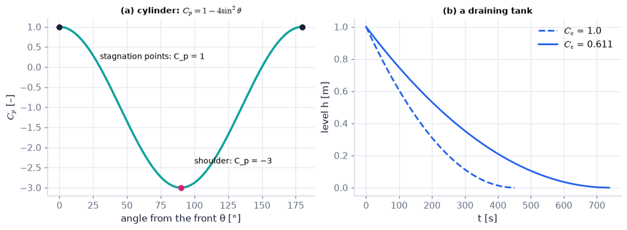

```python
th = np.linspace(0, np.pi, 181)                                     # angle round the cylinder from the front [rad]
us, vs = ch03.cylinder_flow(-(1 + 1e-9)*np.cos(th), (1 + 1e-9)*np.sin(th), 1.0, 1.0)   # velocity on the surface r = a (front at θ = 0) [m/s]
p_s = 0.0 + 0.5*1.0*(1.0**2 - (us**2 + vs**2))                      # Bernoulli (4.19) from the free stream, ρ = 1 [Pa]
Cp = ch04.pressure_coefficient(p_s, 0.0, 1.0, 1.0)                   # C_p = (p − p∞)/(½ρU²)
fig, (a, b) = plt.subplots(1, 2, figsize=(10, 3.6))                                        # the figure and its panels
a.plot(np.rad2deg(th), Cp, color=COLORS["teal"], lw=2.5)              # the surface pressure
a.plot([0, 180], [1, 1], "o", color=COLORS["ink"]); a.plot([90], [-3], "o", color=COLORS["rose"])   # draw the data
a.annotate("stagnation points: C_p = 1", (0, 1), (30, 0.2), fontsize=9)                             # a labelled arrow
a.annotate("shoulder: C_p = −3", (90, -3), (100, -2.4), fontsize=9)                                 # a labelled arrow
a.set_xlabel("angle from the front θ [°]"); a.set_ylabel("$C_p$ [–]")                               # axis labels with units
a.set_title("(a) cylinder: $C_p=1-4\\sin^2\\theta$", fontsize=10)                                   # the panel's message
for Cc, ls in ((1.0, "--"), (0.611, "-")):                          # rounded vs sharp-edged hole
    d = ch04.tank_drain(1.0, 1.0, 1e-3, Cc=Cc, t_eval=np.linspace(0, 740, 300))   # h(t) for a 1 m² tank, 10 cm² hole
    b.plot(d["t"], d["h"], ls, color=COLORS["blue"], label=f"$C_c$ = {Cc}")                         # draw the data
b.set_xlabel("t [s]"); b.set_ylabel("level h [m]"); b.legend(); b.set_title("(b) a draining tank", fontsize=10)  # axis labels with units
savefig(fig, "ch04", "bernoulli_uses"); plt.show()                                        # save the PNG to outputs/ch04, then draw
```

**What you see.** (a) The pressure is highest where the flow stops and lowest where it is fastest; (b) a parabola in t that reaches zero sooner without the vena contracta.

**How to read it.** (a) $C_p=1-(U/U_\infty)^2$ is $\tfrac12U^2+gz+p/\rho=$ const *(4.19)* in dimensionless form; (b) the outflow slows as √h, so the level falls fast at first and slowly at the end (451.5 s to empty with $C_c$ = 1, 739 s with 0.611).

**What would change if…** …viscosity added: behind a real cylinder the flow separates and the pressure never recovers to C_p = 1 (Ch. 9) — Bernoulli fails where friction acts.

**What would change if…** …we asked for momentum at every *point* rather than along one streamline in frictionless flow? We would need the stresses on a tiny cube — pressure and friction together — and Newton's law for it: Cauchy's equation (C06). Bernoulli's *general* forms return in C11 and C12, where the `which_bernoulli` explainer compares all four.

### 🧩 Newton's law for a fluid particle: Cauchy's equation (4.24) `C06`

*The question:* A small cube of fluid is pushed by its neighbours on six faces and pulled by gravity. Before we know anything about what kind of fluid it is, what is F = ma for it?

*In one line:* $\rho\frac{Du_j}{Dt}=\rho g_j+\frac{\partial\tau_{ij}}{\partial x_i}$ *(4.24)*

#### The problem in plain words

The integral law (4.17), $\frac{d}{dt}\int_{V^*}\rho\mathbf u\,dV+\int_{A^*}\rho\mathbf u(\mathbf u-\mathbf b)\cdot\mathbf n\,dA=\int_{V^*}\rho\mathbf g\,dV+\int_{A^*}\mathbf f\,dA$ needs a box; to predict a flow everywhere we need the law at every point — a differential equation for u. We can get it without any knowledge of how stress depends on motion: that part comes later (C07). The result holds for water, air, honey, even a steel beam.

#### The idea

```
(4.14) for a material volume  →  Gauss on BOTH surface integrals  →  one volume integral = 0 for every volume
                              →  localise  →  flux form (4.22)  →  subtract u_j × continuity  →  ρ Du_j/Dt = ρ g_j + ∂τ_ij/∂x_i
mass × acceleration          =   gravity   +   net push of the neighbours (divergence of stress, FIRST index)
```

*The numbered equations in the sketch:* $\int_{V(t)}\frac{\partial}{\partial t}(\rho\mathbf u)dV+\int_{A(t)}\rho\mathbf u(\mathbf u\cdot\mathbf n)dA=\int_{V(t)}\rho\mathbf g\,dV+\int_{A(t)}\mathbf f\,dA$ *(4.14)* · $\frac{\partial}{\partial t}(\rho u_j)+\frac{\partial}{\partial x_i}(\rho u_iu_j)=\rho g_j+\frac{\partial\tau_{ij}}{\partial x_i}$ *(4.22)*

> 🔁 **Tools from earlier chapters used here** (see `knowledge/primers.md`)
- **stress tensor τ_ij, first index = face** — $\tau_{ij}$ is the j-component of the force per area on a face whose normal points along $x_i$ (Ch. 1 P05, R03).

> 📎 **Primer — tensor divergence over the first index.** `P118` · The net surface force per unit volume on a small cube is the divergence of the stress. Because the traction on a face with normal n is $f_j=n_i\tau_{ij}$ (first index = face), Gauss' theorem turns $\oint n_i\tau_{ij}dA$ into $\int\partial\tau_{ij}/\partial x_i\,dV$ — the derivative acts on the **first** index. For a symmetric τ it does not matter; for a non-symmetric one it does, and C07 has not yet proved τ symmetric. (Ch. 2's `tensor_divergence` differentiated the second index by default; here we pass `index=0`.)

```python
tau_ns = lambda x, t: np.array([[0.0, x[0], 0.0], [0.0, 0.0, 0.0], [0.0, 0.0, 0.0]])   # τ12 = x1, not symmetric [Pa]
first, second = ch04.divergence_first_index_demo(tau_ns, np.array([0.3, 0.2, 0.1]))   # ∂τ_ij/∂x_i and ∂τ_ij/∂x_j
print(first, second)                                                                   # [0. 1. 0.] vs [0. 0. 0.]: different
```

```
[0. 1. 0.] [0. 0. 0.]
```

#### 🧮 Derivation — Cauchy's equation: (4.14) → (4.20a, b) → (4.21) → (4.22) → (4.23) → (4.24) `D07` (Eq. 4.24)

**What we want to show.** Newton's law for a single fluid particle, valid for any continuum, before we know how stress depends on the motion.

**Assumptions.** ρu_iu_j and τ_ij continuously differentiable (steps 2–3); every material volume (step 5); continuity holds (step 9).

**The plan.**

1. Turn both surface integrals into volume integrals with Gauss (first index!).
2. Localise.
3. Expand the flux form and recognise continuity and D/Dt.

**Tools we use** (each explained before this point): Gauss' theorem per component (R02) · traction $f_j=n_i\tau_{ij}$ (2.15) (R03) · tensor divergence over the first index (primer in C06) · localisation lemma (N07) · product rule (ch01 P38) · material derivative (3.5), $\frac{DF}{Dt}=\frac{\partial F}{\partial t}+\mathbf u\cdot\nabla F$.

**We start from**

$$ \text{(4.14) for component j:}\ \int_V\frac{\partial(\rho u_j)}{\partial t}dV+\int_A\rho u_j(u_in_i)\,dA=\int_V\rho g_j\,dV+\int_Af_j\,dA $$

*In words:* the momentum balance of a material volume.

**Step 1 of 10 — Start from the momentum law, component j.**

$$ \int_V\frac{\partial(\rho u_j)}{\partial t}dV+\int_A\rho u_ju_in_i\,dA=\int_V\rho g_j\,dV+\int_Af_j\,dA $$

- *Why we can do this:* (4.14), $\int_{V(t)}\frac{\partial}{\partial t}(\rho\mathbf u)dV+\int_{A(t)}\rho\mathbf u(\mathbf u\cdot\mathbf n)dA=\int_{V(t)}\rho\mathbf g\,dV+\int_{A(t)}\mathbf f\,dA$ written with indices; j is a free index (one equation per direction), i is summed in u_in_i.
- *In words:* Momentum in direction j of a material volume.

**Step 2 of 10 — Apply Gauss to the momentum flux.**

$$ \int_A\rho u_ju_in_i\,dA=\int_V\frac{\partial}{\partial x_i}(\rho u_iu_j)\,dV $$

- *Why we can do this:* For fixed j, Q_i = ρu_iu_j is a vector field; Gauss (2.30), $\int_V\nabla\cdot\mathbf Q\,dV=\int_A\mathbf Q\cdot\mathbf n\,dA$ contracts its index i with n_i. This is (4.20a), $\int_{A}\rho\mathbf u(\mathbf u\cdot\mathbf n)dA=\int_{V}\frac{\partial}{\partial x_i}(\rho u_iu_j)dV$ — the line above.
- *In words:* Momentum carried out through the skin = its flux divergence inside.

**Step 3 of 10 — Apply Gauss to the surface force.**

$$ \int_Af_j\,dA=\int_An_i\tau_{ij}\,dA=\int_V\frac{\partial\tau_{ij}}{\partial x_i}dV $$

- *Why we can do this:* Traction f_j = n_iτ_ij (R03, first index = face); for fixed j, Q_i = τ_ij is a vector and Gauss differentiates the first index. This is (4.20b), $\int_{A}n_i\tau_{ij}dA=\int_{V}\frac{\partial\tau_{ij}}{\partial x_i}dV$ — the line above.
- *In words:* The pushes on the skin add up to the stress divergence inside.

**Step 4 of 10 — Collect under one integral.**

$$ \int_V\Big\{\frac{\partial(\rho u_j)}{\partial t}+\frac{\partial(\rho u_iu_j)}{\partial x_i}-\rho g_j-\frac{\partial\tau_{ij}}{\partial x_i}\Big\}dV=0 $$

- *Why we can do this:* All four terms are now integrals over the same V (linearity). This is (4.21), $\int_{V}\Big\{\frac{\partial}{\partial t}(\rho u_j)+\frac{\partial}{\partial x_i}(\rho u_iu_j)-\rho g_j-\frac{\partial\tau_{ij}}{\partial x_i}\Big\}dV=0$ — the line above.
- *In words:* One integrand, zero integral.

**Step 5 of 10 — Localise.**

$$ \frac{\partial(\rho u_j)}{\partial t}+\frac{\partial(\rho u_iu_j)}{\partial x_i}=\rho g_j+\frac{\partial\tau_{ij}}{\partial x_i} $$

- *Why we can do this:* The integral vanishes for every material volume and the integrand is continuous, so it vanishes everywhere (localisation lemma, D02). This is the flux form (4.22), $\frac{\partial}{\partial t}(\rho u_j)+\frac{\partial}{\partial x_i}(\rho u_iu_j)=\rho g_j+\frac{\partial\tau_{ij}}{\partial x_i}$.
- *In words:* Momentum conservation at a point, in flux form.

**Step 6 of 10 — Expand the time derivative.**

$$ \frac{\partial(\rho u_j)}{\partial t}=\rho\frac{\partial u_j}{\partial t}+u_j\frac{\partial\rho}{\partial t} $$

- *Why we can do this:* Product rule (P38). We are separating "velocity changes" from "density changes".
- *In words:* Momentum changes because velocity or density changes.

**Step 7 of 10 — Expand the flux divergence.**

$$ \frac{\partial(\rho u_iu_j)}{\partial x_i}=u_j\frac{\partial(\rho u_i)}{\partial x_i}+\rho u_i\frac{\partial u_j}{\partial x_i} $$

- *Why we can do this:* Product rule with the two factors ρu_i and u_j.
- *In words:* The flux changes because the mass flux spreads or because the velocity varies along the flow.

**Step 8 of 10 — Group the terms multiplying u_j.**

$$ \rho\frac{\partial u_j}{\partial t}+u_j\Big[\frac{\partial\rho}{\partial t}+\frac{\partial(\rho u_i)}{\partial x_i}\Big]+\rho u_i\frac{\partial u_j}{\partial x_i} $$

- *Why we can do this:* Adding steps 6 and 7 and factoring u_j out of two terms. This is the middle of (4.23), $\frac{\partial(\rho u_j)}{\partial t}+\frac{\partial(\rho u_iu_j)}{\partial x_i}=\rho\frac{Du_j}{Dt}$.
- *In words:* A bracket appears that we have seen before.

**Step 9 of 10 — Drop the bracket: it is continuity.**

$$ \frac{\partial(\rho u_j)}{\partial t}+\frac{\partial(\rho u_iu_j)}{\partial x_i}=\rho\Big(\frac{\partial u_j}{\partial t}+u_i\frac{\partial u_j}{\partial x_i}\Big) $$

- *Why we can do this:* The bracket is the continuity equation (4.7), $\frac{\partial\rho}{\partial t}+\frac{\partial}{\partial x_i}(\rho u_i)=0$, which holds at every point.
- *In words:* With mass conserved, only the velocity changes remain.

**Step 10 of 10 — Recognise the particle acceleration.**

$$ \rho\frac{Du_j}{Dt}=\rho g_j+\frac{\partial\tau_{ij}}{\partial x_i} $$

- *Why we can do this:* (3.5), $\frac{DF}{Dt}=\frac{\partial F}{\partial t}+\mathbf u\cdot\nabla F$ with F = u_j: ∂u_j/∂t + u_i∂u_j/∂x_i = Du_j/Dt; put into (4.22), $\frac{\partial}{\partial t}(\rho u_j)+\frac{\partial}{\partial x_i}(\rho u_iu_j)=\rho g_j+\frac{\partial\tau_{ij}}{\partial x_i}$. This is (4.24), $\rho\frac{Du_j}{Dt}=\rho g_j+\frac{\partial\tau_{ij}}{\partial x_i}$ — the line above.
- *In words:* Mass × acceleration = weight + net push of the neighbours.

**Result**

$$ \rho\frac{Du_j}{Dt}=\rho g_j+\frac{\partial\tau_{ij}}{\partial x_i} $$

*In words:* Cauchy's equation of motion.

**What it means.** Newton's law for water, air, honey or steel; 6 equations for 13 unknowns until a constitutive law (C07) ties τ to the motion. The flux form (4.22), $\frac{\partial}{\partial t}(\rho u_j)+\frac{\partial}{\partial x_i}(\rho u_iu_j)=\rho g_j+\frac{\partial\tau_{ij}}{\partial x_i}$ is what finite-volume codes conserve.

**Check it.** Units N/m³ ✓. Fluid at rest, τ = −pδ: 0 = ρg − ∇p — hydrostatics ✓. Solid-body rotation (C06 worked example): −100 = 0 − 100 N/m³ radially ✓.

> ⚠️ **Common confusion (traps in `D07`):** Differentiating the second index of τ (the book's prose after (4.24), $\rho\frac{Du_j}{Dt}=\rho g_j+\frac{\partial\tau_{ij}}{\partial x_i}$ writes ∂τ_ij/∂x_j — harmless only because τ turns out symmetric, proved after (4.24)). Missing the continuity bracket (subtract u_j × continuity, not u_j × ∇·u).

📝 **Note.** **The book's (4.20a)** `N33` — D07's step 2: Gauss applied to each component j of the momentum flux, the normal's index contracted.

$$ \int_{A}\rho\mathbf u(\mathbf u\cdot\mathbf n)dA=\int_{V}\nabla\cdot(\rho\mathbf u\mathbf u)dV=\int_{V}\frac{\partial}{\partial x_i}(\rho u_iu_j)dV \qquad \text{(4.20a)} $$

📝 **Note.** **The book's (4.20b)** `N34` — Step 3: the same for the surface force — the first index again.

$$ \int_{A}\mathbf f\,dA=\int_{A}n_i\tau_{ij}dA=\int_{V}\frac{\partial\tau_{ij}}{\partial x_i}dV \qquad \text{(4.20b)} $$

📝 **Note.** **The book's (4.21)** `N35` — Step 4: everything under one integral.

$$ \int_{V}\Big\{\frac{\partial}{\partial t}(\rho u_j)+\frac{\partial}{\partial x_i}(\rho u_iu_j)-\rho g_j-\frac{\partial\tau_{ij}}{\partial x_i}\Big\}dV=0 \qquad \text{(4.21)} $$

📝 **Note.** **The conservative (flux) form** `N36` — Step 5 (localisation) gives the form finite-volume codes discretise (Ch. 10):

$$ \frac{\partial}{\partial t}(\rho u_j)+\frac{\partial}{\partial x_i}(\rho u_iu_j)=\rho g_j+\frac{\partial\tau_{ij}}{\partial x_i} \qquad \text{(4.22)} $$

📝 **Note.** **The bracket is continuity** `N37` — Steps 6–8 expand the left side; the bracket is the continuity equation $\frac{\partial\rho}{\partial t}+\nabla\cdot(\rho\mathbf u)=0$ *(4.7)* and vanishes. The sympy cell below shows the flux form minus $\rho\,Du_j/Dt$ is exactly $u_j$ × (continuity).

$$ \frac{\partial}{\partial t}(\rho u_j)+\frac{\partial}{\partial x_i}(\rho u_iu_j)=\rho\frac{\partial u_j}{\partial t}+u_j\Big[\frac{\partial\rho}{\partial t}+\frac{\partial}{\partial x_i}(\rho u_i)\Big]+\rho u_i\frac{\partial u_j}{\partial x_i}=\rho\frac{Du_j}{Dt} \qquad \text{(4.23)} $$

```python
x, y, z, t = sp.symbols('x y z t')                                   # coordinates and time
r = sp.Function('rho')(x, y, z, t)                                   # an arbitrary density field
Uf = [sp.Function(f'u{i}')(x, y, z, t) for i in (1, 2, 3)]           # an arbitrary velocity field
diff_ = ch04.conservative_to_advective_sym(r, Uf, (x, y, z), t)      # flux form − ρ Du_j/Dt, one component at a time
cont = sp.diff(r, t) + sum(sp.diff(r*Uf[i], v) for i, v in enumerate((x, y, z)))   # ∂ρ/∂t + ∂(ρu_i)/∂x_i
print([sp.simplify(d - Uf[j]*cont) for j, d in enumerate(diff_)])    # [0, 0, 0]: the difference is u_j × continuity
```

```
[0, 0, 0]
```

> ⚠️ **Book slip (index):** the sentence after (4.24) calls the net surface force ∂τ_ij/∂x_j. The equation itself, $\rho\frac{Du_j}{Dt}=\rho g_j+\frac{\partial\tau_{ij}}{\partial x_i}$ *(4.24)*, contracts the first index. The two agree only because τ is symmetric — proved in C07, *after* (4.24).

📝 **Note.** **The ledger, first row** `N02` — Continuity (1 equation), Cauchy (3) and two thermodynamic equations of state give 6 equations; the unknowns are ρ (1), u_j (3) and τ_ij (9): 13. Not solvable yet — a *constitutive law* must tie τ to the motion (C07).

```python
c = ch04.closure_count("cauchy")                                     # equations and unknowns after Cauchy's equation
ledger.loc["cauchy"] = [c["equations"], c["unknowns"]]                # fill the first row of the §4.1 table
print(c["equation_names"], c["unknown_names"])                       # what is being counted
print(ledger)                                                        # cauchy: 6 equations, 13 unknowns
```

```
['continuity (4.7)', 'Cauchy (4.24) ×3', 'thermodynamic equation ×2'] ['ρ', 'u_j ×3', 'τ_ij ×9']
               equations  unknowns
cauchy                 6        13
navier_stokes          0         0
barotropic             0         0
full                   0         0
```

> 🔁 **Tools from earlier chapters used here** (see `knowledge/primers.md`)
- **rigid (solid-body) rotation and its pressure** — $\mathbf u=\boldsymbol\Omega\times\mathbf x$ turns every element without deforming it (Ch. 3 P101).

#### ✏️ Tiny example: water spinning like a solid body (Ω = 1 rad/s) at r = 0.1 m

Velocity $u_\varphi=\Omega r=0.1$ m/s; every particle moves on a circle, so its acceleration is centripetal: $\mathbf a=-\Omega^2r\,\mathbf e_R=-0.1$ m/s², ρa = −100 N/m³. The pressure that holds it on the circle is $p=\rho\Omega^2R^2/2-\rho gz$ (plus a constant): $-\partial p/\partial R=-\rho\Omega^2R=-100$ N/m³ radially, and $-\partial p/\partial z=+\rho g$ vertically balancing gravity $\rho g_z=-\rho g$. No viscous stress (a rigid motion has S = 0, Ch. 3). So $\rho\frac{Du_j}{Dt}=\rho g_j+\frac{\partial\tau_{ij}}{\partial x_i}$ *(4.24)* with $\tau_{ij}=-p\delta_{ij}$ reads −100 = 0 + (−100) radially and 0 = −9810 + 9810 vertically ✓.

```python
u_sb, p_sb = ch04.exact_field("solid_body", Omega=1.0, rho=1000.0)   # u = Ω × x and p = ρΩ²R²/2 − ρgz
tau_sb = lambda x, t: -p_sb(x, t)*np.eye(3)                          # stress of a fluid with no viscous part [Pa]
x0 = np.array([0.1, 0.0, 0.0])                                       # a point 0.1 m from the axis
gvec = np.array([0.0, 0.0, -9.81])                                   # gravity [m/s²]
T = ch04.cauchy_terms(1000.0, u_sb, tau_sb, gvec, x0, 0.0, h=1e-4)    # the three terms of (4.24) per unit volume [N/m³]
print(T.inertia, T.body, T.stress_divergence, T.residual)            # (−100, 0, 0), (0, 0, −9810), (−100, 0, 9810), ≈ 0
print(ch04.momentum_conservative_residual(1000.0, u_sb, tau_sb, gvec, x0, 0.0))   # the flux form (4.22) balances too
```

```
[-100.    0.    0.] [    0.     0. -9810.] [-100.    0. 9810.] [-0.  0.  0.]
[-0.  0.  0.]
```

**What does the code above do?**

1. The exact solid-body field and its pressure.
2. The stress of a fluid with no viscous part, $\tau_{ij}=-p\delta_{ij}$.
3. The three terms of $\rho\frac{Du_j}{Dt}=\rho g_j+\frac{\partial\tau_{ij}}{\partial x_i}$ *(4.24)* at a point — mass × acceleration equals gravity plus the net push.
4. The flux form $\frac{\partial}{\partial t}(\rho u_j)+\frac{\partial}{\partial x_i}(\rho u_iu_j)=\rho g_j+\frac{\partial\tau_{ij}}{\partial x_i}$ *(4.22)* gives the same balance (continuity holds).

```python
div = np.zeros(3)                                                    # ∂τ_ij/∂x_i, built by hand
for i in range(3):                                                   # differentiate row i along x_i
    e = np.eye(3)[i]*1e-4                                            # a small step along x_i [m]
    div += (tau_sb(x0 + e, 0)[i, :] - tau_sb(x0 - e, 0)[i, :]) / 2e-4
print(div)                                                           # (−100, 0, 9810) N/m³
assert np.allclose(div, T.stress_divergence, rtol=1e-6)              # the library contracts the FIRST index too
first, second = ch04.divergence_first_index_demo(tau_ns, np.array([0.3, 0.2, 0.1]))   # the primer's non-symmetric τ
assert not np.allclose(first, second)                                # the second-index version would be a different force
```

```
[-100.    0. 9810.]
```

**What does the code above do?** It differentiates each row i of τ along x_i by hand (the first-index divergence), matches `cauchy_terms`, and confirms that for the non-symmetric τ of the primer the second-index divergence would give a different force.

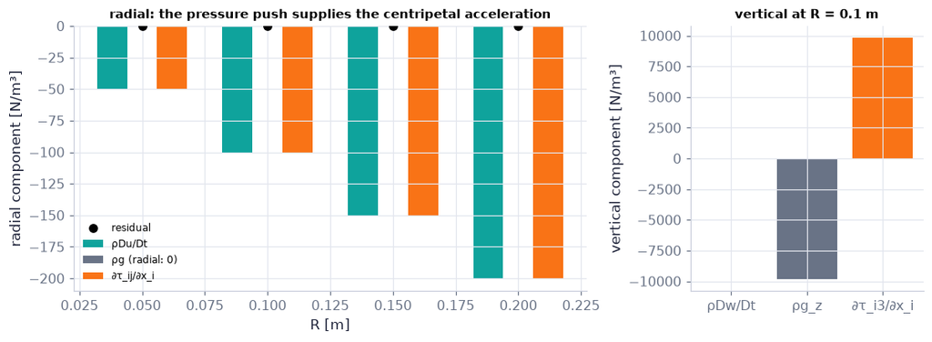

```python
Rs = np.array([0.05, 0.10, 0.15, 0.20])                               # distances from the axis [m]
terms = [ch04.cauchy_terms(1000.0, u_sb, tau_sb, gvec, np.array([R, 0, 0]), 0.0) for R in Rs]   # (4.24) at each point
fig, (a, b) = plt.subplots(1, 2, figsize=(10, 3.6), gridspec_kw=dict(width_ratios=[2.2, 1]))        # the figure and its panels
w = 0.012                                                             # bar width [m]
a.bar(Rs - w, [T_.inertia[0] for T_ in terms], w, color=COLORS["teal"], label="ρDu/Dt")          # mass × acceleration
a.bar(Rs, [T_.body[0] for T_ in terms], w, color=COLORS["muted"], label="ρg (radial: 0)")         # gravity has no radial part
a.bar(Rs + w, [T_.stress_divergence[0] for T_ in terms], w, color=COLORS["orange"], label="∂τ_ij/∂x_i")   # net push
a.plot(Rs, [T_.inertia[0] - T_.body[0] - T_.stress_divergence[0] for T_ in terms], "ko", label="residual")  # draw the data
a.set_xlabel("R [m]"); a.set_ylabel("radial component [N/m³]"); a.legend(fontsize=8)                # axis labels with units
a.set_title("radial: the pressure push supplies the centripetal acceleration", fontsize=10)         # the panel's message
T1 = terms[1]                                                         # the point R = 0.1 m
b.bar(["ρDw/Dt", "ρg_z", "∂τ_i3/∂x_i"], [T1.inertia[2], T1.body[2], T1.stress_divergence[2]],       # draw the data
      color=[COLORS["teal"], COLORS["muted"], COLORS["orange"]])  # one colour per term
b.set_ylabel("vertical component [N/m³]"); b.set_title("vertical at R = 0.1 m", fontsize=10)        # axis labels with units
savefig(fig, "ch04", "cauchy_bars"); plt.show()                                        # save the PNG to outputs/ch04, then draw
```

**What you see.** Teal and orange bars of equal length growing with R, nothing grey radially, residual dots on zero; vertically a grey and an orange bar of equal size and opposite sign.

**How to read it.** The inward push of the pressure (orange) supplies exactly the centripetal acceleration (teal); vertically the pressure holds the water up against gravity.

**What would change if…** …Ω doubled: both radial bars grow four times (Ω²); the vertical balance is unchanged.

**What would change if…** …we knew how τ depends on the motion? Then the 13 unknowns collapse to 5 (ρ, p, u_j) and Cauchy's equation becomes a closed PDE for the velocity. The simplest possible law — stress linear in the strain rate, the same in every direction — is the Newtonian fluid (C07).

## 4.5 Constitutive Equation for a Newtonian Fluid

**What is this section about?** Cauchy's equation needs a rule for the stress. We show first that the stress tensor is symmetric, then build the simplest law allowed by physics — stress linear in the rate of strain and the same in every direction — and find it has only two material constants, μ and the bulk viscosity μ_v.

> 🔁 **Recap — Only the strain rate can create viscous stress** (Ch. 3 §3.3–3.4). Viscous stress must be the same for every observer moving at constant velocity (Galilean invariance, Ch. 3 §3.3), so it cannot depend on u itself — only on the velocity gradient G. And of $\frac{\partial u_i}{\partial x_j}=S_{ij}+\tfrac12R_{ij}$ *(Eq. 3.11)* only the strain-rate tensor S deforms an element; the rotation part R describes a rigid spin, which deforms nothing (Ch. 3 §3.4: a rigid motion U + Ω × x has S = 0). So the viscous stress is a function of S alone and vanishes when S = 0.

```python
G_rigid = kinematics.velocity_gradient_preset("solid_body_rotation", Gamma=2.0, dim=3)   # G of a rigid spin (antisymmetric) [1/s]
print(tensors.strain_rate_tensor(G_rigid))                           # S = 0: no deformation
print(ch04.viscous_stress(G_rigid, mu=1e-3))                         # σ = 0: no viscous stress [Pa]
```

```
[[0. 0. 0.]
 [0. 0. 0.]
 [0. 0. 0.]]
[[0. 0. 0.]
 [0. 0. 0.]
 [0. 0. 0.]]
```

**What does the code above do?**

A rigid rotation has no strain rate and so no viscous stress: two 3 × 3 zero matrices.

> 🔁 **Recap — Non-Newtonian fluids exist** (Ch. 1 §1.3). Paint, ketchup, blood, polymer melts and mud do not obey a linear stress–strain-rate law: they shear-thin, have a yield stress or remember their past (Ch. 1 §1.3 named Bingham and Maxwell materials). This chapter treats the Newtonian fluid only; Ch. 16 returns to the others.

### 🧩 How a fluid decides its stress: the Newtonian law (4.31) `C07`

*The question:* Honey between two plates: slide the top plate and it resists; squeeze the plates together and it resists differently; spin the whole sandwich and it does not resist at all. What rule turns "how the fluid deforms" into "what stress it carries"?

*In one line:* $\tau_{ij}=-p\,\delta_{ij}+2\mu S_{ij}+\lambda S_{mm}\delta_{ij}$ *(4.31)*

#### The problem in plain words

Newton's law $\tau=\mu\,du/dy$ *(1.3)* covers one flow: parallel layers sliding. A real flow shears, stretches and swells in all directions at once, and Cauchy's equation needs all nine stress components. We want the general rule, as simple as physics allows, with as few material constants as possible — the one used for water and air in every later chapter, in CFD codes and in the eddy-viscosity models of turbulence.

#### The idea

```
motion  G = ∂u_i/∂x_j  →  keep only S (R05)  →  linear: σ_ij = K_ijmn S_mn (81 numbers)
                       →  isotropic: K = λδδ + μδδ + γδδ (3 numbers)  →  symmetric: 2 numbers
τ_ij = −p δ_ij  +  2μ S_ij  +  λ S_mm δ_ij                                      (4.31)
       static     shear/stretch  swelling
```

*The numbered equations in the sketch:* $\tau_{ij}=-p\,\delta_{ij}+2\mu S_{ij}+\lambda S_{mm}\delta_{ij}$ *(4.31)*

📝 **Note.** **Constitutive equation** `N39` — A material's rule linking stress to deformation; the *Newtonian* fluid has the simplest linear one. Non-Newtonian rules: Ch. 16.

📝 **Note.** **The stress tensor is symmetric** `N38` — so it has six independent components. The book leaves the proof to an exercise; the derivation below writes it out: an unequal pair τ₁₂ ≠ τ₂₁ would spin a small cube faster and faster as it shrinks. The only exception is a fluid with body *couples* (torques per unit mass, e.g. polarised molecules in an electric field).

$$ \tau_{ij}=\tau_{ji} \qquad \text{(4.25)} $$

> 🔁 **Tools from earlier chapters used here** (see `knowledge/primers.md`)
- **exponent rules** — $h^5/h^3=h^2$, so a torque ∝ h³ over an inertia ∝ h⁵ grows as 1/h² (Ch. 1 P43); torque and moment of inertia were primed in C04 above (P116).

#### 🧮 Derivation — The stress tensor is symmetric, (4.25) `D08` (Eq. 4.25)

**What we want to show.** Show τ₁₂ = τ₂₁ (and its cyclic partners): an unequal pair would spin a tiny cube infinitely fast. The book states the result and leaves the proof to Exercise 4.30.

**Assumptions.** No body couples (torques per unit mass) (step 8); stresses smooth, so they vary by O(h) across the cube (step 3).

**The plan.**

1. Torque of the shear pairs about the x₃ axis.
2. Show every other torque is of higher order.
3. Moment of inertia.
4. Angular acceleration as h → 0.

**Tools we use** (each explained before this point): Torque, moment arm and moment of inertia (primer in C04) · $d\mathbf H/dt=\mathbf M$ (4.64) · limits and orders of smallness (ch02 P68).

**We start from**

$$ \text{A cube of fluid of side h centred at the origin, stresses τ\_ij at its centre} $$

*In words:* the smallest piece of fluid we can apply the rotational form of Newton's law to.

**Step 1 of 8 — Take a small cube and an axis.**

$$ dV=h^3,\qquad\text{axis }x_3\text{ through the centre} $$

- *Why we can do this:* Symmetry is a statement about a point, so we study an element and let it shrink; any axis will do, we choose x₃.
- *In words:* A tiny cube, spinning (or not) about a vertical line.

**Step 2 of 8 — Torque of the shear pairs.**

$$ M_3=\tau_{12}h^2\cdot h-\tau_{21}h^2\cdot h=(\tau_{12}-\tau_{21})h^3 $$

- *Why we can do this:* On the faces x₁ = ±h/2 (area h²) the tractions ±τ₁₂ act along x₂ with arms ±h/2: two equal counterclockwise torques τ₁₂h³/2. The faces x₂ = ±h/2 carry ±τ₂₁ along x₁: clockwise.
- *In words:* The two shear pairs twist the cube in opposite senses.

**Step 3 of 8 — Show other torques are smaller.**

$$ M_3=(\tau_{12}-\tau_{21})h^3+O(h^4) $$

- *Why we can do this:* Normal stresses and gravity act through the face or mass centres (no arm); their variation across the cube, O(h), adds torques O(h⁴) and O(h⁵).
- *In words:* Only the shear imbalance matters for a small cube.

**Step 4 of 8 — Compute the moment of inertia.**

$$ I_{33}=\int\rho(x_1^2+x_2^2)\,dV=\rho\frac{h^5}{6} $$

- *Why we can do this:* Each of the two integrals is ρh²·∫x²dx over [−h/2, h/2] = ρh²·h³/12; added: ρh⁵/6 (primer).
- *In words:* The cube's resistance to spinning shrinks like h⁵.

**Step 5 of 8 — Apply the rotational law.**

$$ I_{33}\,\dot\Omega_3=M_3 $$

- *Why we can do this:* Rate of change of angular momentum = torque ((4.64), $d\mathbf H/dt=\mathbf M$) about the axis through the centre of mass.
- *In words:* Torque = moment of inertia × angular acceleration.

**Step 6 of 8 — Solve for the angular acceleration.**

$$ \dot\Omega_3=\frac{6(\tau_{12}-\tau_{21})}{\rho h^2}+O\Big(\frac1h\Big) $$

- *Why we can do this:* Divide step 3 by step 4 (exponent rules: h³/h⁵ = h⁻²).
- *In words:* The spin-up grows like 1/h².

**Step 7 of 8 — Let the cube shrink.**

$$ h\to0:\quad\dot\Omega_3\to\infty\ \text{unless}\ \tau_{12}=\tau_{21} $$

- *Why we can do this:* A fluid element cannot spin up infinitely fast; the only finite limit is a zero imbalance (orders of smallness, P68).
- *In words:* An unequal pair would make every point whirl without bound.

**Step 8 of 8 — Repeat for the other axes.**

$$ \tau_{ij}=\tau_{ji} $$

- *Why we can do this:* Relabelling the axes gives τ₂₃ = τ₃₂ and τ₃₁ = τ₁₃. With body couples (torque per unit mass) a term ∝ h³ could balance — the book's exception. This is (4.25), $\tau_{ij}=\tau_{ji}$ — the line above.
- *In words:* The stress tensor has six independent components.

**Result**

$$ \tau_{ij}=\tau_{ji} $$

*In words:* the stress tensor is symmetric.

**What it means.** Six stress components, not nine; the traction rule f_j = n_iτ_ij can be read with either index; internal torques cancel in the angular-momentum budget (N83). Broken only by body couples (ferrofluids in fields).

**Check it.** Units: Pa/((kg/m³)·m²) = (kg m⁻¹ s⁻²)/(kg m⁻¹) = 1/s² ✓. Numbers: 1 Pa imbalance, water, h = 1 cm → 60 rad/s², h = 0.1 mm → 6×10⁵ rad/s² (C07 code, slope −2) ✓.

> ⚠️ **Common confusion (traps in `D08`):** Including normal stresses in the torque (they have no arm about the centre). Forgetting the 1/12 in the moment of inertia. Arguing "equilibrium" — the argument works for accelerating fluid too.

> 🔁 **Tools from earlier chapters used here** (see `knowledge/primers.md`)
- **log–log slope and observed_order** — a power law $y\propto h^k$ is a straight line of slope k on log–log axes; `observed_order` fits k (Ch. 1 P13).
- **np.logspace** — `np.logspace(-4, -1, 7)` = 7 values evenly spaced in the exponent, 10⁻⁴ … 10⁻¹ (Ch. 1 P06).

```python
h = np.logspace(-4, -1, 7)                                           # cube sides from 0.1 mm to 10 cm [m]
alpha = ch04.cube_spin_acceleration(1.0, 0.0, 1000.0, h)             # 6(τ12 − τ21)/(ρh²) for a 1 Pa imbalance in water [rad/s²]
print(np.c_[h, alpha])                                                # 60 rad/s² at 1 cm, 6×10⁵ at 0.1 mm
print(round(observed_order(h, alpha), 3))                            # slope −2: it grows as 1/h²
```

```
[[     0.0001 600000.    ]
 [     0.0003  60000.    ]
 [     0.001    6000.    ]
 [     0.0032    600.    ]
 [     0.01       60.    ]
 [     0.0316      6.    ]
 [     0.1         0.6   ]]
-2.0
```

**What does the code above do?**

1. The angular acceleration a 1 Pa stress imbalance would give a water cube of side h.
2. Its log–log slope: it grows as 1/h² — no finite imbalance can survive at a point.

📝 **Note.** **At rest** `N40` — a fluid's stress is the same on every plane (isotropic, Ch. 1 §1.6), and the only isotropic second-order tensor is $\delta_{ij}$ (Ch. 2 §2.5). p is the thermodynamic pressure (e.g. p = ρRT); the minus sign because tension counts positive. Traction on any plane: −pn (`tensors.traction(ch04.static_stress(1e5), n)` = −10⁵ n for any unit n).

$$ \tau_{ij}=-p\,\delta_{ij} \qquad \text{(4.26)} $$

📝 **Note.** **Moving fluid** `N41` — add a viscous part σ_ij that vanishes at rest. p stays the thermodynamic pressure because fluid particles are in local equilibrium (Ch. 1 §1.8).

> ⚠️ The book calls σ the "deviatoric" stress; it is traceless (a true deviator) only when μ_v = 0 or ∇·u = 0, since its trace is 3μ_v∇·u (shown after D10).

$$ \tau_{ij}=-p\,\delta_{ij}+\sigma_{ij} \qquad \text{(4.27)} $$

> 🔁 **Tools from earlier chapters used here** (see `knowledge/primers.md`)
- **np.einsum index strings** — `np.einsum('ijmn,mn->ij', K, S)` sums over the repeated letters m, n (Ch. 2 P62).

📝 **Note.** **Most general linear law with σ = 0 when S = 0** `N42` — K has 3⁴ = 81 components (each of the nine σ's may depend on each of the nine S's); code: `ch04.linear_stress(K, S)` = `np.einsum('ijmn,mn->ij', K, S)`.

$$ \sigma_{ij}=K_{ijmn}S_{mn} \qquad \text{(4.28)} $$

> 🔁 **Tools from earlier chapters used here** (see `knowledge/primers.md`)
- **random rotations and transform_tensor** — `tensors.random_rotation(rng)` makes a random orthogonal matrix C (via `np.linalg.qr`); `transform_tensor(T, C)` rotates a tensor of any order (Ch. 2 P67).

> 📎 **Primer — isotropic fourth-order tensor.** `P119` · A tensor is *isotropic* if its components are the same in every rotated frame. For second order only multiples of $\delta_{ij}$ qualify. For fourth order the only possibilities are combinations of products of two δ's — three of them: $\delta_{ij}\delta_{mn}$, $\delta_{im}\delta_{jn}$, $\delta_{in}\delta_{jm}$ (a classical result we cite, not prove). In a fluid with no preferred direction K must be isotropic, which cuts 81 constants to 3. We check it numerically: rotate K with 50 random rotations and nothing changes.

```python
K = ch04.isotropic_fourth_order(2.0, 1.0, 0.5)                   # λ, μ, γ
C = tensors.random_rotation(np.random.default_rng(1))            # a random rotation matrix
print(np.abs(tensors.transform_tensor(K, C) - K).max())          # ~1e-15: unchanged
print(tensors.is_isotropic(K, n_rotations=50))                   # (True, largest change ~1e-15)
```

```
3.1086244689504383e-15
(True, 5.329070518200751e-15)
```

📝 **Note.** **Isotropy leaves three scalars** `N43` — (⚠️ γ here is a material coefficient — not $C_p/C_v$ and not a shear rate.)

$$ K_{ijmn}=\lambda\delta_{ij}\delta_{mn}+\mu\delta_{im}\delta_{jn}+\gamma\delta_{in}\delta_{jm} \qquad \text{(4.29)} $$

📝 **Note.** **Symmetry of σ in i, j** `N44` — The subtlety (derivation steps 6–9): on a *symmetric* S the μ and γ terms both give $S_{ij}$, so only the sum μ + γ ever acts, and σ is automatically symmetric. "γ = μ" is the convention that calls the sum 2μ — which is exactly what makes μ the viscosity of Newton's law $\tau=\mu\,du/dy$ *(1.3)*. (If one also demands that K itself be symmetric in i, j, γ = μ is forced — the book's argument.)

$$ \gamma=\mu \qquad \text{(4.30)} $$

#### 🧮 Derivation — The Newtonian constitutive law: (4.28) → (4.29) → (4.30) → (4.31) `D09` (Eq. 4.31)

**What we want to show.** Find the most general viscous stress that is linear in the strain rate and the same in every direction, and show it has only two material constants.

**Assumptions.** Galilean invariance and no response to rigid rotation (step 1); linearity (step 2); isotropy (step 3); no memory (the stress depends on the present S only).

**The plan.**

1. σ depends on S only, linearly: 81 coefficients.
2. Isotropy: 3 coefficients.
3. Contract with a symmetric S: only λ and μ + γ survive.
4. Name the constants, add the pressure, and check against Newton's law.

**Tools we use** (each explained before this point): R05 (only S enters) · isotropic fourth-order tensor (primer in C07, cited form checked numerically) · δ substitution in products (gloss) · symmetry of S (Ch. 3 §3.4) · np.einsum (ch02 P62) for the numbers.

**We start from**

$$ \text{(4.27):}\ \tau_{ij}=-p\,\delta_{ij}+\sigma_{ij}\ \text{with σ = 0 at rest} $$

*In words:* total stress = pressure part + viscous part.

**Step 1 of 13 — Keep only the strain rate.**

$$ \sigma_{ij}=\sigma_{ij}(\mathbf S),\qquad\sigma_{ij}=0\ \text{when}\ \mathbf S=0 $$

- *Why we can do this:* R05: the stress cannot depend on u (Galilean invariance) nor on the rigid spin R; S is what deforms an element.
- *In words:* Only deformation rates can create viscous stress.

**Step 2 of 13 — Assume the most general linear law.**

$$ \sigma_{ij}=K_{ijmn}S_{mn} $$

- *Why we can do this:* Linear is the simplest law that vanishes at S = 0 (a first-order expansion); each of 9 σ's may depend on each of 9 S's: 81 coefficients. This is (4.28), $\sigma_{ij}=K_{ijmn}S_{mn}$ — the line above.
- *In words:* Each stress component is a weighted sum of all strain-rate components.

**Step 3 of 13 — Demand isotropy.**

$$ K'_{ijmn}=K_{ijmn}\ \text{in every rotated frame} $$

- *Why we can do this:* The fluid has no preferred direction, so the law must read the same in every orientation (Ch. 2 §2.5).
- *In words:* Turning the axes must not change the law.

**Step 4 of 13 — Use the isotropic form.**

$$ K_{ijmn}=\lambda\delta_{ij}\delta_{mn}+\mu\delta_{im}\delta_{jn}+\gamma\delta_{in}\delta_{jm} $$

- *Why we can do this:* The only isotropic fourth-order tensors are these products of two δ's (primer; cited, checked by 50 random rotations). This is (4.29), $K_{ijmn}=\lambda\delta_{ij}\delta_{mn}+\mu\delta_{im}\delta_{jn}+\gamma\delta_{in}\delta_{jm}$ — the line above.
- *In words:* 81 numbers collapse to three: λ, μ, γ.

**Step 5 of 13 — Contract the first term.**

$$ \lambda\,\delta_{ij}\delta_{mn}S_{mn}=\lambda S_{mm}\delta_{ij} $$

- *Why we can do this:* δ_mnS_mn replaces n by m and sums the diagonal: S_mm = ∇·u (δ substitution).
- *In words:* The first part responds to volume change, equally in every direction.

**Step 6 of 13 — Contract the second term.**

$$ \mu\,\delta_{im}\delta_{jn}S_{mn}=\mu S_{ij} $$

- *Why we can do this:* δ_im turns m into i and δ_jn turns n into j (δ substitution).
- *In words:* The second part copies the strain rate.

**Step 7 of 13 — Contract the third term.**

$$ \gamma\,\delta_{in}\delta_{jm}S_{mn}=\gamma S_{ji}=\gamma S_{ij} $$

- *Why we can do this:* δ_in: n → i; δ_jm: m → j, giving S_ji; the strain rate is symmetric (Ch. 3), so S_ji = S_ij.
- *In words:* The third part also copies the strain rate.

**Step 8 of 13 — Add the three parts.**

$$ \sigma_{ij}=\lambda S_{mm}\delta_{ij}+(\mu+\gamma)S_{ij} $$

- *Why we can do this:* Linearity of the contraction. Notice σ is already symmetric, whatever γ is.
- *In words:* Only two combinations act: λ and μ + γ.

**Step 9 of 13 — Name the sum 2μ.**

$$ \gamma=\mu\quad\Rightarrow\quad\mu+\gamma=2\mu $$

- *Why we can do this:* The book argues that K symmetric in i, j forces γ = μ (4.30), $\gamma=\mu$. Here only μ + γ acts, so γ = μ just names the sum 2μ — making μ Newton's viscosity.
- *In words:* Two constants remain.

**Step 10 of 13 — Write the viscous stress.**

$$ \sigma_{ij}=2\mu S_{ij}+\lambda S_{mm}\delta_{ij} $$

- *Why we can do this:* Substitute step 9 into step 8.
- *In words:* Viscous stress = 2μ × strain rate + λ × volume-change rate on the diagonal.

**Step 11 of 13 — Add the pressure part.**

$$ \tau_{ij}=-p\,\delta_{ij}+2\mu S_{ij}+\lambda S_{mm}\delta_{ij} $$

- *Why we can do this:* (4.27), $\tau_{ij}=-p\delta_{ij}+\sigma_{ij}$, with p the thermodynamic pressure. This is (4.31), $\tau_{ij}=-p\,\delta_{ij}+2\mu S_{ij}+\lambda S_{mm}\delta_{ij}$ — the line above.
- *In words:* The Newtonian stress law.

**Step 12 of 13 — Check against Newton's viscosity law.**

$$ \mathbf u=(u(y),0,0):\quad\tau_{12}=2\mu S_{12}=\mu\frac{du}{dy} $$

- *Why we can do this:* For a parallel flow S₁₂ = ½du/dy and S_mm = 0; we recover τ = μ du/dy (1.3), $\tau=\mu\,du/dy$, so μ is the ordinary viscosity.
- *In words:* The general law contains Newton's.

**Step 13 of 13 — Count what remains.**

$$ 81\ \to\ 3\ \to\ 2:\qquad\mu,\ \lambda $$

- *Why we can do this:* Linearity gave 81, isotropy 3, symmetry of S 2; both may depend on the thermodynamic state (temperature) but not on the motion.
- *In words:* Two numbers describe a Newtonian fluid's viscosity.

**Result**

$$ \tau_{ij}=-p\,\delta_{ij}+2\mu S_{ij}+\lambda S_{mm}\delta_{ij} $$

*In words:* a fluid that is linear and isotropic needs only μ (shear) and λ (volume change).

**What it means.** The law used for water and air throughout the book; C08 puts it into Cauchy's equation. It fails for non-Newtonian fluids (R06) and at extreme strain rates (rarefied gases, shocks' interiors).

**Check it.** Units: Pa s × 1/s = Pa ✓. Rigid rotation: S = 0 ⇒ σ = 0 ✓. Parallel shear gives (1.3), $\tau=\mu\,du/dy$ ✓. Numbers: water, γ̇ = 10 s⁻¹ → τ₁₂ = 0.010 Pa ✓. **sympy check (the cell below, every line commented):** build K from `sp.KroneckerDelta` with symbols λ, μ, γ (step 4); a symmetric S from six symbols; contract (steps 5–7) and assert σ_ij − [λS_mmδ_ij + (μ + γ)S_ij] simplifies to 0 for all nine components (step 8) and σ − σᵀ = 0; substitute γ = μ and compare with 2μS + λS_mmδ (steps 9–10); build a rotation about z by a symbol θ and assert K′_ijmn − K_ijmn = 0 for 20 random index sets (step 4's isotropy) — the cell re-runs the construction, not just the result.

```python
lam, mu, gam, th = sp.symbols('lambda mu gamma theta', real=True)             # the three coefficients and a rotation angle
d = lambda i, j: sp.KroneckerDelta(i, j)                                       # δ_ij
K = {(i, j, m, n): lam*d(i, j)*d(m, n) + mu*d(i, m)*d(j, n) + gam*d(i, n)*d(j, m)   # step 4: the isotropic K_ijmn
     for i in range(3) for j in range(3) for m in range(3) for n in range(3)}  # all 81 components
s11, s22, s33, s12, s13, s23 = sp.symbols('S11 S22 S33 S12 S13 S23')          # six independent strain rates
S = sp.Matrix([[s11, s12, s13], [s12, s22, s23], [s13, s23, s33]])             # a general SYMMETRIC S
sig = sp.Matrix(3, 3, lambda i, j: sum(K[i, j, m, n]*S[m, n] for m in range(3) for n in range(3)))   # steps 5–7: σ_ij = K_ijmn S_mn
Smm = S.trace()                                                                 # S_mm = ∇·u
step8 = sig - (lam*Smm*sp.eye(3) + (mu + gam)*S)                               # step 8: σ − [λ S_mm δ + (μ + γ) S]
print("step 8:", sp.simplify(step8) == sp.zeros(3, 3))                         # True: only the sum μ + γ acts
print("σ symmetric:", sp.simplify(sig - sig.T) == sp.zeros(3, 3))              # True for any λ, μ, γ
step10 = sig.subs(gam, mu) - (2*mu*S + lam*Smm*sp.eye(3))                      # steps 9–10: γ = μ gives 2μS + λ S_mm δ
print("steps 9-10:", sp.simplify(step10) == sp.zeros(3, 3))                    # True
Cz = sp.Matrix([[sp.cos(th), -sp.sin(th), 0], [sp.sin(th), sp.cos(th), 0], [0, 0, 1]])   # rotation about z by θ
rng = np.random.default_rng(4)                                                  # 20 random index sets (keeps the cell fast)
ok = True
for i, j, m, n in rng.integers(0, 3, size=(20, 4)):                             # step 3: K'_ijmn = C_ia C_jb C_mc C_nd K_abcd
    Kp = sum(Cz[i, a]*Cz[j, b]*Cz[m, c]*Cz[n, e]*K[a, b, c, e]
             for a in range(3) for b in range(3) for c in range(3) for e in range(3))  # sum over the four rotated indices
    ok &= sp.simplify(Kp - K[int(i), int(j), int(m), int(n)]) == 0              # the rotated component equals the original
print("isotropic under rotation (20 components):", ok)                         # True
assert ok and sp.simplify(step8) == sp.zeros(3, 3) and sp.simplify(step10) == sp.zeros(3, 3)
```

```
step 8: True
σ symmetric: True
steps 9-10: True
```

```
isotropic under rotation (20 components): True
```

> ⚠️ **Common confusion (traps in `D09`):** Thinking γ = μ is forced by the symmetry of σ (σ is symmetric anyway; only μ + γ is physical). Treating λ as the bulk viscosity (μ_v = λ + ⅔μ, D10). Forgetting σ = 0 when S = 0 — that is why there is no constant term.

> 📎 **Primer — deviatoric (traceless) part of a tensor.** `P120` · Any second-order tensor splits into an isotropic part (its average diagonal times δ) and a traceless remainder: $A_{ij}=\tfrac13A_{mm}\delta_{ij}+\big(A_{ij}-\tfrac13A_{mm}\delta_{ij}\big)$. For the strain rate the first part is pure swelling (volume change at rate $S_{mm}=\nabla\cdot\mathbf u$) and the second is pure shape change at constant volume. Its trace is zero because $\delta_{ii}=3$.

```python
S = np.array([[1.0, 0.5, 0], [0.5, 2.0, 0], [0, 0, 3.0]])     # a strain rate [1/s]
D = ch04.deviatoric_part(S)                                     # S − (tr S/3) δ
print(np.trace(D), np.trace(S)/3)                               # 0.0 and 2.0: the average stretching
```

```
0.0 2.0
```

#### 🧮 Derivation — The bulk-viscosity form (4.31) → (4.37), and the Stokes assumption (4.36) `D10` (Eq. 4.37)

**What we want to show.** Separate the part of the viscous stress that changes a particle's shape from the part that changes its volume — the book states the result.

**Assumptions.** None beyond (4.31), $\tau_{ij}=-p\,\delta_{ij}+2\mu S_{ij}+\lambda S_{mm}\delta_{ij}$.

**The plan.**

1. Add and subtract ⅔μS_mmδ_ij.
2. Group into a traceless part and an isotropic part.
3. Name μ_v.
4. Take the trace to see what μ_v does to the mean pressure.

**Tools we use** (each explained before this point): Deviatoric (traceless) part of a tensor (primer in C07) · δ_ii = 3 (Ch. 2 §2.1).

**We start from**

$$ \text{(4.31):}\ \tau_{ij}=-p\,\delta_{ij}+2\mu S_{ij}+\lambda S_{mm}\delta_{ij}\ \text{.} $$

**Step 1 of 4 — Add and subtract ⅔μS_mmδ_ij.**

$$ \tau_{ij}=-p\delta_{ij}+2\mu S_{ij}-\tfrac23\mu S_{mm}\delta_{ij}+\tfrac23\mu S_{mm}\delta_{ij}+\lambda S_{mm}\delta_{ij} $$

- *Why we can do this:* Adding zero changes nothing; we do it to build the traceless part of S, which is pure shape change.
- *In words:* The same stress, rearranged.

**Step 2 of 4 — Group shape and volume parts.**

$$ \tau_{ij}=-p\delta_{ij}+2\mu\Big(S_{ij}-\tfrac13S_{mm}\delta_{ij}\Big)+\Big(\lambda+\tfrac23\mu\Big)S_{mm}\delta_{ij} $$

- *Why we can do this:* Factor 2μ from the first pair and S_mmδ_ij from the second; the bracket is the deviatoric part of S (primer): its trace is S_mm − ⅓S_mm·3 = 0.
- *In words:* Shear-and-stretch at fixed volume, plus pure swelling.

**Step 3 of 4 — Name the bulk viscosity.**

$$ \mu_v\equiv\lambda+\tfrac23\mu:\qquad\tau_{ij}=-p\delta_{ij}+2\mu\Big(S_{ij}-\tfrac13S_{mm}\delta_{ij}\Big)+\mu_vS_{mm}\delta_{ij} $$

- *Why we can do this:* The coefficient of the volume-change rate deserves its own name. This is (4.37), $\tau_{ij}=-p\,\delta_{ij}+2\mu\big(S_{ij}-\tfrac13S_{mm}\delta_{ij}\big)+\mu_vS_{mm}\delta_{ij}$ — the line above.
- *In words:* μ resists shape change, μ_v resists volume change.

**Step 4 of 4 — Take the trace.**

$$ \tau_{ii}=-3p+3\mu_vS_{mm}\ \Rightarrow\ p-\bar p=\mu_v\nabla\cdot\mathbf u $$

- *Why we can do this:* Set i = j and sum: δ_ii = 3 and the deviatoric part has zero trace; with p̄ = −⅓τ_ii (4.33), $\bar p\equiv-\tfrac13\tau_{ii}$ this is (4.34), $p-\bar p=\big(\tfrac23\mu+\lambda\big)\nabla\cdot\mathbf u$. Stokes' assumption (4.36), $\lambda+\tfrac23\mu=0$, μ_v = 0, makes p̄ = p.
- *In words:* The mean normal stress differs from −p only in expansion, and only through μ_v.

**Result**

$$ \tau_{ij}=-p\,\delta_{ij}+2\mu\big(S_{ij}-\tfrac13S_{mm}\delta_{ij}\big)+\mu_vS_{mm}\delta_{ij}\ \text{(4.37), with}\ \mu_v=\lambda+\tfrac23\mu $$

*In words:* shape change costs μ, volume change costs μ_v.

**What it means.** Stokes' assumption λ = −⅔μ (μ_v = 0) is the code default and good almost everywhere; μ_v matters for sound absorption and inside shocks (Ch. 15).

**Check it.** Units ✓. Incompressible (S_mm = 0) → τ = −pδ + 2μS (4.35), $\tau_{ij}=-p\,\delta_{ij}+2\mu S_{ij}$ ✓. Expansion e = 1 s⁻¹ with μ_v = 3×10⁻³ Pa s: every normal stress gains μ_v S_mm = 9 mPa, p − p̄ = 9 mPa (the `newtonian_stress_lab` explainer checks the same numbers) ✓.

> ⚠️ **Common confusion (traps in `D10`):** Calling S − ⅓S_mmδ "S". Setting λ = 0 instead of μ_v = 0 for the Stokes assumption. Believing σ is always traceless (only if μ_v = 0 or ∇·u = 0).

📝 **Note.** **Taking the trace** `N45` — of $\tau_{ij}=-p\delta_{ij}+2\mu S_{ij}+\lambda S_{mm}\delta_{ij}$ *(4.31)* (set i = j and sum; $\delta_{ii}=3$) gives $\tau_{ii}=-3p+(2\mu+3\lambda)S_{mm}$, so the line below. ($S_{mm}=\nabla\cdot\mathbf u$ is the volumetric strain rate of Ch. 3 §3.4, $\frac{1}{\delta V}\frac{D(\delta V)}{Dt}=\frac{\partial u_i}{\partial x_i}$ *(3.14)* — the book's pointer "Section 3.6" should read §3.4.)

$$ p=-\tfrac13\tau_{ii}+\big(\tfrac23\mu+\lambda\big)\nabla\cdot\mathbf u \qquad \text{(4.32)} $$

📝 **Note.** **The mean (mechanical) pressure** `N46` — is minus the average normal stress:

$$ \bar p\equiv-\tfrac13\tau_{ii} \qquad \text{(4.33)} $$

📝 **Note.** **They differ only in an expanding or compressing flow** `N47` — by the amount in the line below.

> ⚠️ **Mean vs thermodynamic pressure.** p comes from the equation of state; p̄ is what the normal stresses average to. For an incompressible fluid there is no equation of state for p: only a mechanical pressure exists, and only its *gradient* matters — adding a constant to p changes nothing in $\rho\frac{D\mathbf u}{Dt}=-\nabla p+\rho\mathbf g+\mu\nabla^2\mathbf u$ *(4.39b)* (demonstrated in C08's code).

$$ p-\bar p=\big(\tfrac23\mu+\lambda\big)\nabla\cdot\mathbf u \qquad \text{(4.34)} $$

📝 **Note.** **Incompressible Newtonian stress** `N48` — ($S_{mm}=0$ removes λ). `ch04.newtonian_stress(G, p, mu, incompressible=True)` raises an error if tr G ≠ 0 — a guard against using (4.35) on a compressible field.

$$ \tau_{ij}=-p\,\delta_{ij}+2\mu S_{ij} \qquad \text{(4.35)} $$

📝 **Note.** **Bulk viscosity** `N49` — $\mu_v=\lambda+\tfrac23\mu$: the resistance to pure expansion. It matters for sound absorption and the inside of shock waves (Ch. 15) and is nonzero in polyatomic gases (slow exchange of energy with molecular rotation).

📝 **Note.** **Stokes' assumption** `N50` — the code's default (`mu_v=0.0`). Accurate whenever μ_v or the expansion rate is small — nearly always outside acoustics and shocks.

$$ \lambda+\tfrac23\mu=0 \qquad \text{(4.36)} $$

📝 **Note.** **The bulk-viscosity form** `N51` — (D10's result) separates shape change from volume change. For a parallel flow u = (u(y), 0, 0) it gives $\tau_{12}=\mu\,du/dy$ — Newton's law $\tau=\mu\,du/dy$ *(1.3)*. Number: shear rate $\dot\gamma=10$ s⁻¹ in water (μ = 1.0×10⁻³ Pa s) → τ₁₂ = 0.010 Pa, the same as `ch01.newton_shear_stress(1e-3, 10)`.

$$ \tau_{ij}=-p\,\delta_{ij}+2\mu\big(S_{ij}-\tfrac13S_{mm}\delta_{ij}\big)+\mu_vS_{mm}\delta_{ij} \qquad \text{(4.37)} $$

#### ✏️ Tiny example: three motions of water (μ = 1.0×10⁻³ Pa s, p = 0 gauge)

1. **Shear** $\mathbf u=(\dot\gamma y,0,0)$, $\dot\gamma=10$ s⁻¹: S₁₂ = S₂₁ = 5 s⁻¹, $S_{mm}=0$ → τ₁₂ = 2μS₁₂ = 2 × 10⁻³ × 5 = 0.010 Pa, all normal stresses 0.
2. **Extension** u = (sx, −sy, 0), s = 1 s⁻¹: S₁₁ = 1, S₂₂ = −1, $S_{mm}=0$ → τ₁₁ + p = +2 mPa (a pull along x), τ₂₂ + p = −2 mPa (a push along y); p̄ = p.
3. **Pure expansion** u = (ex, ey, ez), e = 1 s⁻¹: S = diag(1, 1, 1), $S_{mm}=3$ → the shear part $S-\tfrac13S_{mm}\delta$ is zero; with Stokes (μ_v = 0) σ = 0 and p̄ = p; with μ_v = 1.0×10⁻³ Pa s, every normal stress gains $\mu_vS_{mm}$ = 3 mPa and $p-\bar p=\mu_v\nabla\cdot\mathbf u$ = 3 mPa.
4. **Rigid spin**: S = 0, σ = 0 — no resistance at all.

```python
G_sh = np.array([[0, 10.0, 0], [0, 0, 0], [0, 0, 0]])                # shear, γ̇ = du/dy = 10 1/s (G[i, j] = ∂u_i/∂x_j)
G_ext = np.diag([1.0, -1.0, 0.0])                                    # extension s = 1 1/s
G_exp = np.eye(3)                                                    # pure expansion e = 1 1/s
for name, G in {"shear": G_sh, "extension": G_ext, "expansion": G_exp}.items():  # the three motions of the worked example
    tau = ch04.newtonian_stress(G, p=0.0, mu=1e-3, mu_v=1e-3)          # (4.37) with μ_v = 1e-3 Pa s, p = 0 gauge [Pa]
    print(name, np.round(tau*1e3, 3).tolist(), "mPa;  p − p̄ =", round((0.0 - ch04.mean_pressure(tau))*1e3, 3), "mPa")  # show the numbers
print(ch04.stress_on_plane(G_sh, 0.0, 1e-3, 0.0, np.pi/4))           # (σ_n, τ_s) on the 45° plane: (0.010, 0.0) Pa
print(ch04.bulk_viscosity(-2e-3/3, 1e-3), ch04.lam_from_bulk(0.0, 1e-3))   # Stokes: μ_v = 0 ⇔ λ = −⅔μ
print(ch01.newton_shear_stress(1e-3, 10.0))                          # Ch. 1's τ = μ du/dy: 0.01 Pa
```

```
shear [[0.0, 10.0, 0.0], [10.0, 0.0, 0.0], [0.0, 0.0, 0.0]] mPa;  p − p̄ = 0.0 mPa
extension [[2.0, 0.0, 0.0], [0.0, -2.0, 0.0], [0.0, 0.0, 0.0]] mPa;  p − p̄ = 0.0 mPa
expansion [[3.0, 0.0, 0.0], [0.0, 3.0, 0.0], [0.0, 0.0, 3.0]] mPa;  p − p̄ = 3.0 mPa
(0.010000000000000002, 0.0)
0.0 -0.0006666666666666666
0.01
```

**What does the code above do?**

1. The three motions of the worked example through $\tau_{ij}=-p\delta_{ij}+2\mu(S_{ij}-\tfrac13S_{mm}\delta_{ij})+\mu_vS_{mm}\delta_{ij}$ *(4.37)* with μ_v = 10⁻³ Pa s.
2. Pressure minus mean pressure is nonzero only for expansion: $p-\bar p=\mu_v\nabla\cdot\mathbf u$ = +3 mPa (p̄ = −⅓τ_ii = −3 mPa).
3. The traction on a 45° plane in shear flow is a pure pull — that plane is a principal direction.
4. μ_v and λ convert into each other (Stokes: λ = −⅔μ).
5. Ch. 1's Newton law agrees.

```python
rng = np.random.default_rng(7)                                       # a random velocity gradient
G = rng.normal(size=(3, 3)); p, mu, mu_v = 2.0, 1e-3, 5e-4           # pressure [Pa], viscosities [Pa s]
lam = mu_v - 2*mu/3                                                  # λ from the bulk viscosity
S = 0.5*(G + G.T); Smm = np.trace(S)                                 # strain rate and its trace
tau = np.zeros((3, 3))                                               # (4.31) by explicit loops
for i in range(3):  # row i of τ
    for j in range(3):  # column j of τ
        tau[i, j] = -p*(i == j) + 2*mu*S[i, j] + lam*Smm*(i == j)
assert np.allclose(tau, ch04.newtonian_stress(G, p, mu, lam=lam))    # same as the library
assert np.allclose(ch04.linear_stress(ch04.isotropic_fourth_order(lam, mu, mu), S), tau + p*np.eye(3))   # the 81-coefficient route
print(np.round(tau, 5))                                              # the stress [Pa]
```

```
[[-1.9998 -0.0006 -0.0002]
 [-0.0006 -2.0008  0.0003]
 [-0.0002  0.0003 -2.0008]]
```

> 🔁 **Tools from earlier chapters used here** (see `knowledge/primers.md`)
- **quadratic form n·τ·n; principal directions** — $\sigma_n=\mathbf n\cdot\boldsymbol\tau\cdot\mathbf n$ is largest and smallest along the eigenvectors of τ, where the shear vanishes (Ch. 2 P82).
- **eigenvalues of S (principal directions)** — the eigenvectors of S are the directions of pure stretching (Ch. 2 P80).

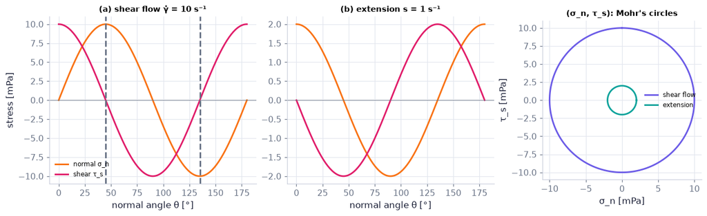

```python
th = np.linspace(0, np.pi, 181)                                      # angle of the plane's normal from x [rad]
sh = np.array([ch04.stress_on_plane(G_sh, 0.0, 1e-3, 0.0, t) for t in th])    # shear flow γ̇ = 10 1/s: (σ_n, τ_s) [Pa]
ex = np.array([ch04.stress_on_plane(G_ext, 0.0, 1e-3, 0.0, t) for t in th])   # extension s = 1 1/s
fig, (a, b, c) = plt.subplots(1, 3, figsize=(12, 3.6), gridspec_kw=dict(width_ratios=[1.3, 1.3, 1]))  # the figure and its panels
for ax, dat, lab in ((a, sh, "(a) shear flow γ̇ = 10 s⁻¹"), (b, ex, "(b) extension s = 1 s⁻¹")):  # the two flows, one panel each
    ax.plot(np.rad2deg(th), dat[:, 0]*1e3, color=COLORS["orange"], lw=2, label="normal σ_n")   # normal part [mPa]
    ax.plot(np.rad2deg(th), dat[:, 1]*1e3, color=COLORS["rose"], lw=2, label="shear τ_s")      # signed shear part [mPa]
    ax.axhline(0, color=COLORS["muted"], lw=0.6); ax.set_xlabel("normal angle θ [°]"); ax.set_title(lab, fontsize=10)  # axis labels with units
for v in (45, 135):  # the principal directions of the shear flow
    a.axvline(v, ls="--", color=COLORS["muted"])                     # principal directions of the shear flow
a.set_ylabel("stress [mPa]"); a.legend(fontsize=8)                                        # axis labels with units
c.plot(sh[:, 0]*1e3, sh[:, 1]*1e3, color=COLORS["accent"], label="shear flow")    # Mohr's circle of each flow
c.plot(ex[:, 0]*1e3, ex[:, 1]*1e3, color=COLORS["teal"], label="extension")                         # draw the data
c.set_aspect("equal"); c.set_xlabel("σ_n [mPa]"); c.set_ylabel("τ_s [mPa]"); c.legend(fontsize=8)   # axis labels with units
c.set_title("(σ_n, τ_s): Mohr's circles", fontsize=10)                                        # the panel's message
savefig(fig, "ch04", "stress_on_planes"); plt.show()                                        # save the PNG to outputs/ch04, then draw
```

**What you see.** Two sinusoids of period 180°, a quarter-period apart; the shear-flow circle is five times the extension-flow circle.

**How to read it.** Shear flow *is* an extension along 45° and a compression along 135°, seen on tilted planes: the shape of the curves is the same, only rotated by 45° — the stress follows the principal axes of S. The parametric curve (σ_n, τ_s) is a circle (Mohr's circle, a picture of how the traction turns with the plane, Ch. 2 §2.11).

**What would change if…** …the fluid spun rigidly on top: G changes (it gains an antisymmetric part), the curves do not — only S matters (R05).

```python
th = np.linspace(0, np.pi, 91)                                       # plane normal angle [rad]
def bulk(mu_v):                                                      # pure expansion e = 1 1/s with bulk viscosity μ_v
    sn = np.array([ch04.stress_on_plane(G_exp, 0.0, 1e-3, mu_v, t)[0] for t in th])   # normal stress on each plane, p = 0 [Pa]
    tau = ch04.newtonian_stress(G_exp, p=0.0, mu=1e-3, mu_v=mu_v)     # the full stress tensor
    return {"normal stress + p [mPa]": (np.rad2deg(th), sn*1e3),                                    # the curves for this slider value
            "p − p̄ [mPa]": (np.rad2deg(th), 0*th - ch04.mean_pressure(tau)*1e3)}                   # another named curve (x, y)
fig = slider_figure(bulk, "μ_v", np.linspace(0, 5e-3, 11), unit="Pa s", xlabel="plane normal angle θ [°]",  # precompute every slider position (works on the web page)
                    ylabel="[mPa]", title="Bulk viscosity acts only on expansion", yrange=(-1, 16))  # labels, title and a fixed range
recolor(fig, {"normal stress + p [mPa]": COLORS["orange"], "p − p̄ [mPa]": COLORS["muted"]}, {"p − p̄ [mPa]": "dash"}).show()  # house colours for each trace, then draw
```

[interactive chart not shown]

**What you see.** Two flat lines that rise together as μ_v grows (they overlap).

**How to read it.** With μ_v = 0 the orange line sits at 0 (p̄ = p, Stokes); raising μ_v lifts it uniformly: every plane feels the same extra pull $\mu_vS_{mm}=\mu_v\times3\ \text{s}^{-1}$ (in Pa), and $p-\bar p=\mu_v\nabla\cdot\mathbf u$ grows with it.

**What would change if…** …the flow switched to shear: μ_v would do nothing ($S_{mm}=0$).

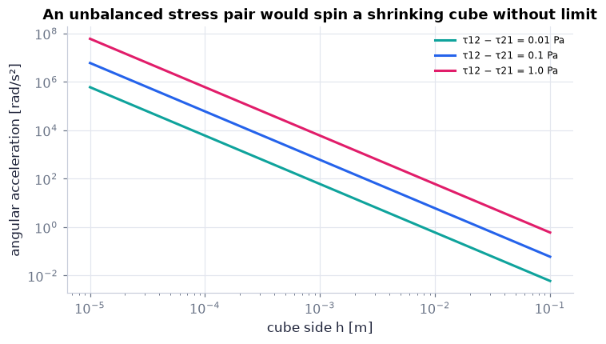

```python
h = np.logspace(-5, -1, 50)                                          # cube side [m]
fig, ax = plt.subplots(figsize=(6.5, 3.8))                                        # the figure and its panels
for dtau, col in ((0.01, COLORS["teal"]), (0.1, COLORS["blue"]), (1.0, COLORS["rose"])):   # stress imbalances [Pa]
    ax.loglog(h, ch04.cube_spin_acceleration(dtau, 0.0, 1000.0, h), color=col, lw=2, label=f"τ12 − τ21 = {dtau} Pa")  # draw the data
ax.set_xlabel("cube side h [m]"); ax.set_ylabel("angular acceleration [rad/s²]"); ax.legend(fontsize=8)  # axis labels with units
ax.set_title("An unbalanced stress pair would spin a shrinking cube without limit")                 # the panel's message
savefig(fig, "ch04", "cube_spin"); plt.show()                                        # save the PNG to outputs/ch04, then draw
```

**What you see.** Straight lines of slope −2 climbing to absurd values as h shrinks.

**How to read it.** A stress imbalance at a point would spin the fluid there infinitely fast — impossible, so $\tau_{ij}=\tau_{ji}$ *(4.25)*.

**What would change if…** …body couples present: a couple (torque) per unit *mass* times the cube's mass ρh³ scales like h³, like (τ₁₂ − τ₂₁)h³, and could balance the imbalance at every size (D08 step 8) — then τ need not be symmetric.

#### 🎮 Interactive: How does a fluid decide its stress?

**Why interactive rather than a static figure:** the stress law is a chain G → S → τ with nine numbers at each link; turning the plane and the presets yourself shows at once which entries of τ respond to which motion, something no single static figure can hold.

Set a velocity gradient with presets (shear, extension, rotation, expansion) or sliders and watch the chain G → S (and R) → τ of $\tau_{ij}=-p\delta_{ij}+2\mu S_{ij}+\lambda S_{mm}\delta_{ij}$ (4.31) respond together: the element deforms, the traction on a plane you rotate swings through its normal and shear values, and the matrices light up by source. A second mode shrinks the spinning cube of D08.

**What to try:**

- Preset 'pure rotation': G is not zero but every stress entry is — only S matters.
- Preset 'expansion' and raise μ_v: p̄ separates from p; switch to 'shear' and μ_v does nothing.
- Rotate the plane in shear flow until the shear readout is zero: that is 45°, a principal direction.
- Open the Derivation tab at D09 and watch the δ-substitution steps light the matrix entries they produce.

```python
show_viz("ch04", "newtonian_stress_lab")   # full-width explainer; ⤢ Full screen for more room
```

🎮 Interactive 3/9 How does a fluid decide its stress? Open alone ↗

[interactive chart not shown]

**What would change if…** …we put (4.37), $\tau_{ij}=-p\,\delta_{ij}+2\mu\big(S_{ij}-\tfrac13S_{mm}\delta_{ij}\big)+\mu_vS_{mm}\delta_{ij}$ into Cauchy's equation $\rho\frac{Du_j}{Dt}=\rho g_j+\frac{\partial\tau_{ij}}{\partial x_i}$ *(4.24)*? The divergence of 2μS becomes μ∇²u plus a term in ∇(∇·u), and we get the Navier–Stokes equation — 4 equations for 5 unknowns (C08).

## 4.6 Navier–Stokes Momentum Equation

**What is this section about?** Substitute the Newtonian stress into Cauchy's equation: the Navier–Stokes equation. With constant viscosity and ∇·u = 0 it takes its famous compact form; its viscous force can be written three ways, and with the viscosity switched off it is Euler's equation.

### 🧩 The Navier–Stokes equation: five accelerations in balance (4.39b) `C08`

*The question:* Honey oozing down a pipe and air racing over a wing obey the same equation. Which of its terms matter where?

*In one line:* $\rho\frac{D\mathbf u}{Dt}=-\nabla p+\rho\mathbf g+\mu\nabla^2\mathbf u$ *(4.39b)*

#### The problem in plain words

Weather models, ocean models, aircraft design codes and blood-flow simulations all solve one equation. Every exact solution of Ch. 8, every boundary layer of Ch. 9 and every instability of Ch. 11 is a flow in which some of its terms balance and the others are asleep. Learning to read the terms — which is big, which is zero, and why — is the skill this block builds.

#### The idea

```
ρ ( ∂u/∂t  +  (u·∇)u )  =  −∇p    +   ρg     +   μ∇²u                        (4.39b)
    local    advective     pressure   gravity    viscous
    blue     teal          orange     grey       rose
Poiseuille: orange ↔ rose     Stokes' first problem: blue ↔ rose     potential flow: teal ↔ orange (rose = 0)
```

*The numbered equations in the sketch:* $\rho\frac{D\mathbf u}{Dt}=-\nabla p+\rho\mathbf g+\mu\nabla^2\mathbf u$ *(4.39b)*

The three example flows are worked below: plane Poiseuille flow (a channel driven by a pressure gradient), Stokes' first problem (a plate set suddenly in motion under still fluid) and the potential flow round a cylinder (Ch. 3).

#### 🧮 Derivation — The Navier–Stokes equation: (4.24) + (4.37) → (4.38) `D11` (Eq. 4.38)

**What we want to show.** Put the Newtonian stress into Cauchy's equation and get the momentum equation of a Newtonian fluid, keeping a viscosity that may vary from place to place.

**Assumptions.** Newtonian fluid (step 3); μ and μ_v may depend on position through the temperature (step 5).

**The plan.**

1. Write τ with velocity gradients.
2. Differentiate the pressure part.
3. Keep the viscous part under the derivative.
4. Write the acceleration out.

**Tools we use** (each explained before this point): (4.37), $\tau_{ij}=-p\,\delta_{ij}+2\mu\big(S_{ij}-\tfrac13S_{mm}\delta_{ij}\big)+\mu_vS_{mm}\delta_{ij}$ (C07) · strain rate $S_{ij}=\tfrac12\big(\frac{\partial u_i}{\partial x_j}+\frac{\partial u_j}{\partial x_i}\big)$ (3.12), $S_{ij}=\tfrac12\Big(\frac{\partial u_i}{\partial x_j}+\frac{\partial u_j}{\partial x_i}\Big)$ (Ch. 3 §3.4) · δ substitution (gloss) · tensor divergence over the first index (primer in C06) · material derivative (3.5), $\frac{DF}{Dt}=\frac{\partial F}{\partial t}+\mathbf u\cdot\nabla F$.

**We start from**

$$ \text{(4.24):}\ \rho\frac{Du_j}{Dt}=\rho g_j+\frac{\partial\tau_{ij}}{\partial x_i} $$

*In words:* Newton's law for a particle, any continuum.

**Step 1 of 7 — Start from Cauchy's equation.**

$$ \rho\frac{Du_j}{Dt}=\rho g_j+\frac{\partial\tau_{ij}}{\partial x_i} $$

- *Why we can do this:* (4.24), $\rho\frac{Du_j}{Dt}=\rho g_j+\frac{\partial\tau_{ij}}{\partial x_i}$ holds for any continuum; we now know τ for a Newtonian fluid (C07).
- *In words:* Mass × acceleration = weight + net push.

**Step 2 of 7 — Write 2μS with velocity gradients.**

$$ 2\mu S_{ij}=\mu\Big(\frac{\partial u_i}{\partial x_j}+\frac{\partial u_j}{\partial x_i}\Big) $$

- *Why we can do this:* Definition of the strain rate (3.12), $S_{ij}=\tfrac12\Big(\frac{\partial u_i}{\partial x_j}+\frac{\partial u_j}{\partial x_i}\Big)$.
- *In words:* Twice the strain rate is the sum of a gradient and its transpose.

**Step 3 of 7 — Write τ with velocity gradients.**

$$ \tau_{ij}=-p\,\delta_{ij}+\mu\Big(\frac{\partial u_i}{\partial x_j}+\frac{\partial u_j}{\partial x_i}\Big)+\Big(\mu_v-\tfrac23\mu\Big)\frac{\partial u_m}{\partial x_m}\delta_{ij} $$

- *Why we can do this:* (4.37), $\tau_{ij}=-p\,\delta_{ij}+2\mu\big(S_{ij}-\tfrac13S_{mm}\delta_{ij}\big)+\mu_vS_{mm}\delta_{ij}$: 2μ(S − ⅓S_mmδ) + μ_vS_mmδ = 2μS + (μ_v − ⅔μ)S_mmδ, with step 2 and S_mm = ∂u_m/∂x_m.
- *In words:* The Newtonian stress in terms of the velocity field.

**Step 4 of 7 — Differentiate the pressure part.**

$$ \frac{\partial}{\partial x_i}\big(-p\,\delta_{ij}\big)=-\frac{\partial p}{\partial x_j} $$

- *Why we can do this:* δ_ij is constant and picks the term with i = j (δ substitution; the book's "(∂p/∂x_i)δ_ij = ∂p/∂x_j").
- *In words:* Pressure pushes from high to low.

**Step 5 of 7 — Keep μ inside the viscous derivative.**

$$ \frac{\partial\sigma_{ij}}{\partial x_i}=\frac{\partial}{\partial x_i}\Big[\mu\Big(\frac{\partial u_j}{\partial x_i}+\frac{\partial u_i}{\partial x_j}\Big)+\Big(\mu_v-\tfrac23\mu\Big)\frac{\partial u_m}{\partial x_m}\delta_{ij}\Big] $$

- *Why we can do this:* μ depends on temperature (it falls with T in liquids, rises in gases), so it may vary in space; we must not pull it outside the derivative yet.
- *In words:* The net viscous force, exact for variable viscosity.

**Step 6 of 7 — Write the acceleration out.**

$$ \rho\frac{Du_j}{Dt}=\rho\Big(\frac{\partial u_j}{\partial t}+u_i\frac{\partial u_j}{\partial x_i}\Big) $$

- *Why we can do this:* Material derivative (3.5), $\frac{DF}{Dt}=\frac{\partial F}{\partial t}+\mathbf u\cdot\nabla F$ with F = u_j: the local plus the advective rate of the velocity.
- *In words:* Local plus advective acceleration.

**Step 7 of 7 — Assemble the equation.**

$$ \rho\Big(\frac{\partial u_j}{\partial t}+u_i\frac{\partial u_j}{\partial x_i}\Big)=-\frac{\partial p}{\partial x_j}+\rho g_j+\frac{\partial}{\partial x_i}\Big[\mu\Big(\frac{\partial u_j}{\partial x_i}+\frac{\partial u_i}{\partial x_j}\Big)+\Big(\mu_v-\tfrac23\mu\Big)\frac{\partial u_m}{\partial x_m}\delta_{ij}\Big] $$

- *Why we can do this:* Insert steps 4–6 into step 1. This is (4.38), $\rho\frac{Du_j}{Dt}=-\frac{\partial p}{\partial x_j}+\rho g_j+\frac{\partial}{\partial x_i}\Big[\mu\Big(\frac{\partial u_j}{\partial x_i}+\frac{\partial u_i}{\partial x_j}\Big)+\big(\mu_v-\tfrac23\mu\big)\frac{\partial u_m}{\partial x_m}\delta_{ij}\Big]$ — the line above, the Navier–Stokes equation.
- *In words:* Acceleration = pressure + gravity + viscous force.

**Result**

$$ (4.38)\quad \rho\frac{Du_j}{Dt}=-\frac{\partial p}{\partial x_j}+\rho g_j+\frac{\partial}{\partial x_i}\Big[\mu\Big(\frac{\partial u_j}{\partial x_i}+\frac{\partial u_i}{\partial x_j}\Big)+\big(\mu_v-\tfrac23\mu\big)\frac{\partial u_m}{\partial x_m}\delta_{ij}\Big] $$

*In words:* the Navier–Stokes momentum equation for a Newtonian fluid with variable viscosity.

**What it means.** The equation of the rest of the book. The next derivation simplifies it for constant viscosity and incompressible flow.

**Check it.** Units N/m³ ✓. μ = 0 gives Euler (4.41), $\rho\frac{D\mathbf u}{Dt}=-\nabla p+\rho\mathbf g$ ✓. Poiseuille (the plane channel flow worked with numbers later in this block, G = 100 Pa/m): 0 = 100 + 0 − 100 ✓. Ledger: with (4.7), $\frac{\partial\rho}{\partial t}+\nabla\cdot(\rho\mathbf u)=0$, 4 equations for ρ, p, u_j (5 unknowns) — closed by ρ = const or ρ = ρ(p) ✓. sympy: `ch04.navier_stokes_sym` with μ = μ₀(1 + by) keeps a dμ/dy term that vanishes for b = 0 (C08 code).

> ⚠️ **Common confusion (traps in `D11`):** Writing ∂(pδ_ij)/∂x_i as ∂p/∂x_i (the free index is j). Pulling μ out when it varies (hot bearings, magma). Forgetting the transpose term ∂u_i/∂x_j.

📝 **Note.** **Navier–Stokes with variable viscosity** `N52` — (D11's result). **Ledger:** continuity (1) + Navier–Stokes (3) = 4 equations; unknowns ρ, p, u_j = 5. Closed when ρ is constant or a known function of p alone (a *barotropic* flow, met properly in C11): 5 = 5.

$$ \rho\frac{Du_j}{Dt}=-\frac{\partial p}{\partial x_j}+\rho g_j+\frac{\partial}{\partial x_i}\Big[\mu\Big(\frac{\partial u_j}{\partial x_i}+\frac{\partial u_i}{\partial x_j}\Big)+\big(\mu_v-\tfrac23\mu\big)\frac{\partial u_m}{\partial x_m}\delta_{ij}\Big] \qquad \text{(4.38)} $$

```python
for s in ("navier_stokes", "barotropic"):                            # two more rows of the §4.1 ledger
    c = ch04.closure_count(s)                                        # call the tested chapter function
    ledger.loc[s] = [c["equations"], c["unknowns"]]
print(ledger)                                                        # navier_stokes 4/5, barotropic 5/5
```

```
               equations  unknowns
cauchy                 6        13
navier_stokes          4         5
barotropic             5         5
full                   0         0
```

> 📎 **Primer — Schwarz's theorem.** `P121` · For a smooth function the order of partial derivatives does not matter: $\frac{\partial}{\partial x}\frac{\partial f}{\partial y}=\frac{\partial}{\partial y}\frac{\partial f}{\partial x}$. Here it lets us move $\partial/\partial x_j$ outside $\partial u_i/\partial x_i$, turning a term into the gradient of the divergence ∇(∇·u). It needs continuous second derivatives (true for every viscous flow we meet).

```python
x, y = sp.symbols('x y')                                        # two coordinates
f = sp.sin(x*y) + x**3*sp.exp(y)                                # any smooth function
print(sp.simplify(sp.diff(f, x, y) - sp.diff(f, y, x)))         # 0
```

```
0
```

#### 🧮 Derivation — Constant viscosity, then incompressible: (4.38) → (4.39a) → (4.39b) `D12` (Eq. 4.39b)

**What we want to show.** Simplify Navier–Stokes when the viscosities are uniform and the flow is incompressible, and see exactly which term incompressibility removes — the book states the results.

**Assumptions.** μ, μ_v uniform (small temperature differences) from step 1; u twice continuously differentiable (step 3); ∇·u = 0 from step 6.

**The plan.**

1. Take the constant viscosities outside.
2. Swap a derivative order to reveal ∇(∇·u).
3. Collect the coefficients.
4. Set ∇·u = 0.

**Tools we use** (each explained before this point): Schwarz's theorem (primer in C08) · vector Laplacian in Cartesian components (gloss) · (4.10), $\nabla\cdot\mathbf u=0$ (C02).

**We start from**

$$ \begin{array}{l}\text{The viscous term of (4.38):} \\ \frac{\partial}{\partial x_i}\Big[\mu\Big(\frac{\partial u_j}{\partial x_i}+\frac{\partial u_i}{\partial x_j}\Big)+\Big(\mu_v-\tfrac23\mu\Big)\frac{\partial u_m}{\partial x_m}\delta_{ij}\Big]\ \text{.}\end{array} $$

**Step 1 of 7 — Take the viscosities outside.**

$$ \frac{\partial\sigma_{ij}}{\partial x_i}=\mu\frac{\partial}{\partial x_i}\Big(\frac{\partial u_j}{\partial x_i}+\frac{\partial u_i}{\partial x_j}\Big)+\Big(\mu_v-\tfrac23\mu\Big)\frac{\partial}{\partial x_j}\frac{\partial u_m}{\partial x_m} $$

- *Why we can do this:* Uniform μ, μ_v are constants for the derivative; δ_ij turns ∂/∂x_i into ∂/∂x_j in the last term.
- *In words:* Two viscous pieces remain.

**Step 2 of 7 — Split the first bracket.**

$$ \mu\frac{\partial^2u_j}{\partial x_i\partial x_i}+\mu\frac{\partial}{\partial x_i}\frac{\partial u_i}{\partial x_j} $$

- *Why we can do this:* Linearity of the derivative: the bracket's two terms are differentiated separately.
- *In words:* A Laplacian and a mixed term.

**Step 3 of 7 — Swap the derivative order.**

$$ \frac{\partial}{\partial x_i}\frac{\partial u_i}{\partial x_j}=\frac{\partial}{\partial x_j}\frac{\partial u_i}{\partial x_i}=\frac{\partial}{\partial x_j}(\nabla\cdot\mathbf u) $$

- *Why we can do this:* Schwarz's theorem (primer): mixed partial derivatives of a smooth field commute. The sum over i is then the divergence.
- *In words:* The mixed term is the gradient of the divergence.

**Step 4 of 7 — Collect the ∇(∇·u) coefficients.**

$$ \Big(\mu+\mu_v-\tfrac23\mu\Big)\frac{\partial}{\partial x_j}\frac{\partial u_m}{\partial x_m}=\Big(\mu_v+\tfrac13\mu\Big)\frac{\partial}{\partial x_j}\frac{\partial u_m}{\partial x_m} $$

- *Why we can do this:* The book skips this bookkeeping: μ from step 3 plus μ_v − ⅔μ from step 1 (renaming the dummy index i as m).
- *In words:* One coefficient in front of the gradient of the divergence.

**Step 5 of 7 — Write the constant-viscosity form.**

$$ \rho\frac{Du_j}{Dt}=-\frac{\partial p}{\partial x_j}+\rho g_j+\mu\frac{\partial^2u_j}{\partial x_i^2}+\Big(\mu_v+\tfrac13\mu\Big)\frac{\partial}{\partial x_j}\frac{\partial u_m}{\partial x_m} $$

- *Why we can do this:* Put steps 2–4 into (4.38), $\rho\frac{Du_j}{Dt}=-\frac{\partial p}{\partial x_j}+\rho g_j+\frac{\partial}{\partial x_i}\Big[\mu\Big(\frac{\partial u_j}{\partial x_i}+\frac{\partial u_i}{\partial x_j}\Big)+\big(\mu_v-\tfrac23\mu\big)\frac{\partial u_m}{\partial x_m}\delta_{ij}\Big]$; ∂²u_j/∂x_i∂x_i is the Laplacian of component j (vector Laplacian, gloss). This is (4.39a), $\rho\frac{Du_j}{Dt}=-\frac{\partial p}{\partial x_j}+\rho g_j+\mu\frac{\partial^2u_j}{\partial x_i^2}+\big(\mu_v+\tfrac13\mu\big)\frac{\partial}{\partial x_j}\frac{\partial u_m}{\partial x_m}$ — the line above.
- *In words:* Viscous diffusion plus a compressibility term.

**Step 6 of 7 — Impose incompressibility.**

$$ \frac{\partial u_m}{\partial x_m}=\nabla\cdot\mathbf u=0 $$

- *Why we can do this:* (4.10), $\nabla\cdot\mathbf u=0$ for incompressible flow removes the last term entirely.
- *In words:* The compressibility term vanishes.

**Step 7 of 7 — Write it in vector form.**

$$ \rho\frac{D\mathbf u}{Dt}=-\nabla p+\rho\mathbf g+\mu\nabla^2\mathbf u $$

- *Why we can do this:* The three components together; ∇²u acts on each Cartesian component. This is (4.39b), $\rho\frac{D\mathbf u}{Dt}=-\nabla p+\rho\mathbf g+\mu\nabla^2\mathbf u$ — the line above.
- *In words:* The incompressible Navier–Stokes equation.

**Result**

$$ \text{(4.39a), and}\ \rho\frac{D\mathbf u}{Dt}=-\nabla p+\rho\mathbf g+\mu\nabla^2\mathbf u $$

*In words:* with uniform viscosity and no volume change, the viscous force is μ times the Laplacian of the velocity.

**What it means.** Viscosity acts as diffusion of momentum (ν∇²u after dividing by ρ). The compressibility term matters only for sound and shocks.

**Check it.** Units ✓. Poiseuille satisfies (4.39b), $\rho\frac{D\mathbf u}{Dt}=-\nabla p+\rho\mathbf g+\mu\nabla^2\mathbf u$ exactly ✓. sympy (C08): for u = (y(1 − y), 0, 0) the ∇(∇·u) term is 0 ✓. The toy field u = (ax², 0, 0) has ∇·u = 2ax and a nonzero (μ_v + ⅓μ)·2a term (both computed in the sympy cell right after this derivation) ✓.

> ⚠️ **Common confusion (traps in `D12`):** Coefficient bookkeeping (μ + μ_v − ⅔μ = μ_v + ⅓μ, not μ_v − ⅓μ). Pulling out μ when it varies. Using Cartesian "∇² of each component" in cylindrical coordinates (extra terms, Appendix B).

```python
x, y, z, a, mu, mu_v = sp.symbols('x y z a mu mu_v')                  # coordinates, a toy constant, the two viscosities
X = (x, y, z)
for name, u in {"Poiseuille-like u = (y(1 − y), 0, 0)": [y*(1 - y), 0, 0], "toy u = (a x², 0, 0)": [a*x**2, 0, 0]}.items():
    div = sum(sp.diff(u[m], X[m]) for m in range(3))                 # ∇·u = ∂u_m/∂x_m
    extra = [sp.simplify((mu_v + mu/3)*sp.diff(div, X[j])) for j in range(3)]   # the compressible term of (4.39a)
    print(f"{name}:  ∇·u = {div},  (μ_v + μ/3) ∂(∇·u)/∂x_j = {extra}")   # 0 for the first, (2a(μ_v + μ/3), 0, 0) for the toy
```

```
Poiseuille-like u = (y(1 − y), 0, 0):  ∇·u = 0,  (μ_v + μ/3) ∂(∇·u)/∂x_j = [0, 0, 0]
toy u = (a x², 0, 0):  ∇·u = 2*a*x,  (μ_v + μ/3) ∂(∇·u)/∂x_j = [2*a*(mu + 3*mu_v)/3, 0, 0]
```

**What does the code above do?**

The last term of the constant-viscosity form (4.39a), $\rho\frac{Du_j}{Dt}=-\frac{\partial p}{\partial x_j}+\rho g_j+\mu\frac{\partial^2u_j}{\partial x_i^2}+\big(\mu_v+\tfrac13\mu\big)\frac{\partial}{\partial x_j}\frac{\partial u_m}{\partial x_m}$ for two fields: it vanishes for the divergence-free Poiseuille-like profile, and for the toy field $\mathbf u=(ax^2,0,0)$ (∇·u = 2ax) it is $2a(\mu_v+\tfrac13\mu)$ along x — the D12 check.

📝 **Note.** **The constant-viscosity compressible form** `N53` — D12's middle line. Its last term is the only trace of compressibility; ∇·u = 0 removes it and leaves (4.39b), $\rho\frac{D\mathbf u}{Dt}=-\nabla p+\rho\mathbf g+\mu\nabla^2\mathbf u$.

$$ \rho\frac{Du_j}{Dt}=-\frac{\partial p}{\partial x_j}+\rho g_j+\mu\frac{\partial^2u_j}{\partial x_i^2}+\big(\mu_v+\tfrac13\mu\big)\frac{\partial}{\partial x_j}\frac{\partial u_m}{\partial x_m} \qquad \text{(4.39a)} $$

> 📎 **Primer — curl of a curl identity.** `P122` · For any smooth vector field, $\nabla\times(\nabla\times\mathbf u)=\nabla(\nabla\cdot\mathbf u)-\nabla^2\mathbf u$. It follows from the ε–δ identity $\varepsilon_{ijk}\varepsilon_{klm}=\delta_{il}\delta_{jm}-\delta_{im}\delta_{jl}$ *(2.19)* of Ch. 2. With ω = ∇×u and ∇·u = 0 it says $\nabla^2\mathbf u=-\nabla\times\boldsymbol\omega$: the Laplacian of an incompressible velocity is minus the curl of its vorticity.

```python
x, y, z = sp.symbols('x y z'); X = sp.Matrix([x, y, z])          # coordinates
u = sp.Matrix([y**2*z, sp.sin(x)*z, x*y**3])                      # any smooth field
curl = lambda F: sp.Matrix([sp.diff(F[2], y) - sp.diff(F[1], z), sp.diff(F[0], z) - sp.diff(F[2], x), sp.diff(F[1], x) - sp.diff(F[0], y)])
div = sum(sp.diff(u[i], X[i]) for i in range(3))                  # ∇·u
lap = sp.Matrix([sum(sp.diff(u[k], v, 2) for v in X) for k in range(3)])   # ∇²u component by component
print(sp.simplify(curl(curl(u)) - (sp.Matrix([sp.diff(div, v) for v in X]) - lap)))   # zero vector
```

```
Matrix([[0], [0], [0]])
```

#### 🧮 Derivation — The viscous force three ways, (4.40) `D13` (Eq. 4.40)

**What we want to show.** Show $\mu\nabla^2\mathbf u=2\mu\,\partial S_{ij}/\partial x_i=-\mu\nabla\times\boldsymbol\omega$ for incompressible flow, and resolve the "paradox" that vorticity appears though rotation was excluded from the stress law. The book leaves it to Exercise 4.38.

**Assumptions.** Incompressible, ∇·u = 0 (steps 3, 8); u smooth (steps 3, 8).

**The plan.**

1. Show the strain-rate form equals it when ∇·u = 0.
2. Write ∇×ω with ε's, use the ε–δ identity, and compare.
3. Test on solid-body rotation.

**Tools we use** (each explained before this point): Strain rate (3.12) · Schwarz's theorem (primer in C08) · vorticity ω = ∇×u (Ch. 3 §3.4) · ε–δ identity $\varepsilon_{kij}\varepsilon_{klm}=\delta_{il}\delta_{jm}-\delta_{im}\delta_{jl}$ (2.19), $\varepsilon_{ijk}\varepsilon_{klm}=\delta_{il}\delta_{jm}-\delta_{im}\delta_{jl}$ and the curl-of-a-curl identity (primer in C08).

**We start from**

$$ (\mu\nabla^2\mathbf u)_j=\mu\frac{\partial^2u_j}{\partial x_i\partial x_i} $$

*In words:* the viscous force of (4.39b), $\rho\frac{D\mathbf u}{Dt}=-\nabla p+\rho\mathbf g+\mu\nabla^2\mathbf u$, component j.

**Step 1 of 9 — Start from the Laplacian form.**

$$ (\mu\nabla^2\mathbf u)_j=\mu\frac{\partial^2u_j}{\partial x_i\partial x_i} $$

- *Why we can do this:* The viscous term of (4.39b), $\rho\frac{D\mathbf u}{Dt}=-\nabla p+\rho\mathbf g+\mu\nabla^2\mathbf u$; we compare it with two other expressions.
- *In words:* Viscous force = μ × curvature of the velocity profile.

**Step 2 of 9 — Differentiate twice the strain rate.**

$$ 2\frac{\partial S_{ij}}{\partial x_i}=\frac{\partial^2u_i}{\partial x_i\partial x_j}+\frac{\partial^2u_j}{\partial x_i\partial x_i} $$

- *Why we can do this:* 2S_ij = ∂u_i/∂x_j + ∂u_j/∂x_i (3.12), $S_{ij}=\tfrac12\Big(\frac{\partial u_i}{\partial x_j}+\frac{\partial u_j}{\partial x_i}\Big)$; differentiate each term by x_i and sum over i.
- *In words:* The divergence of the strain rate has two parts.

**Step 3 of 9 — Swap and use ∇·u = 0.**

$$ 2\frac{\partial S_{ij}}{\partial x_i}=\frac{\partial}{\partial x_j}(\nabla\cdot\mathbf u)+\nabla^2u_j=\nabla^2u_j $$

- *Why we can do this:* Schwarz's theorem moves ∂/∂x_j outside; the divergence is zero for incompressible flow. So μ∇²u = 2μ∂S_ij/∂x_i (also the book's μ∂/∂x_i(∂u_j/∂x_i + ∂u_i/∂x_j) form).
- *In words:* The first two forms agree.

**Step 4 of 9 — Write the vorticity with ε.**

$$ \omega_k=\varepsilon_{klm}\frac{\partial u_m}{\partial x_l} $$

- *Why we can do this:* ω = ∇×u (Ch. 3), the curl written with the alternating tensor (Ch. 2 §2.7).
- *In words:* Vorticity in index form.

**Step 5 of 9 — Write the curl of the vorticity.**

$$ (\nabla\times\boldsymbol\omega)_j=\varepsilon_{jik}\frac{\partial\omega_k}{\partial x_i}=\varepsilon_{jik}\varepsilon_{klm}\frac{\partial^2u_m}{\partial x_i\partial x_l} $$

- *Why we can do this:* The curl of any vector is ε_jik∂_i(·)_k; insert step 4.
- *In words:* A double sum of second derivatives.

**Step 6 of 9 — Apply the ε–δ identity.**

$$ \varepsilon_{jik}\varepsilon_{klm}=\delta_{jl}\delta_{im}-\delta_{jm}\delta_{il} $$

- *Why we can do this:* Cyclic shift ε_jik = ε_kji, then (2.19), $\varepsilon_{ijk}\varepsilon_{klm}=\delta_{il}\delta_{jm}-\delta_{im}\delta_{jl}$ with the first indices matched.
- *In words:* Two ε's become two pairs of δ's.

**Step 7 of 9 — Substitute the δ's.**

$$ (\nabla\times\boldsymbol\omega)_j=\frac{\partial^2u_i}{\partial x_i\partial x_j}-\frac{\partial^2u_j}{\partial x_i\partial x_i} $$

- *Why we can do this:* δ_jlδ_im sets l = j, m = i; δ_jmδ_il sets m = j, l = i (δ substitution).
- *In words:* The curl of ω is the gradient of the divergence minus the Laplacian.

**Step 8 of 9 — Use ∇·u = 0 again.**

$$ (\nabla\times\boldsymbol\omega)_j=-\nabla^2u_j\ \Rightarrow\ \mu\nabla^2\mathbf u=-\mu\nabla\times\boldsymbol\omega $$

- *Why we can do this:* The first term is ∂_j(∇·u) = 0 (Schwarz, incompressible). This is the last equality of (4.40), $\mu\nabla^2\mathbf u=2\mu\frac{\partial S_{ij}}{\partial x_i}=-\mu\nabla\times\boldsymbol\omega$.
- *In words:* The viscous force is minus μ times the curl of the vorticity.

**Step 9 of 9 — Test solid-body rotation.**

$$ \mathbf u=\boldsymbol\Omega\times\mathbf x:\quad\boldsymbol\omega=2\boldsymbol\Omega\ \text{uniform}\ \Rightarrow\ \mu\nabla^2\mathbf u=-\mu\nabla\times\boldsymbol\omega=0 $$

- *Why we can do this:* A rigid rotation has uniform vorticity (Ch. 3), whose curl is zero; its strain rate is zero too. The viscous force depends on the *derivative* of ω — the paradox dissolves.
- *In words:* A rigidly spinning fluid feels no friction.

**Result**

$$ (\mu\nabla^2\mathbf u)_j=2\mu\frac{\partial S_{ij}}{\partial x_i}=-\mu(\nabla\times\boldsymbol\omega)_j\ \text{(4.40), for ∇·u = 0} $$

*In words:* the same viscous force from the Laplacian, the strain-rate gradient or the vorticity's curl.

**What it means.** Viscosity acts only where vorticity varies in space — it diffuses vorticity (Ch. 5) and is idle in irrotational flow, which is why potential flow (Ch. 6) is an exact Navier–Stokes solution away from walls.

**Check it.** Units N/m³ ✓. Lamb–Oseen vortex: the three forms agree to stencil accuracy (`viscous_force_forms`; the viscous-paradox figure cell of this block asserts it) ✓. Irrotational flow: ω = 0 ⇒ no viscous force (C12's N98) ✓. Poiseuille: ω = −du/dy e_z, −μ(∇×ω)_x = μu″ = −G ✓.

> ⚠️ **Common confusion (traps in `D13`):** Using the identity when ∇·u ≠ 0 (the ∇(∇·u) term then stays). Index order in ε_jik (a swap flips the sign). Concluding "no vorticity, no viscous stress" (stress is not force: Couette flow has stress but no net viscous force).

📝 **Note.** **The viscous force three ways (incompressible flow)** `N54` — **The paradox resolved:** the viscous force contains vorticity although rotation was excluded from the stress law — but it contains its *derivative*. Solid-body rotation has uniform ω, so ∇×ω = 0 and no viscous force; and then S = 0 everywhere too. Viscosity acts only where vorticity (or strain) varies in space — the vorticity diffusion of Ch. 5.

$$ (\mu\nabla^2\mathbf u)_j=\mu\frac{\partial^2u_j}{\partial x_i^2}=2\mu\frac{\partial S_{ij}}{\partial x_i}=\mu\frac{\partial}{\partial x_i}\Big(\frac{\partial u_j}{\partial x_i}+\frac{\partial u_i}{\partial x_j}\Big)=-\mu\varepsilon_{jik}\frac{\partial\omega_k}{\partial x_i}=-\mu(\nabla\times\boldsymbol\omega)_j \qquad \text{(4.40)} $$

📝 **Note.** **Euler's equation** `N55` — viscosity negligible (far from walls). Check below: the Ch. 3 cylinder potential flow with its Bernoulli pressure satisfies it to round-off (and its viscous term is exactly zero anyway, C12).

$$ \rho\frac{D\mathbf u}{Dt}=-\nabla p+\rho\mathbf g \qquad \text{(4.41)} $$

> 📎 **Primer — complementary error function erfc.** `P123` · $\operatorname{erfc}(\eta)=1-\operatorname{erf}(\eta)=\frac{2}{\sqrt\pi}\int_\eta^\infty e^{-s^2}ds$ falls smoothly from 1 at η = 0 to 0 as η grows (0.48 at η = 0.5, 0.16 at 1, 0.005 at 2). It is the shape of a quantity diffusing into a region from a boundary held at a fixed value: here momentum diffusing up from a plate set suddenly in motion. `scipy.special.erfc` evaluates it.

```python
from scipy.special import erfc                   # the complementary error function
print(erfc(np.array([0.0, 0.5, 1.0, 2.0])))      # [1. 0.4795 0.1573 0.0047]
```

```
[1.     0.4795 0.1573 0.0047]
```